# MSDS696_Practicum2_1b_AssessorsData_Collection_EDA_Cleaning_BemissKimberly

## MSDS696 Data Science Practicum II

### Clustering and Linear Regression with Real Estate Data

### Part 1b - Douglas County Assessors Data

The data I am using for this project comes from the Douglas County Assessors Website.

- https://www.douglas.co.us/assessor/data-downloads/

There are 7 text files of data that contain the available records from the counties assessors database.

### Libraries and Settings

```python
# import the libraries needed

import pandas as pd # library for data analysis and manipulation
import numpy as np # library for working with arrays
import seaborn as sns; sns.set() # data visualization library based on matplotlib used for plot styling
import matplotlib.pyplot as plt # data visualization library
from sklearn.cluster import KMeans # library for k-means clustering
from sklearn.decomposition import PCA # library for principle component analysis
from sklearn.datasets import make_blobs # used to make dataset
from sklearn import metrics # for cluster algorithm evaluation
from sklearn.metrics import silhouette_score, adjusted_rand_score, davies_bouldin_score # score for clustering
from sklearn.metrics import pairwise_distances  # for cluster algorithm evaluation
from sklearn.preprocessing import StandardScaler, MinMaxScaler # scale data
from sklearn.preprocessing import LabelEncoder # encode data
from sklearn.pipeline import Pipeline # Create a pipline
from sklearn.linear_model import LassoCV # Feature Selection
from scipy.cluster.hierarchy import dendrogram, linkage # for Hierarchical Clustering
from kneed import KneeLocator # used for clustering to find optimal # of clusters
import requests
import json
import urllib
#import geopandas # geocode location
#import geopy # geocode location
from sklearn.impute import KNNImputer # used to impute Nan values
# line magic function, display the plot directly below code that produces it
%matplotlib inline
```

```python
# Set the option in pandas to display up to 150 columns and rows
pd.set_option('display.max_columns', 150)
pd.set_option('display.max_rows', 150)
pd.set_option('display.max_colwidth', None)
```

## Import Assessors data text files to DataFrames

### Property Details (Property_Improvement.txt) - 1

The file Property_Improvement.txt:

[output not shown]

```python
# read the text file into a pandas dataframe - files have no headers
df_PI = pd.read_csv('C:/Users/edkcb/Documents/MSDS696_Practicum2/Data/Property_Improvements.txt', header=None)
```

```python
# Set the names of each of the columns as obtained from the Douglas County Asessors Website
# Note - headers are not included in the text file.
df_PI.columns = ["Account_No","Building_ID","Style","Occupancy_Code","Built_As_code","Built_As","Quality_Code"
                              ,"Property_Type_Code","Improvement_Type_Code","Completion_Percent","Unit_Type","No_of_Fireplace"
                              ,"Total_Garage_SF","Walkout_Basement_Flag","Total_Porch_SF","Total_Finished_Basement_SF"
                              ,"Total_Unfinished_Basement_SF","Roof_Construction_Type","Built_as_SF","Exterior_Construction"
                              ,"Interior_Construction","No_of_Story","Roof_Material_Code","Floor_Material_Type_Code"
                              ,"No_of_Bedrooms","No_of_Bathrooms","Built_Year","Remodeled_Year","Length_of_Mobile_Home"
                              ,"Width_of_Mobile_Home","Average_Story_Height","No_Of_Unit","Sprinkler_Coverage_SF","Condition"
                              ,"HVAC"]
```

```python
# view the shape of the new dataframe (rows, columns)
df_PI.shape
```

```
(133865, 35)
```

```python
# View the first 5 records in the new dataframe
df_PI.head()
```

|  | Account_No | Building_ID | Style | Occupancy_Code | Built_As_code | Built_As | Quality_Code | Property_Type_Code | Improvement_Type_Code | Completion_Percent | Unit_Type | No_of_Fireplace | Total_Garage_SF | Walkout_Basement_Flag | Total_Porch_SF | Total_Finished_Basement_SF | Total_Unfinished_Basement_SF | Roof_Construction_Type | Built_as_SF | Exterior_Construction | Interior_Construction | No_of_Story | Roof_Material_Code | Floor_Material_Type_Code | No_of_Bedrooms | No_of_Bathrooms | Built_Year | Remodeled_Year | Length_of_Mobile_Home | … |
| --- | --- | --- | --- | --- | --- | --- | --- | --- | --- | --- | --- | --- | --- | --- | --- | --- | --- | --- | --- | --- | --- | --- | --- | --- | --- | --- | --- | --- | --- | --- |
| 0 | M0211043 | 1.0 | Mobile Home | 110 | 15 | Double Wide | Average | Mobile Home | 1205 | 100.0 | NaN | 0 | 0 | N | 840 | 0 | 0 | Gable | 1205 | Hardboard Sheet | Drywall | 1.0 | Shingle Comp | Allowance | 2.0 | 2.0 | 1999 | 0.0 | 52.0 | … |
| 1 | M0211051 | 1.0 | Mobile Home | 110 | 14 | Single Wide | Fair | Mobile Home | 924 | 100.0 | NaN | 0 | 0 | N | 0 | 0 | 0 | Gable | 924 | Metal Siding | Paneling | 1.0 | Metal Ribbed | Allowance | 1.0 | 1.0 | 1973 | 0.0 | 66.0 | … |
| 2 | M0211078 | 1.0 | Mobile Home | 110 | 15 | Double Wide | Fair | Mobile Home | 1440 | 100.0 | NaN | 0 | 0 | N | 0 | 0 | 0 | Gable | 1440 | Lap Siding | Paneling | 1.0 | Shingle Comp | Allowance | 1.0 | 1.0 | 1973 | 0.0 | 60.0 | … |
| 3 | M0211086 | 1.0 | Mobile Home | 110 | 14 | Single Wide | Fair | Mobile Home | 840 | 100.0 | NaN | 0 | 0 | N | 0 | 0 | 0 | Gable | 840 | Metal Siding | Paneling | 1.0 | Metal Ribbed | Allowance | 2.0 | 1.0 | 1973 | 0.0 | 60.0 | … |
| 4 | M0211094 | 1.0 | Mobile Home | 110 | 15 | Double Wide | Fair | Mobile Home | 1440 | 100.0 | NaN | 0 | 0 | N | 0 | 0 | 0 | Gable | 1440 | Lap Siding | Paneling | 1.0 | Shingle Comp | Allowance | 1.0 | 1.0 | 1973 | 0.0 | 60.0 | … |

```python
# View the last 5 records in the new dataframe
df_PI.tail()
```

|  | Account_No | Building_ID | Style | Occupancy_Code | Built_As_code | Built_As | Quality_Code | Property_Type_Code | Improvement_Type_Code | Completion_Percent | Unit_Type | No_of_Fireplace | Total_Garage_SF | Walkout_Basement_Flag | Total_Porch_SF | Total_Finished_Basement_SF | Total_Unfinished_Basement_SF | Roof_Construction_Type | Built_as_SF | Exterior_Construction | Interior_Construction | No_of_Story | Roof_Material_Code | Floor_Material_Type_Code | No_of_Bedrooms | No_of_Bathrooms | Built_Year | Remodeled_Year | Length_of_Mobile_Home | … |
| --- | --- | --- | --- | --- | --- | --- | --- | --- | --- | --- | --- | --- | --- | --- | --- | --- | --- | --- | --- | --- | --- | --- | --- | --- | --- | --- | --- | --- | --- | --- |
| 133860 | R0611816 | 1.0 | Equipment Building | 473 | 473 | Equipment Building | Average | Out Building | 3528 | 100.0 | NaN | 0 | 0 | N | 0 | 0 | 0 | Gable | 2952 | NaN | NaN | 1.0 | NaN | NaN | NaN | NaN | 2018 | NaN | 0.0 | … |
| 133861 | R0611841 | 1.0 | Veterinary Hospital | 381 | 381 | Veterinary Hospital | Average | Commercial | 2424 | 100.0 | NaN | 0 | 0 | N | 0 | 1054 | -812 | Gable | 2424 | Frame Masonry Veneer | Drywall | 1.0 | Wood Shake | NaN | 3.0 | 2.0 | 1962 | 2014.0 | 0.0 | … |
| 133862 | R0611841 | 2.0 | Kennel | 228 | 228 | Kennel | Average | Commercial | 9452 | 100.0 | NaN | 0 | 0 | N | 0 | 0 | 0 | Gable | 9452 | NaN | NaN | 1.0 | NaN | NaN | 0.0 | 0.0 | 1962 | 2015.0 | 0.0 | … |
| 133863 | R0611842 | 1.0 | Single Family Residential on Ag | 101 | 8 | 2 Story | Good | Residential | 2206 | 100.0 | NaN | 1 | 812 | Y | 87 | 1671 | 1 | NaN | 2206 | Frame Siding | Drywall | 2.0 | Wood Shake | Allowance | 2.0 | 1.0 | 1986 | 1988.0 | 0.0 | … |
| 133864 | R0612156 | 1.0 | Single Family Residential | 100 | 1 | Ranch 1 Story | Very Good | Residential | 3103 | 100.0 | NaN | 3 | 3347 | Y | 1617 | 2665 | 439 | Hip/Gable | 3103 | Frame Siding | Drywall | 1.0 | Concrete Tile | Allowance | 1.0 | 2.0 | 2019 | NaN | 0.0 | … |

```python
# View the data types of the variables/columns
df_PI.dtypes
```

```
Account_No                       object
Building_ID                     float64
Style                            object
Occupancy_Code                    int64
Built_As_code                     int64
Built_As                         object
Quality_Code                     object
Property_Type_Code               object
Improvement_Type_Code             int64
Completion_Percent              float64
Unit_Type                        object
No_of_Fireplace                   int64
Total_Garage_SF                   int64
Walkout_Basement_Flag            object
Total_Porch_SF                    int64
Total_Finished_Basement_SF        int64
Total_Unfinished_Basement_SF      int64
Roof_Construction_Type           object
Built_as_SF                       int64
Exterior_Construction            object
Interior_Construction            object
No_of_Story                     float64
Roof_Material_Code               object
Floor_Material_Type_Code         object
No_of_Bedrooms                  float64
No_of_Bathrooms                 float64
Built_Year                        int64
Remodeled_Year                  float64
Length_of_Mobile_Home           float64
Width_of_Mobile_Home            float64
Average_Story_Height            float64
No_Of_Unit                      float64
Sprinkler_Coverage_SF           float64
Condition                        object
HVAC                             object
dtype: object
```

```python
# Use Describe to view descriptive statistics on each of the columns.
df_PI.describe(include=['object','float64','int64','datetime64[ns]'])
```

|  | Account_No | Building_ID | Style | Occupancy_Code | Built_As_code | Built_As | Quality_Code | Property_Type_Code | Improvement_Type_Code | Completion_Percent | Unit_Type | No_of_Fireplace | Total_Garage_SF | Walkout_Basement_Flag | Total_Porch_SF | Total_Finished_Basement_SF | Total_Unfinished_Basement_SF | Roof_Construction_Type | Built_as_SF | Exterior_Construction | Interior_Construction | No_of_Story | Roof_Material_Code | Floor_Material_Type_Code | No_of_Bedrooms | No_of_Bathrooms | Built_Year | Remodeled_Year | Length_of_Mobile_Home | … |
| --- | --- | --- | --- | --- | --- | --- | --- | --- | --- | --- | --- | --- | --- | --- | --- | --- | --- | --- | --- | --- | --- | --- | --- | --- | --- | --- | --- | --- | --- | --- |
| count | 133865 | 133865.000000 | 133865 | 133865.000000 | 133865.000000 | 133865 | 133252 | 133865 | 133865.000000 | 133865.000000 | 12517 | 133865.000000 | 133865.000000 | 133865 | 133865.000000 | 133865.000000 | 133865.000000 | 115063 | 133865.000000 | 118398 | 117316 | 133859.000000 | 117630 | 117599 | 130614.000000 | 130612.000000 | 133865.000000 | 112623.000000 | 119541.000000 | … |
| unique | 120301 | NaN | 184 | NaN | NaN | 212 | 7 | 9 | NaN | NaN | 2 | NaN | NaN | 2 | NaN | NaN | NaN | 10 | NaN | 36 | 3 | NaN | 13 | 25 | NaN | NaN | NaN | NaN | NaN | … |
| top | R0439093 | NaN | Single Family Residential | NaN | NaN | 2 Story | Average | Residential | NaN | NaN | End | NaN | NaN | N | NaN | NaN | NaN | Gable | NaN | Frame Siding | Drywall | NaN | Composition Shingle | Allowance | NaN | NaN | NaN | NaN | NaN | … |
| freq | 56 | NaN | 102693 | NaN | NaN | 68270 | 87005 | 104743 | NaN | NaN | 8133 | NaN | NaN | 104993 | NaN | NaN | NaN | 80672 | NaN | 99797 | 117043 | NaN | 91543 | 113925 | NaN | NaN | NaN | NaN | NaN | … |
| mean | NaN | 1.337362 | NaN | 136.502402 | 60.055571 | NaN | NaN | NaN | 2987.199485 | 99.593023 | NaN | 0.842954 | 514.715773 | NaN | 372.923266 | 434.195817 | 553.372913 | NaN | 2840.394427 | NaN | NaN | 1.596322 | NaN | NaN | 2.964139 | 2.705006 | 1998.470272 | 152.222814 | 0.358622 | … |
| std | NaN | 2.038203 | NaN | 106.837091 | 152.132796 | NaN | NaN | NaN | 9815.675168 | 5.719812 | NaN | 0.609869 | 658.503891 | NaN | 459.398409 | 768.317881 | 944.845753 | NaN | 8412.951004 | NaN | NaN | 0.622176 | NaN | NaN | 3.519063 | 2.996276 | 14.481668 | 531.076158 | 4.905019 | … |
| min | NaN | 1.000000 | NaN | 26.000000 | 0.000000 | NaN | NaN | NaN | 0.000000 | 0.000000 | NaN | 0.000000 | 0.000000 | NaN | 0.000000 | 0.000000 | -38541.000000 | NaN | 0.000000 | NaN | NaN | 0.000000 | NaN | NaN | 0.000000 | 0.000000 | 1825.000000 | 0.000000 | 0.000000 | … |
| 25% | NaN | 1.000000 | NaN | 100.000000 | 7.000000 | NaN | NaN | NaN | 1619.000000 | 100.000000 | NaN | 0.000000 | 400.000000 | NaN | 102.000000 | 0.000000 | 0.000000 | NaN | 1583.000000 | NaN | NaN | 1.000000 | NaN | NaN | 2.000000 | 2.000000 | 1993.000000 | 0.000000 | 0.000000 | … |
| 50% | NaN | 1.000000 | NaN | 100.000000 | 8.000000 | NaN | NaN | NaN | 2160.000000 | 100.000000 | NaN | 1.000000 | 484.000000 | NaN | 265.000000 | 0.000000 | 299.000000 | NaN | 2135.000000 | NaN | NaN | 2.000000 | NaN | NaN | 3.000000 | 3.000000 | 2000.000000 | 0.000000 | 0.000000 | … |
| 75% | NaN | 1.000000 | NaN | 100.000000 | 8.000000 | NaN | NaN | NaN | 2815.000000 | 100.000000 | NaN | 1.000000 | 664.000000 | NaN | 484.000000 | 813.000000 | 928.000000 | NaN | 2793.000000 | NaN | NaN | 2.000000 | NaN | NaN | 4.000000 | 3.000000 | 2006.000000 | 0.000000 | 0.000000 | … |
| max | NaN | 58.000000 | NaN | 1473.000000 | 1473.000000 | NaN | NaN | NaN | 716412.000000 | 100.000000 | NaN | 9.000000 | 142824.000000 | NaN | 16444.000000 | 59317.000000 | 171900.000000 | NaN | 709725.000000 | NaN | NaN | 112.000000 | NaN | NaN | 506.000000 | 414.000000 | 2021.000000 | 2020.000000 | 415.000000 | … |

```python
# Aggregate Volume by Built_Year
df_yr_built = df_PI.groupby(['Built_Year']).size().to_frame('count').reset_index()

# View the beginning of the dataframe
df_yr_built.head()
```

|  | Built_Year | count |
| --- | --- | --- |
| 0 | 1825 | 2 |
| 1 | 1859 | 1 |
| 2 | 1863 | 1 |
| 3 | 1864 | 1 |
| 4 | 1865 | 2 |

```python
# View the end of the dataframe
df_yr_built.tail()
```

|  | Built_Year | count |
| --- | --- | --- |
| 154 | 2017 | 2532 |
| 155 | 2018 | 3437 |
| 156 | 2019 | 3278 |
| 157 | 2020 | 3619 |
| 158 | 2021 | 1 |

```python
# Drop the last record (158) - 2021 is only a partial year (2 months)
df_yr_built.drop([158],axis=0, inplace=True)

# View last 25 records and verify record has been removed.
df_yr_built.tail(25)
```

|  | Built_Year | count |
| --- | --- | --- |
| 133 | 1996 | 5571 |
| 134 | 1997 | 5228 |
| 135 | 1998 | 5246 |
| 136 | 1999 | 6248 |
| 137 | 2000 | 6744 |
| 138 | 2001 | 5135 |
| 139 | 2002 | 4589 |
| 140 | 2003 | 3993 |
| 141 | 2004 | 4576 |
| 142 | 2005 | 5704 |
| 143 | 2006 | 5150 |
| 144 | 2007 | 2841 |
| 145 | 2008 | 1865 |
| 146 | 2009 | 1111 |
| 147 | 2010 | 1119 |
| 148 | 2011 | 1205 |
| 149 | 2012 | 1608 |
| 150 | 2013 | 1943 |
| 151 | 2014 | 2245 |
| 152 | 2015 | 2377 |
| 153 | 2016 | 2460 |
| 154 | 2017 | 2532 |
| 155 | 2018 | 3437 |
| 156 | 2019 | 3278 |
| 157 | 2020 | 3619 |

```python
# Aggregate Volume by Remodeled_Year and drop the first 2 records (non-remodels and weird entry)
df_yr_remod = df_PI.groupby(['Remodeled_Year']).size().to_frame('count').reset_index().drop([0, 1],axis = 0)

# View the first 5 records
df_yr_remod.head()
```

|  | Remodeled_Year | count |
| --- | --- | --- |
| 2 | 1938.0 | 1 |
| 3 | 1940.0 | 11 |
| 4 | 1941.0 | 8 |
| 5 | 1942.0 | 9 |
| 6 | 1943.0 | 8 |

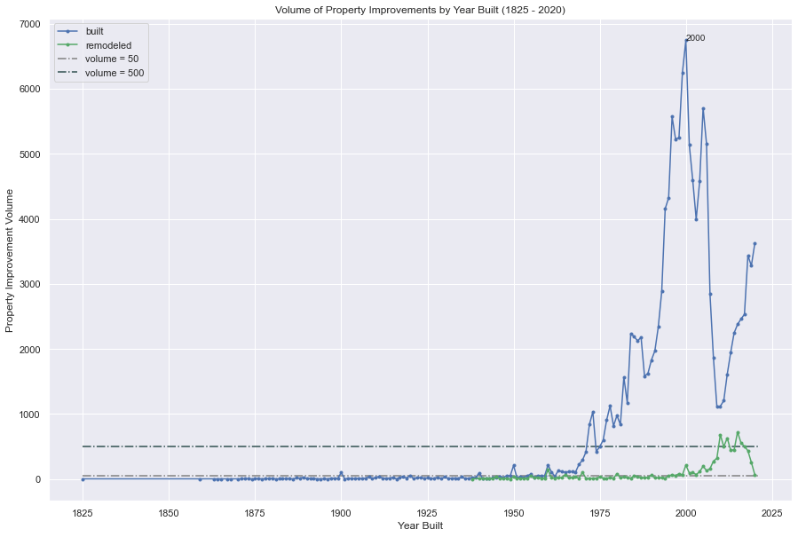

```python
## Plot Volume by Year Built and Remodels

# Set Figure labels and size
plt.figure(figsize=(15,10))
plt.title('Volume of Property Improvements by Year Built (1825 - 2020)')
plt.xlabel('Year Built')
plt.ylabel('Property Improvement Volume')

plt.plot(df_yr_built['Built_Year'], df_yr_built['count'], 'b.-', label = 'built')
plt.plot(df_yr_remod['Remodeled_Year'], df_yr_remod['count'], 'g.-', label = 'remodeled')
plt.hlines(50, xmin=1825,xmax=2021, colors='gray', linestyles='dashdot', label='volume = 50', data=None)
plt.hlines(500, xmin=1825,xmax=2021, colors='darkslategray', linestyles='dashdot', label='volume = 500', data=None)
plt.annotate("2000", (2000,6744))

plt.legend(loc='upper left')

plt.show()
```

###### Duplicate Record and Level of Granularity Review

```
 - Review of duplicates revealed that each row was unique by:
     * Account_No : Unique AlphaNumeric ID for each property
     * Building_ID
     * Style
     * Built_As_Code/Built_As
     * Built_as_SF
     * No_Bedrooms
     * Built_Year
     * No_Of_Unit
```

```python
# Check for any duplicated records in the dataframe
df_PI.duplicated(keep ='first').sum()
```

```
0
```

```python
# Check for any duplicated records in the dataframe - specific columns
df_PI.duplicated(subset=["Account_No"],keep ='first').sum()
```

```
13564
```

```python
# Check for any duplicated records in the dataframe - specific columns
df_PI.duplicated(subset=["Account_No","Building_ID"],keep ='first').sum()
```

```
2636
```

```python
# Check for any duplicated records in the dataframe - specific columns
df_PI.duplicated(subset=["Account_No","Building_ID","Style"],keep ='first').sum()
```

```
2393
```

```python
# Check for any duplicated records in the dataframe - specific columns
df_PI.duplicated(subset=["Account_No","Building_ID","Style","Occupancy_Code"],keep ='first').sum()
```

```
2393
```

```python
# Check for any duplicated records in the dataframe - specific columns
df_PI.duplicated(subset=["Account_No","Building_ID","Style","Occupancy_Code","Built_As_code"],keep ='first').sum()
```

```
105
```

```python
# Check for any duplicated records in the dataframe - specific columns
df_PI.duplicated(subset=["Account_No","Building_ID","Style","Occupancy_Code","Built_As_code","Built_As","Quality_Code"
                          ,"Property_Type_Code","Improvement_Type_Code","Completion_Percent","Unit_Type","No_of_Fireplace"
                          ,"Total_Garage_SF","Walkout_Basement_Flag","Total_Porch_SF","Total_Finished_Basement_SF"
                          ,"Total_Unfinished_Basement_SF","Roof_Construction_Type"],keep ='first').sum()
```

```
79
```

```python
# Check for any duplicated records in the dataframe - specific columns
df_PI.duplicated(subset=["Account_No","Building_ID","Style","Occupancy_Code","Built_As_code","Built_As","Quality_Code"
                          ,"Property_Type_Code","Improvement_Type_Code","Completion_Percent","Unit_Type","No_of_Fireplace"
                          ,"Total_Garage_SF","Walkout_Basement_Flag","Total_Porch_SF","Total_Finished_Basement_SF"
                          ,"Total_Unfinished_Basement_SF","Roof_Construction_Type","Built_as_SF"],keep ='first').sum()
```

```
3
```

```python
# Check for any duplicated records in the dataframe - specific columns
df_PI.duplicated(subset=["Account_No","Building_ID","Style","Occupancy_Code","Built_As_code","Built_As","Quality_Code"
                          ,"Property_Type_Code","Improvement_Type_Code","Completion_Percent","Unit_Type","No_of_Fireplace"
                          ,"Total_Garage_SF","Walkout_Basement_Flag","Total_Porch_SF","Total_Finished_Basement_SF"
                          ,"Total_Unfinished_Basement_SF","Roof_Construction_Type","Built_as_SF","Exterior_Construction"
                          ,"Interior_Construction","No_of_Story","Roof_Material_Code","Floor_Material_Type_Code"
                          ,"No_of_Bedrooms","No_of_Bathrooms"],keep ='first').sum()
```

```
2
```

```python
# Check for any duplicated records in the dataframe - specific columns
df_PI.duplicated(subset=["Account_No","Building_ID","Style","Occupancy_Code","Built_As_code","Built_As","Quality_Code"
                          ,"Property_Type_Code","Improvement_Type_Code","Completion_Percent","Unit_Type","No_of_Fireplace"
                          ,"Total_Garage_SF","Walkout_Basement_Flag","Total_Porch_SF","Total_Finished_Basement_SF"
                          ,"Total_Unfinished_Basement_SF","Roof_Construction_Type","Built_as_SF","Exterior_Construction"
                          ,"Interior_Construction","No_of_Story","Roof_Material_Code","Floor_Material_Type_Code"
                          ,"No_of_Bedrooms","No_of_Bathrooms","Built_Year"],keep ='first').sum()
```

```
1
```

```python
# Check for any duplicated records in the dataframe - specific columns
df_PI.duplicated(subset=["Account_No","Building_ID","Style","Occupancy_Code","Built_As_code","Built_As","Quality_Code"
                          ,"Property_Type_Code","Improvement_Type_Code","Completion_Percent","Unit_Type","No_of_Fireplace"
                          ,"Total_Garage_SF","Walkout_Basement_Flag","Total_Porch_SF","Total_Finished_Basement_SF"
                          ,"Total_Unfinished_Basement_SF","Roof_Construction_Type","Built_as_SF","Exterior_Construction"
                          ,"Interior_Construction","No_of_Story","Roof_Material_Code","Floor_Material_Type_Code"
                          ,"No_of_Bedrooms","No_of_Bathrooms","Built_Year","Remodeled_Year","Length_of_Mobile_Home"
                          ,"Width_of_Mobile_Home","Average_Story_Height","No_Of_Unit"
                        ],keep ='first').sum()
```

```
0
```

```python
# Check for any duplicated records in the dataframe - specific columns
df_PI.duplicated(subset=["Account_No","Building_ID","Style","Occupancy_Code","Built_As_code","Built_As","Quality_Code"
                          ,"Property_Type_Code","Improvement_Type_Code","Completion_Percent","Unit_Type","No_of_Fireplace"
                          ,"Total_Garage_SF","Walkout_Basement_Flag","Total_Porch_SF","Total_Finished_Basement_SF"
                          ,"Total_Unfinished_Basement_SF","Roof_Construction_Type","Built_as_SF","Exterior_Construction"
                          ,"Interior_Construction","No_of_Story","Roof_Material_Code","Floor_Material_Type_Code"
                          ,"No_of_Bedrooms","No_of_Bathrooms","Built_Year","Remodeled_Year","Length_of_Mobile_Home"
                          ,"Width_of_Mobile_Home","Average_Story_Height","No_Of_Unit","Sprinkler_Coverage_SF","Condition"
                          ,"HVAC"],keep ='first').sum()
```

```
0
```

###### View the unique Values in the columns

I want to see what is unique/included in each of the columns that make a record unique, pluse a few others that identify the type of property. I am going to use the pandas .unique() function to view the unqiue values.

```python
# View the unique values for "Building_ID"
df_PI['Building_ID'].unique()
```

```
array([ 1.,  2.,  3.,  4.,  6.,  7.,  8.,  9., 10., 13., 14., 15., 16.,
       17., 20., 21.,  5., 11., 12., 40., 50., 51., 52., 53., 54., 18.,
       19., 22., 23., 24., 25., 26., 27., 28., 29., 30., 31., 32., 33.,
       34., 35., 36., 37., 38., 39., 41., 42., 43., 44., 45., 46., 47.,
       48., 49., 55., 56., 57., 58.])
```

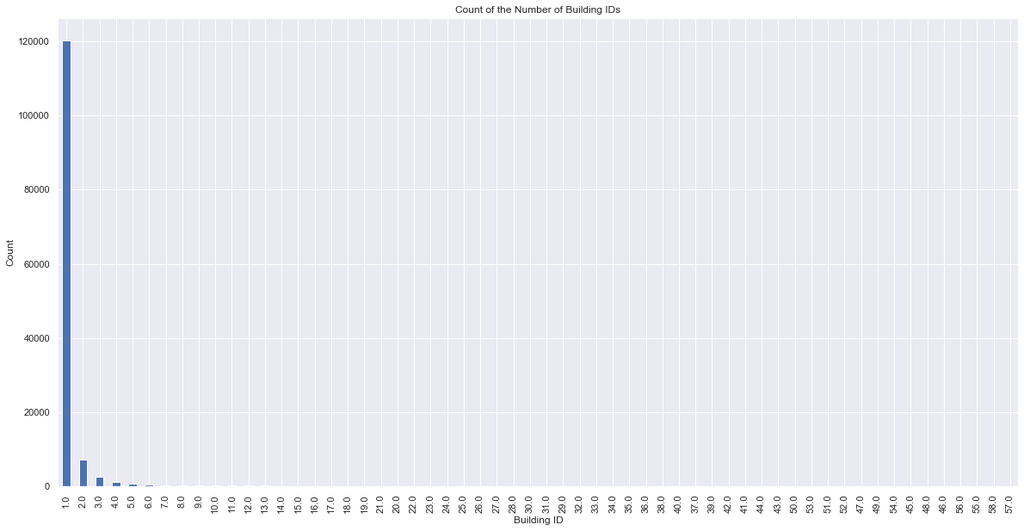

```python
# View visually the content of the column
df_PI['Building_ID'].value_counts().plot(kind='bar', title = "Count of the Number of Building IDs"
                    , xlabel = "Building ID", ylabel = "Count", figsize = (20,10))

plt.show()
```

```python
# View the unique values for "Style" - 184 unique values
df_PI['Style'].unique()
```

```
array(['Mobile Home', 'Single Family Residential',
       'Farm Utility Building (477)', 'Indust Lght Manufacturing',
       'Farm Util  Hay Shed (565)', 'Farm Sun Shelters',
       'Storage Warehouse', 'Horse Arena', 'Stable', 'Shed - Cattle',
       'Farm Implement Equip Shed (478)', 'Farm Implement-Equip Shop',
       'Modular Office', 'Lumber Storage - Horizontal',
       'Equipment Building', 'Barns - Genl Purpose (102)',
       'Office Building', 'Service Garage', 'Light Commercial Utility',
       'Material Shelters', 'Farm Utility Storage - Loafing',
       'Post Office', 'Detached Garage', 'Shed - Poultry',
       'Shed - Equipment', 'Farm Utility Loafing Shed',
       'Single Family Residential on Ag', 'Satelite Service Center',
       'Shed - Tool', 'Shower Building', 'Mini Warehouse',
       'Office-Apartment', 'Restroom Building/Concessions',
       'Country Club', 'Townhouse', 'Greenhouse Shade Shelters',
       'Equipment Storage', 'Site Improvements', 'Storage - Material',
       'Material Storage Sheds', 'Apartment w/4-8 Units',
       'Condominium unit', 'Arch-Rib Quonset Utility', 'Farm Office',
       'Retail Store', 'Church - Sanctuaries (Chapels)',
       'Distribution Warehouse', 'Arch-Rib Quonset Farm Implement',
       'Barns (Two-Story) Genl Purpose', 'Restaurant', 'Creamery',
       'Dairy Milking Parlor', 'Nursery/Greenhouse',
       'Lumber Storage - Vertical', 'Neighborhood Shopping Center',
       'Light Industrial Shell Buildings', 'Guest Houses',
       'School - Gymnasium', 'Kennel', 'Storage - Utility Grain', 'Bank',
       'Quonset', 'Day Care Center', 'Rectory', 'Convenience Store',
       'Bath Houses', 'Apartment w/9 + Units', 'Storage Garage',
       'Industrial Flex Mall Building', 'Motel', 'Triplex',
       'Library - Public', 'Duplex', 'Studio Loft',
       'Fast Food Restaurant', 'Clubhouse', 'Medical Offices',
       'Car Wash - Drive thru', 'Car Wash - Self Service',
       'Barber/Beauty Shop', 'Lodges', 'Visitor Center',
       'Industiral Interior Office Space', 'Automotive Center',
       'Recreational Pool Enclosure', 'Veterinary Hospital',
       'Shed - Sheep', 'Barns (Two-Story) - Special Purpose', 'Lean-tos',
       'Arena Shelters', 'School - Classroom',
       'Dormitory Residence Halls', 'Restaurants - Cafeterias',
       'Guest Cottages', 'Quonset_Comm', 'Carport', 'Government Building',
       'School - Elementary/Secondary', 'Fraternity',
       'Fraternal Building', 'Fire Station - Volunteer',
```

[output cut: 22 more lines]

```
       'Indust Heavy Manufacturing', 'Shell Office Buildings',
       'Neighborhood Shopping Center Shell Buildings',
       'Municipal Service Garages', 'Mega Warehouse', 'Transit Warehouse',
       'Warehouse Showroom Store', 'Veterinary Office',
       'Computer Centers', 'Governmental-Community Service Buildings',
       'Laboratories', 'Farm Utility Lean-Tos (124)', 'Auditorium',
       'Storage Hangar', 'Museum', 'College - Classrooms',
       'Administration Bldg', 'Hotel - Full Service', 'Convention Center',
       'Parking Levels', 'Showroom', 'High School',
       'School - Physical Education', 'School - Fine Arts Building',
       'Hospital', 'Poultry House - Cage', 'Snack Bar', 'Fieldhouse',
       'Theatre - Stage', 'School - Lecture Hall',
       'Regional Shopping Center', 'Surgical Center - Out patient',
       'Arcade', 'Farm Silo Reinforced Conc', 'Indoor Tennis Club'],
      dtype=object)
```

```python
# Group and count the number of accounts by Style
df_PI_StyleCounts = df_PI['Style'].value_counts().to_frame()

df_PI_StyleCounts.head()
```

|  | Style |
| --- | --- |
| Single Family Residential | 102693 |
| Condominium unit | 6868 |
| Townhouse | 5544 |
| Farm Utility Building (477) | 3137 |
| Barns - Genl Purpose (102) | 2862 |

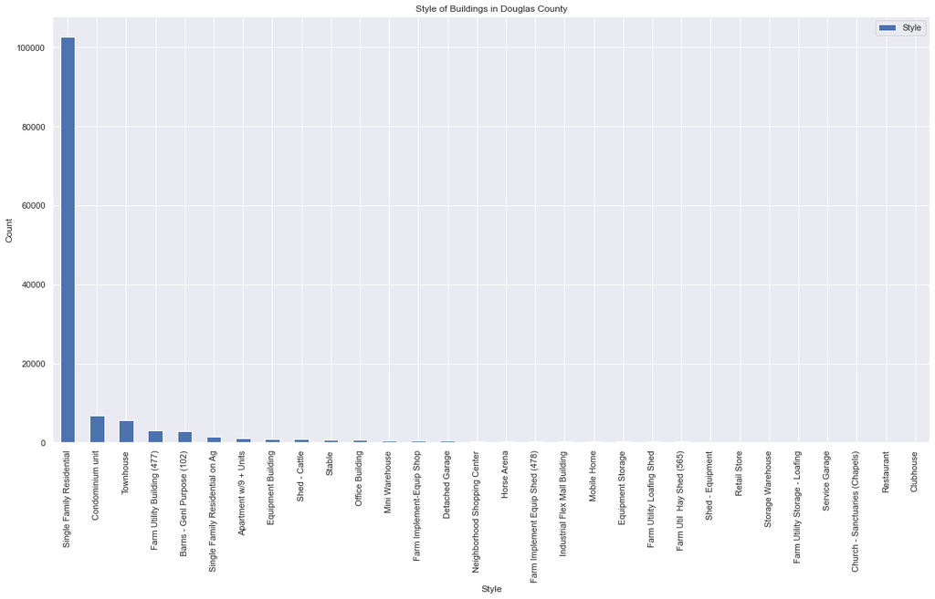

```python
# View visually the numer of accounts by Style
df_PI_StyleCounts[0:30].plot(kind='bar', title = "Style of Buildings in Douglas County",xlabel = "Style"
                    , ylabel = "Count", figsize = (20,10))

plt.show()
```

```python
# View the unique values
df_PI['Built_As'].unique()
```

```
array(['Double Wide', 'Single Wide', 'Ranch 1 Story',
       'Farm Utility Building (477)', 'Indust Lght Manufacturing',
       'Storage Warehouse', '1 1/2 Story Fin',
       'Farm Util  Hay Shed (565)', 'Farm Sun Shelters', 'Horse Arena',
       'Farm Utility Lean-Tos (124)', 'Stable', 'Shed - Cattle',
       'Farm Implement Equip Shed (478)', 'Farm Implement-Equip Shop',
       'Modular Office', 'Lumber Storage - Horizontal', 'Split Level',
       'Equipment Building', '2 Story', 'Modular',
       'Barns - Genl Purpose (102)', 'Hay Loft', 'Office Building',
       'Service Garage', 'Light Commercial Utility',
       'Material Storage Sheds', 'Farm Utility Storage - Loafing',
       'Post Office', 'Bi Level', 'Detached Garage', 'Shed - Poultry',
       'Shed - Equipment', 'Lean-tos', 'Barns (Two-Story) Genl Purpose',
       'Farm Utility Loafing Shed', 'Farm Office',
       'Satelite Service Center', 'Equipment Storage', 'Shed - Tool',
       '3 Story', 'Shower Building', 'Mini Warehouse', 'Office-Apartment',
       'Restroom Building/Concessions', 'Country Club',
       'Townhouse One Story', 'Townhouse Two Story', 'Permit Value',
       'Townhouse Split Level', 'Greenhouse Shade Shelters', 'Dome',
       'Site Improvements', 'Material Shelters', 'Storage - Material',
       'Apartment <= 3 Stories', 'Cabin', 'Condo >= 2 Stories',
       'Arch-Rib Quonset Utility', 'Retail Store', 'Earth Sheltered',
       'Church - Sanctuaries (Chapels)', 'Distribution Warehouse',
       'Arch-Rib Quonset Farm Implement', 'Restaurant', 'Creamery',
       'Dairy Milking Parlor', 'Nursery/Greenhouse',
       'Lumber Storage - Vertical', 'Neighborhood Shopping Center',
       'Light Industrial Shell Buildings', 'Guest Houses',
       'School - Gymnasium', 'Kennel', 'Storage - Utility Grain', 'Bank',
       'Quonset', 'Day Care Center', '1 1/2 Story Unfin',
       'Convenience Store', 'Bath Houses', 'Storage Garage',
       'Industrial Flex Mall Building', 'Motel', 'Triplex One Story',
       'Condo 1 Story', 'Library - Public', 'Duplex One Story',
       'Veterinary Hospital', 'Duplex Two Story',
       'Multiple - Residential', 'Fast Food Restaurant', 'Clubhouse',
       'Medical Offices', 'Car Wash - Drive thru',
       'Car Wash - Self Service', 'Apartment > 3 Stories',
       'Dining Atriums', 'Parking Levels', 'Duplex Split Level',
       'Barber/Beauty Shop', 'Lodges', 'Visitor Center',
       'Industiral Interior Office Space', '2 1/2 Story',
       'Automotive Center', 'Recreational Pool Enclosure', 'A Frame',
```

[output cut: 30 more lines]

```
       'Shell Office Buildings',
       'Neighborhood Shopping Center Shell Buildings',
       'Municipal Service Garages', 'Mega Warehouse', 'Transit Warehouse',
       'Computer Centers', 'Governmental-Community Service Buildings',
       'Telephone Building', 'Laboratories', 'Storage Hangar', 'Museum',
       'College - Classrooms', 'Administration Bldg',
       'Hotel - Full Service', 'Cottage', 'Convention Center',
       'Auditorium', 'Showroom', 'High School',
       'School - Physical Education', 'School - Fine Arts Building',
       'Hospital', 'Radio & TV Stations', 'Poultry House - Cage',
       'Snack Bar', 'Fieldhouse', 'Theatre - Stage',
       'School - Lecture Hall', 'Regional Shopping Center',
       'Surgical Center - Out patient', 'Mechanical Penthouse', 'Arcade',
       'Townhouse >= 2 1/2 Story', 'Boat Storage Sheds',
       'Farm Silo Reinforced Conc', 'Indoor Tennis Club'], dtype=object)
```

```python
# Group and count the number of accounts by Built As

df_PI_BuiltAsCounts = df_PI['Built_As'].value_counts().to_frame()

df_PI_BuiltAsCounts.head()
```

|  | Built_As |
| --- | --- |
| 2 Story | 68270 |
| Ranch 1 Story | 23803 |
| Split Level | 8188 |
| Condo 1 Story | 4336 |
| Townhouse Two Story | 4018 |

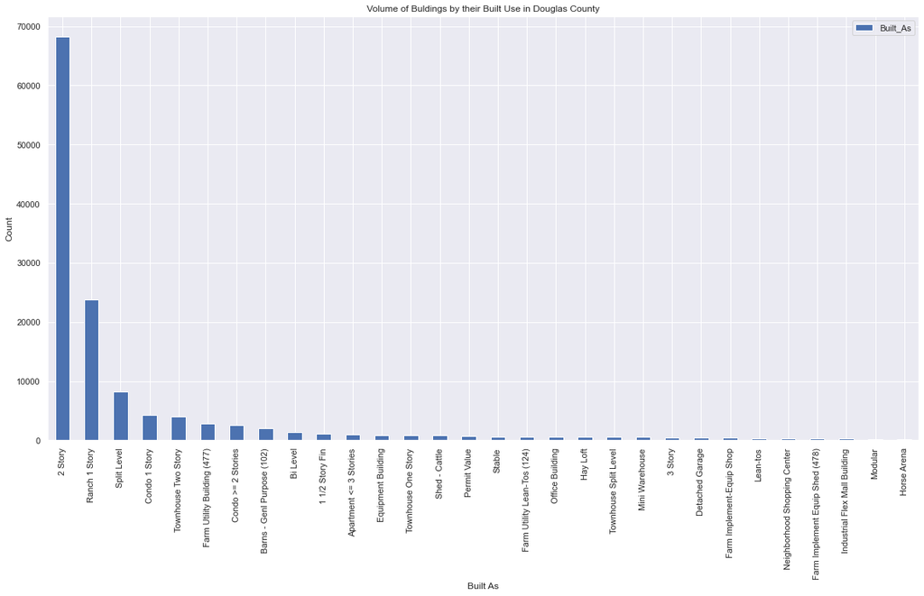

```python
# View visually the numer of accounts by Style

df_PI_BuiltAsCounts[0:30].plot(kind='bar', title = "Volume of Buldings by their Built Use in Douglas County"
                               , xlabel = "Built As", ylabel = "Count", figsize = (20,10))

plt.show()
```

```python
# View the unique values
df_PI['Built_As_code'].unique()
```

```
array([  15,   14,    1,  404,  334,  406,    5,  398,  566,  428, 1124,
        378,  402,  469,  476,  474,  339,    7,  473,    8,   21,  397,
        471,  344,  325, 1471, 1468,  479,  346,    2,   99,  400,  401,
        560, 1100,  478,  468,  475,  389,  421,   25,  403,  386,  544,
        432,  314,   61,   68,    0,   67,  519,   12,  200, 1473,  391,
         17,   10,   20,  557,  353,   40,  309,  407,  558,  350,  315,
        316,  209,  390,  412,  213,  225,  358,  228,  430,  304,  437,
        426,    6,  419,  226,  326,  210,  343,   71,   19,  337,   51,
        381,   58,  352,  349,  311,  341,  435,  434,   18,  575,  577,
         57,  384,  222,  574,  211,    9,  410,  220,   11, 1101,  184,
         22,   75,  356,  321,  530,  348,  223,  587,   98,  365,  324,
        327,  323,  427,  221,  559,  156,  322,  554,   65,  514,  392,
        418,  345,  158,  166,  342,  306,  319,  526,  183,  436,  423,
        308,  382,  518,  313,  411,  399, 1174,  208,  534,  157,  227,
        182,  718,  312,  186,  448,  335,  446, 1103,  483,  413, 1319,
        523, 1458, 1318, 1332,  320,  516,  409,  330,  521,  380,  333,
        492, 1463,  527,  584,  387,  204,  491,  219,  212,  328,  481,
        368,  602,  332,   13,  482,  302,  303,  484,  363,  355,  331,
        216,  567,  529,  486,  379,  359,  414,  431,  585,  573,   69,
       1466,  460,  416], dtype=int64)
```

```python
# View the unique values
df_PI['Built_as_SF'].unique()
```

```
array([ 1205,   924,  1440, ..., 10970,   536,  9452], dtype=int64)
```

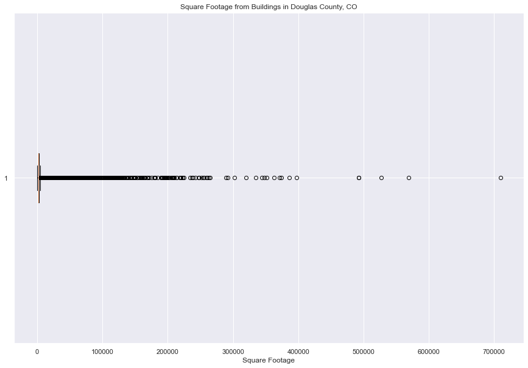

```python
# View visually the distribution of Square Footage

df_PI_SF = df_PI['Built_as_SF']

# Set Figure labels and size
plt.figure(figsize=(15,10))
plt.title('Square Footage from Buildings in Douglas County, CO')
plt.xlabel('Square Footage')
plt.ylabel('')

# Plot data as a boxplot
plt.boxplot(df_PI_SF, notch=None, vert=False, patch_artist=None, widths=None)

plt.show()
```

```python
# View the unique values
df_PI['No_of_Bedrooms'].unique()
```

```
array([  2.,   1.,   0.,   3.,   4.,  nan,   5.,   6.,   7.,  10.,   8.,
        12.,  23.,  39.,  16.,  20.,   9.,  24.,  21.,  14.,  30.,  36.,
        40.,  22.,  26.,  28.,  60., 506.,  18.,  37.,  34.,  58., 149.,
        72.,  56.,  84.,  32.,  46., 193., 335.,  42.,  54., 414.,  80.,
        92., 126., 306., 121., 118., 154.,  25.,  52., 315.,  48., 158.,
       133.,  15., 163., 189.])
```

```python
# Prepare for plotting
df_PI_BR = df_PI['No_of_Bedrooms'].dropna().astype('int64')

df_PI_BR.head()
```

```
0    2
1    1
2    1
3    2
4    1
Name: No_of_Bedrooms, dtype: int64
```

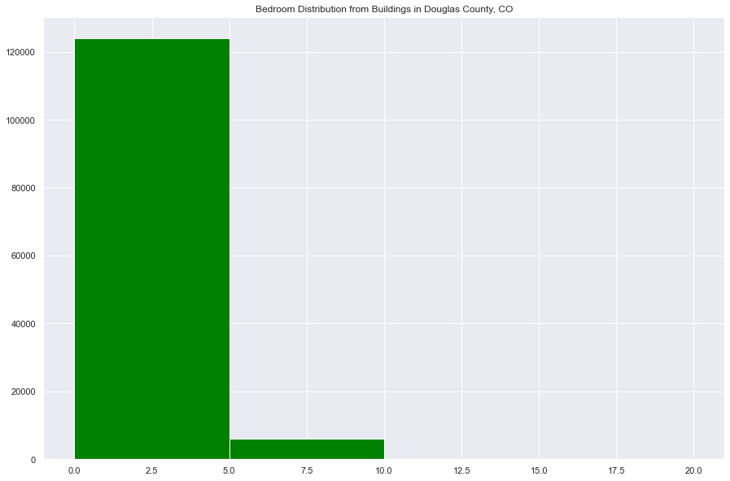

```python
# Plot number of bedrooms (distribution)

# Set Figure labels and size
plt.figure(figsize=(15,10))
plt.title('Bedroom Distribution from Buildings in Douglas County, CO')
plt.xlabel('')
plt.ylabel('')
plt.hist(df_PI_BR, bins=[0,5,10,15,20],
         histtype='bar', align='mid', orientation='vertical', rwidth=None, log=False, color='green', label=None)

plt.show()
```

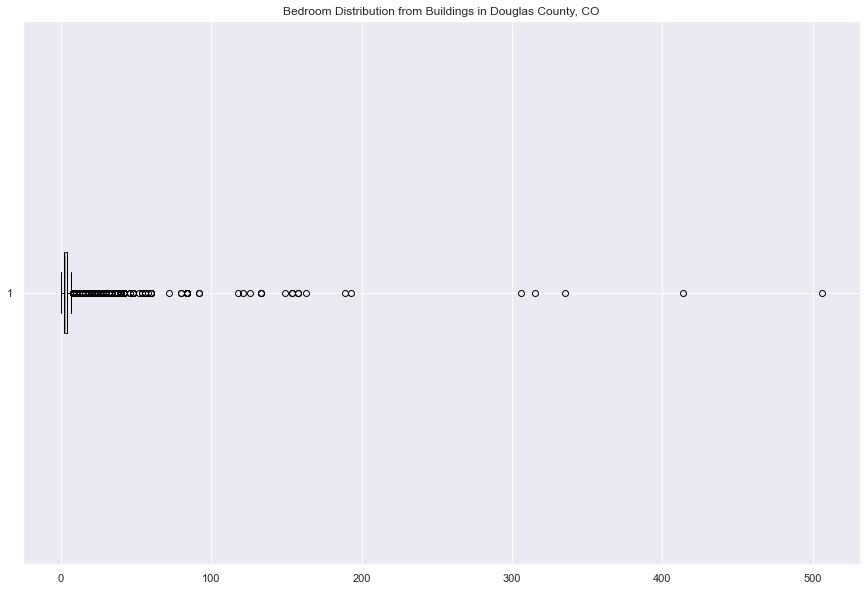

```python
# View visually the distribution of Bedrooms
# Set Figure labels and size
plt.figure(figsize=(15,10))
plt.title('Bedroom Distribution from Buildings in Douglas County, CO')
plt.xlabel('')
plt.ylabel('')
# Plot data as a boxplot
plt.boxplot(df_PI_BR, notch=None, vert=False, patch_artist=None, widths=None)

plt.show()
```

```python
# View the unique values
df_PI['Built_Year'].unique()
```

```
array([1999, 1973, 1974, 1972, 1977, 1969, 1971, 1964, 1965, 1978, 1962,
       1979, 1980, 1982, 1981, 1984, 1983, 1985, 1986, 1970, 1976, 1988,
       1989, 1990, 1991, 1992, 1993, 1994, 1995, 1968, 1996, 1997, 1998,
       2001, 1961, 2000, 2002, 2003, 2005, 2006, 2007, 2008, 2009, 2010,
       2011, 2012, 2013, 2014, 2015, 2016, 2017, 2019, 1963, 2020, 1957,
       1960, 1947, 1900, 1935, 1987, 1950, 1966, 1954, 1887, 1959, 1951,
       1908, 1911, 1967, 1915, 1945, 1975, 2018, 1914, 1955, 1889, 1931,
       1916, 1941, 1956, 1905, 1948, 1953, 1949, 1891, 1893, 2004, 1930,
       1899, 1920, 1890, 1934, 1940, 1922, 1952, 1938, 1942, 1888, 1917,
       1880, 1898, 1937, 1958, 1876, 1878, 1918, 1946, 1894, 1923, 1943,
       1926, 1872, 1919, 1879, 1932, 1933, 1928, 1910, 1912, 1897, 1944,
       1904, 1886, 1875, 1913, 1927, 1877, 1882, 1921, 1883, 1909, 1924,
       1939, 1902, 1867, 1895, 1925, 1892, 1871, 1870, 1906, 1936, 1907,
       1885, 1903, 1884, 1874, 1868, 1929, 1896, 1901, 1873, 1859, 1863,
       1864, 1825, 1881, 2021, 1865], dtype=int64)
```

```python
# View the unique values
df_PI['No_Of_Unit'].unique()
```

```
array([1.000e+00, 0.000e+00, 4.000e+00, 8.000e+00, 2.000e+00, 3.000e+00,
       4.800e+01, 1.700e+01, 6.000e+00, 2.400e+01, 5.000e+00, 1.200e+01,
       1.000e+01, 2.300e+01, 7.000e+00, 1.400e+01, 3.300e+01,       nan,
       1.800e+01, 9.000e+00, 2.700e+01, 2.900e+01, 1.500e+01, 3.800e+01,
       2.230e+02, 1.120e+02, 2.470e+02, 3.200e+01, 2.100e+01, 1.600e+01,
       6.900e+01, 2.000e+01, 3.400e+01, 7.400e+01, 7.800e+01, 3.900e+01,
       2.200e+01, 1.270e+02, 6.800e+01, 1.200e+02, 6.300e+01, 4.800e+02,
       7.300e+01, 1.140e+02, 1.570e+02, 1.900e+01, 2.800e+01, 1.560e+02,
       6.600e+01, 6.000e+01, 8.000e+01, 7.200e+01, 1.300e+01, 1.100e+01,
       1.090e+02, 2.300e+02, 3.600e+01, 1.452e+03, 1.280e+02, 4.000e+01,
       1.010e+02, 6.700e+01, 1.310e+02, 8.400e+01, 9.700e+01, 6.200e+01,
       4.200e+01, 8.800e+01, 1.330e+02, 3.000e+01, 9.000e+01, 9.100e+01,
       4.300e+01, 6.500e+01, 5.900e+01, 2.600e+01, 4.400e+01, 1.340e+02,
       1.470e+02, 1.230e+02, 1.370e+02, 1.710e+02, 1.100e+02, 2.430e+02,
       2.130e+02, 2.670e+02, 2.580e+02, 2.000e+02, 3.000e+02, 2.770e+02,
       1.000e+02, 4.700e+01, 3.500e+01, 5.600e+01, 1.020e+02, 9.600e+01,
       1.620e+02, 2.810e+02, 1.060e+02, 2.500e+01, 2.110e+02, 5.400e+01,
       1.210e+02, 6.400e+01, 1.030e+02, 2.240e+02, 1.150e+02, 5.700e+01,
       1.250e+02, 4.900e+01, 7.640e+02, 2.190e+02, 7.000e+01, 1.160e+02,
       1.770e+02, 2.760e+02, 6.960e+02, 1.080e+02, 2.320e+02, 4.660e+02,
       5.100e+01, 1.220e+02, 1.640e+02, 9.900e+01, 3.100e+01, 1.110e+02,
       1.040e+02, 1.190e+02])
```

```python
# View the unique values for Unit Type
# This term refers to the way Condominium or Townhouse properties are typically constructed in groups
# where some of the walls are common or shared. A unit’s location in the overall structure can influence its
# market value, based on whether it is an interior or end unit.

df_PI['Unit_Type'].unique()
```

```
array([nan, 'End', 'Inside'], dtype=object)
```

```python
# View the unique values
df_PI['Property_Type_Code'].unique()
```

```
array(['Mobile Home', 'Residential', 'Out Building', 'Commercial',
       'Townhouse', 'Multiple Unit', 'Condo', 'Triplex', 'Duplex'],
      dtype=object)
```

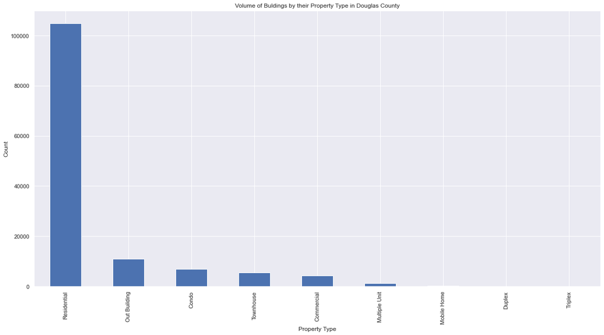

```python
# View visually the numer of accounts by Style
df_PI['Property_Type_Code'].value_counts().plot(kind='bar',
                    title = "Volume of Buldings by their Property Type in Douglas County",xlabel = "Property Type",
                    ylabel = "Count", figsize = (20,10))
plt.show()
```

###### Identify the Null/Nan Values in each Column

```python
# Check for the number of "Nan" values in each column of the dataframe
df_PI.isna().sum()
```

```
Account_No                           0
Building_ID                          0
Style                                0
Occupancy_Code                       0
Built_As_code                        0
Built_As                             0
Quality_Code                       613
Property_Type_Code                   0
Improvement_Type_Code                0
Completion_Percent                   0
Unit_Type                       121348
No_of_Fireplace                      0
Total_Garage_SF                      0
Walkout_Basement_Flag                0
Total_Porch_SF                       0
Total_Finished_Basement_SF           0
Total_Unfinished_Basement_SF         0
Roof_Construction_Type           18802
Built_as_SF                          0
Exterior_Construction            15467
Interior_Construction            16549
No_of_Story                          6
Roof_Material_Code               16235
Floor_Material_Type_Code         16266
No_of_Bedrooms                    3251
No_of_Bathrooms                   3253
Built_Year                           0
Remodeled_Year                   21242
Length_of_Mobile_Home            14324
Width_of_Mobile_Home             14322
Average_Story_Height               371
No_Of_Unit                          12
Sprinkler_Coverage_SF                7
Condition                          614
HVAC                               682
dtype: int64
```

```python
# Review the information on the dataframe (columns, non-null count, data types, index range, )
df_PI.info()
```

```
<class 'pandas.core.frame.DataFrame'>
RangeIndex: 133865 entries, 0 to 133864
Data columns (total 35 columns):
 #   Column                        Non-Null Count   Dtype
---  ------                        --------------   -----
 0   Account_No                    133865 non-null  object
 1   Building_ID                   133865 non-null  float64
 2   Style                         133865 non-null  object
 3   Occupancy_Code                133865 non-null  int64
 4   Built_As_code                 133865 non-null  int64
 5   Built_As                      133865 non-null  object
 6   Quality_Code                  133252 non-null  object
 7   Property_Type_Code            133865 non-null  object
 8   Improvement_Type_Code         133865 non-null  int64
 9   Completion_Percent            133865 non-null  float64
```

[output cut: 27 more lines]

###### Data Manipulation - Filters, etc...

I am only interested in Single Family Homes. The column/variable "Property_Type_Code" has 9 values. Filtering on "Residential", should give me residential properities. The column/Variable "Style" has 12 values for residential properties. Filtering on "Residential" and "Single Family Residential" for these two variables should give me only the single family homes (detatched) that I am looking for.

Each of the records in the resulting dataframe represent a Single Building (Building_ID)

[output not shown]

```python
# Filter the dataframe for "Residential" properties
df_PI_sfres = df_PI[(df_PI['Property_Type_Code'] == 'Residential')
                    & (df_PI['Style'] == 'Single Family Residential') & (df_PI['Built_As'] != 'Permit Value')]
```

```python
# View the shape of the filtered data frame
df_PI_sfres.shape
```

```
(102141, 35)
```

```python
# Use Describe to view descriptive statistics on each of the columns.
df_PI_sfres.describe(include=['object','float64','int64','datetime64[ns]'])
```

|  | Account_No | Building_ID | Style | Occupancy_Code | Built_As_code | Built_As | Quality_Code | Property_Type_Code | Improvement_Type_Code | Completion_Percent | Unit_Type | No_of_Fireplace | Total_Garage_SF | Walkout_Basement_Flag | Total_Porch_SF | Total_Finished_Basement_SF | Total_Unfinished_Basement_SF | Roof_Construction_Type | Built_as_SF | Exterior_Construction | Interior_Construction | No_of_Story | Roof_Material_Code | Floor_Material_Type_Code | No_of_Bedrooms | No_of_Bathrooms | Built_Year | Remodeled_Year | Length_of_Mobile_Home | … |
| --- | --- | --- | --- | --- | --- | --- | --- | --- | --- | --- | --- | --- | --- | --- | --- | --- | --- | --- | --- | --- | --- | --- | --- | --- | --- | --- | --- | --- | --- | --- |
| count | 102141 | 102141.000000 | 102141 | 102141.0 | 102141.000000 | 102141 | 102128 | 102141 | 102141.000000 | 102141.000000 | 135 | 102141.000000 | 102141.000000 | 102141 | 102141.000000 | 102141.000000 | 102141.000000 | 88355 | 102141.000000 | 102116 | 102100 | 102140.000000 | 102106 | 102099 | 102099.000000 | 102098.000000 | 102141.000000 | 85890.000000 | 89330.000000 | … |
| unique | 101848 | NaN | 1 | NaN | NaN | 18 | 6 | 1 | NaN | NaN | 2 | NaN | NaN | 2 | NaN | NaN | NaN | 9 | NaN | 30 | 3 | NaN | 13 | 18 | NaN | NaN | NaN | NaN | NaN | … |
| top | R0482022 | NaN | Single Family Residential | NaN | NaN | 2 Story | Average | Residential | NaN | NaN | End | NaN | NaN | N | NaN | NaN | NaN | Gable | NaN | Frame Siding | Drywall | NaN | Composition Shingle | Allowance | NaN | NaN | NaN | NaN | NaN | … |
| freq | 40 | NaN | 102141 | NaN | NaN | 67920 | 66026 | 102141 | NaN | NaN | 126 | NaN | NaN | 74858 | NaN | NaN | NaN | 64000 | NaN | 87498 | 102015 | NaN | 79258 | 98994 | NaN | NaN | NaN | NaN | NaN | … |
| mean | NaN | 1.019581 | NaN | 100.0 | 6.379211 | NaN | NaN | NaN | 2390.625420 | 99.987615 | NaN | 0.989681 | 603.224954 | NaN | 450.553108 | 529.788684 | 681.160151 | NaN | 2390.386221 | NaN | NaN | 1.690386 | NaN | NaN | 3.317633 | 2.989865 | 1999.031799 | 163.549657 | 0.003358 | … |
| std | NaN | 0.528054 | NaN | 0.0 | 5.258727 | NaN | NaN | NaN | 813.754438 | 0.970534 | NaN | 0.556510 | 265.067514 | NaN | 462.819952 | 692.249999 | 637.489420 | NaN | 813.948186 | NaN | NaN | 0.475923 | NaN | NaN | 0.838955 | 0.784113 | 13.088312 | 549.070511 | 0.439298 | … |
| min | NaN | 1.000000 | NaN | 100.0 | 1.000000 | NaN | NaN | NaN | 0.000000 | 0.000000 | NaN | 0.000000 | 0.000000 | NaN | 0.000000 | 0.000000 | -639.000000 | NaN | 0.000000 | NaN | NaN | 0.000000 | NaN | NaN | 0.000000 | 0.000000 | 1867.000000 | 0.000000 | 0.000000 | … |
| 25% | NaN | 1.000000 | NaN | 100.0 | 7.000000 | NaN | NaN | NaN | 1808.000000 | 100.000000 | NaN | 1.000000 | 440.000000 | NaN | 191.000000 | 0.000000 | 123.000000 | NaN | 1807.000000 | NaN | NaN | 1.000000 | NaN | NaN | 3.000000 | 3.000000 | 1993.000000 | 0.000000 | 0.000000 | … |
| 50% | NaN | 1.000000 | NaN | 100.0 | 8.000000 | NaN | NaN | NaN | 2284.000000 | 100.000000 | NaN | 1.000000 | 579.000000 | NaN | 337.000000 | 0.000000 | 512.000000 | NaN | 2284.000000 | NaN | NaN | 2.000000 | NaN | NaN | 3.000000 | 3.000000 | 1999.000000 | 0.000000 | 0.000000 | … |
| 75% | NaN | 1.000000 | NaN | 100.0 | 8.000000 | NaN | NaN | NaN | 2844.000000 | 100.000000 | NaN | 1.000000 | 687.000000 | NaN | 553.000000 | 986.000000 | 1093.000000 | NaN | 2844.000000 | NaN | NaN | 2.000000 | NaN | NaN | 4.000000 | 3.000000 | 2006.000000 | 0.000000 | 0.000000 | … |
| max | NaN | 42.000000 | NaN | 100.0 | 1124.000000 | NaN | NaN | NaN | 16807.000000 | 100.000000 | NaN | 8.000000 | 7745.000000 | NaN | 16444.000000 | 22450.000000 | 6964.000000 | NaN | 16807.000000 | NaN | NaN | 10.000000 | NaN | NaN | 10.000000 | 18.000000 | 2021.000000 | 2020.000000 | 70.000000 | … |

```python
# Aggregate Volume by Built_Year
df_sfres_yr_built = df_PI_sfres.groupby(['Built_Year']).size().to_frame('count').reset_index()
# Aggregate Volume by Remodeled_Year and drop the first 2 records (non-remodels and weird entry)
df_sfres_yr_remod = df_PI_sfres.groupby(['Remodeled_Year']).size().to_frame('count').reset_index().drop([0],axis = 0)
```

```python
# View the first few records
df_sfres_yr_built.head()
```

|  | Built_Year | count |
| --- | --- | --- |
| 0 | 1867 | 1 |
| 1 | 1871 | 1 |
| 2 | 1872 | 2 |
| 3 | 1873 | 1 |
| 4 | 1875 | 2 |

```python
# View the last few records
df_sfres_yr_built.tail()
```

|  | Built_Year | count |
| --- | --- | --- |
| 140 | 2017 | 2059 |
| 141 | 2018 | 2787 |
| 142 | 2019 | 2887 |
| 143 | 2020 | 2754 |
| 144 | 2021 | 1 |

```python
# View the first few records
df_sfres_yr_remod.head()
```

|  | Remodeled_Year | count |
| --- | --- | --- |
| 1 | 1938.0 | 1 |
| 2 | 1940.0 | 2 |
| 3 | 1941.0 | 3 |
| 4 | 1942.0 | 5 |
| 5 | 1943.0 | 6 |

```python
# View the last few records
df_sfres_yr_remod.tail()
```

|  | Remodeled_Year | count |
| --- | --- | --- |
| 78 | 2016.0 | 478 |
| 79 | 2017.0 | 443 |
| 80 | 2018.0 | 382 |
| 81 | 2019.0 | 229 |
| 82 | 2020.0 | 58 |

```python
# Drop the last record (144) - 2021 is only a partial year (2 months)
df_sfres_yr_built.drop([144],axis=0, inplace=True)
```

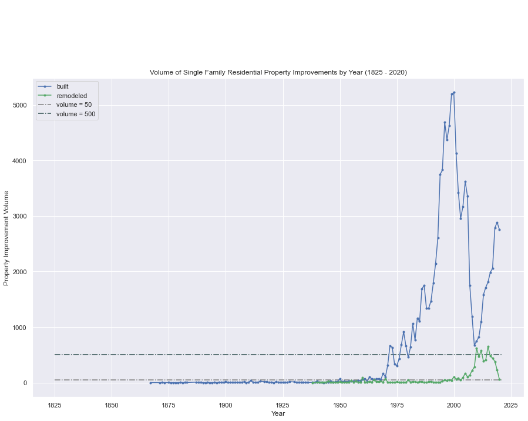

```python
## Plot Volume by Year Built and Remodels

# Set Figure labels and size
plt.figure(figsize=(15,10))
plt.title('Volume of Single Family Residential Property Improvements by Year (1825 - 2020)')
plt.xlabel('Year')
plt.ylabel('Property Improvement Volume')

plt.plot(df_sfres_yr_built['Built_Year'], df_sfres_yr_built['count'], 'b.-', label = 'built')
plt.plot(df_sfres_yr_remod['Remodeled_Year'], df_sfres_yr_remod['count'], 'g.-', label = 'remodeled')
plt.hlines(50, xmin=1825,xmax=2021, colors='gray', linestyles='dashdot', label='volume = 50', data=None)
plt.hlines(500, xmin=1825,xmax=2021, colors='darkslategray', linestyles='dashdot', label='volume = 500', data=None)
plt.annotate("2000", (2000,6744))

plt.legend(loc='upper left')

plt.show()
```

```python
# Check for any duplicated records in the dataframe - specific columns
df_PI_sfres.duplicated(subset=["Account_No"],keep ='first').sum()
```

```
293
```

```python
# Check for any duplicated records in the dataframe - specific columns
df_PI_sfres.duplicated(subset=["Account_No","Building_ID"],keep ='first').sum()
```

```
5
```

```python
# Check for any duplicated records in the dataframe - specific columns
df_PI_sfres.duplicated(subset=["Account_No","Building_ID","Built_As"],keep ='first').sum()
```

```
0
```

```python
# View the unique values
df_PI_sfres['Built_As'].unique()
```

```
array(['Ranch 1 Story', '1 1/2 Story Fin', 'Split Level', '2 Story',
       'Modular', 'Bi Level', 'Farm Utility Lean-Tos (124)', '3 Story',
       'Dome', 'Cabin', 'Earth Sheltered', 'Retail Store',
       '1 1/2 Story Unfin', '2 1/2 Story', 'A Frame',
       'Modular 1 12 Story', 'Office Building', 'Cottage'], dtype=object)
```

```python
# View the unique values
df_PI_sfres['Built_As'].nunique()
```

```
18
```

```python
# Look at the combination of Building id and Build as
# Building ID: Each building on a property is given a unique number, and all data pertaining to that improvement is
#    associated with the number.
df_PI_sfres.value_counts(['Built_As'])
```

```
Built_As
2 Story                        67920
Ranch 1 Story                  22964
Split Level                     8155
Bi Level                        1303
1 1/2 Story Fin                  923
3 Story                          494
Modular                          163
Cabin                            124
2 1/2 Story                       35
Dome                              18
Earth Sheltered                   17
A Frame                           11
1 1/2 Story Unfin                  7
Retail Store                       3
Farm Utility Lean-Tos (124)        1
Modular 1 12 Story                 1
Office Building                    1
Cottage                            1
dtype: int64
```

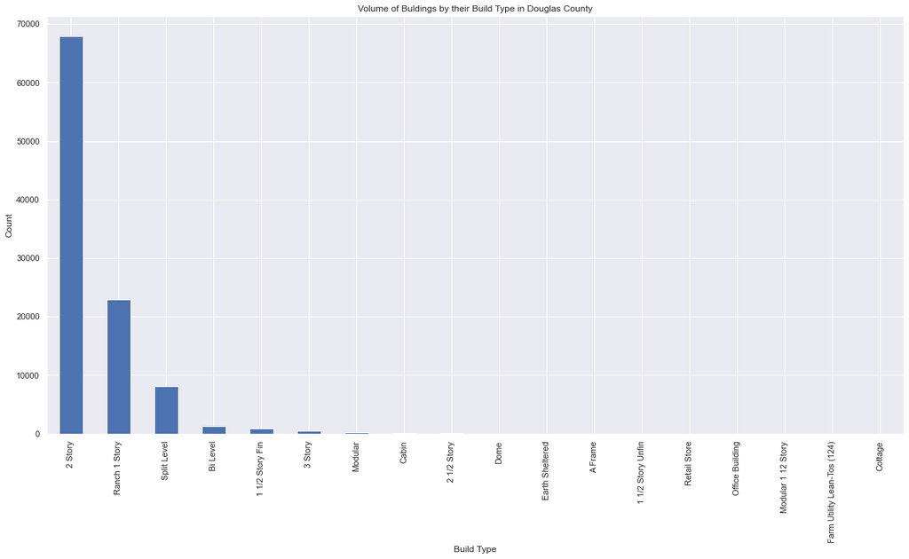

```python
# View visually the top 30 values by Style
df_BuiltAs_sum = df_PI_sfres['Built_As'].value_counts()
df_BuiltAs_sum[0:30].plot(kind='bar', title = "Volume of Buldings by their Build Type in Douglas County",
                        xlabel = "Build Type", ylabel = "Count", figsize = (20,10))

plt.show()
```

```python
# extract duplicate records
builtas_dups = df_PI_sfres.duplicated(subset=["Account_No","Building_ID"], keep = 'first')
builtas_dups_list = df_PI_sfres[builtas_dups]
builtas_dups_list
```

|  | Account_No | Building_ID | Style | Occupancy_Code | Built_As_code | Built_As | Quality_Code | Property_Type_Code | Improvement_Type_Code | Completion_Percent | Unit_Type | No_of_Fireplace | Total_Garage_SF | Walkout_Basement_Flag | Total_Porch_SF | Total_Finished_Basement_SF | Total_Unfinished_Basement_SF | Roof_Construction_Type | Built_as_SF | Exterior_Construction | Interior_Construction | No_of_Story | Roof_Material_Code | Floor_Material_Type_Code | No_of_Bedrooms | No_of_Bathrooms | Built_Year | Remodeled_Year | Length_of_Mobile_Home | … |
| --- | --- | --- | --- | --- | --- | --- | --- | --- | --- | --- | --- | --- | --- | --- | --- | --- | --- | --- | --- | --- | --- | --- | --- | --- | --- | --- | --- | --- | --- | --- |
| 430 | R0001812 | 1.0 | Single Family Residential | 100 | 1124 | Farm Utility Lean-Tos (124) | Average | Residential | 2554 | 100.0 | NaN | 0 | 1732 | N | 1500 | 0 | 0 | Shed | 216 | NaN | NaN | 1.0 | NaN | NaN | NaN | NaN | 1985 | NaN | 0.0 | … |
| 4183 | R0051764 | 1.0 | Single Family Residential | 100 | 353 | Retail Store | Average | Residential | 1853 | 100.0 | NaN | 1 | 0 | N | 356 | 0 | 1209 | Gable | 757 | NaN | NaN | 1.0 | NaN | Allowance | 0.0 | 0.0 | 1918 | 2006.0 | 0.0 | … |
| 64392 | R0400127 | 1.0 | Single Family Residential | 100 | 8 | 2 Story | Average | Residential | 2648 | 100.0 | NaN | 0 | 0 | N | 0 | 0 | 0 | Gable | 1658 | Frame Vinyl | Drywall | 2.0 | Composition Shingle | Allowance | 0.0 | 0.0 | 1887 | 0.0 | 0.0 | … |
| 70497 | R0409750 | 1.0 | Single Family Residential | 100 | 353 | Retail Store | Average | Residential | 1703 | 100.0 | NaN | 0 | 0 | N | 0 | 0 | 0 | Gable | 1056 | NaN | NaN | 1.0 | NaN | NaN | 0.0 | 0.0 | 1900 | 1998.0 | 0.0 | … |
| 89782 | R0437998 | 9.0 | Single Family Residential | 100 | 1 | Ranch 1 Story | Average | Residential | 3916 | 100.0 | NaN | 0 | 440 | N | 0 | 0 | 0 | Hip | 2766 | Frame Siding | Drywall | 1.0 | Composition Shingle | Allowance | 1.0 | 1.0 | 1997 | 0.0 | 0.0 | … |

```python
# Look at accounts and bulidings where the use has changed - There are 5 Buildings where the use has changed.
ba_dups = ['R0001812','R0051764','R0400127','R0409750','R0437998']
df_builtas_dups_rec = df_PI_sfres[df_PI_sfres.Account_No.isin(ba_dups)]
df_builtas_dups_rec.head(20)
```

|  | Account_No | Building_ID | Style | Occupancy_Code | Built_As_code | Built_As | Quality_Code | Property_Type_Code | Improvement_Type_Code | Completion_Percent | Unit_Type | No_of_Fireplace | Total_Garage_SF | Walkout_Basement_Flag | Total_Porch_SF | Total_Finished_Basement_SF | Total_Unfinished_Basement_SF | Roof_Construction_Type | Built_as_SF | Exterior_Construction | Interior_Construction | No_of_Story | Roof_Material_Code | Floor_Material_Type_Code | No_of_Bedrooms | No_of_Bathrooms | Built_Year | Remodeled_Year | Length_of_Mobile_Home | … |
| --- | --- | --- | --- | --- | --- | --- | --- | --- | --- | --- | --- | --- | --- | --- | --- | --- | --- | --- | --- | --- | --- | --- | --- | --- | --- | --- | --- | --- | --- | --- |
| 429 | R0001812 | 1.0 | Single Family Residential | 100 | 2 | Bi Level | Average | Residential | 2554 | 100.0 | NaN | 0 | 1732 | N | 1500 | 0 | 0 | Gable | 2338 | Frame Siding | Drywall | 1.0 | Composition Shingle | Allowance | 3.0 | 3.0 | 1985 | 0.0 | NaN | … |
| 430 | R0001812 | 1.0 | Single Family Residential | 100 | 1124 | Farm Utility Lean-Tos (124) | Average | Residential | 2554 | 100.0 | NaN | 0 | 1732 | N | 1500 | 0 | 0 | Shed | 216 | NaN | NaN | 1.0 | NaN | NaN | NaN | NaN | 1985 | NaN | 0.0 | … |
| 4182 | R0051764 | 1.0 | Single Family Residential | 100 | 1 | Ranch 1 Story | Average | Residential | 1853 | 100.0 | NaN | 1 | 0 | N | 356 | 0 | 1209 | Gable | 1096 | Frame Siding | Drywall | 1.0 | Composition Shingle | Allowance | 0.0 | 0.0 | 1918 | 2006.0 | 0.0 | … |
| 4183 | R0051764 | 1.0 | Single Family Residential | 100 | 353 | Retail Store | Average | Residential | 1853 | 100.0 | NaN | 1 | 0 | N | 356 | 0 | 1209 | Gable | 757 | NaN | NaN | 1.0 | NaN | Allowance | 0.0 | 0.0 | 1918 | 2006.0 | 0.0 | … |
| 64389 | R0400127 | 1.0 | Single Family Residential | 100 | 353 | Retail Store | Average | Residential | 2648 | 100.0 | NaN | 0 | 0 | N | 0 | 0 | 0 | Gable | 990 | NaN | NaN | 1.0 | NaN | Allowance | 0.0 | 0.0 | 1887 | 1992.0 | 0.0 | … |
| 64392 | R0400127 | 1.0 | Single Family Residential | 100 | 8 | 2 Story | Average | Residential | 2648 | 100.0 | NaN | 0 | 0 | N | 0 | 0 | 0 | Gable | 1658 | Frame Vinyl | Drywall | 2.0 | Composition Shingle | Allowance | 0.0 | 0.0 | 1887 | 0.0 | 0.0 | … |
| 70496 | R0409750 | 1.0 | Single Family Residential | 100 | 1 | Ranch 1 Story | Average | Residential | 1703 | 100.0 | NaN | 0 | 0 | N | 0 | 0 | 0 | Gable | 647 | NaN | Drywall | 1.0 | Composition Roll | NaN | 1.0 | 2.0 | 1900 | 1998.0 | 0.0 | … |
| 70497 | R0409750 | 1.0 | Single Family Residential | 100 | 353 | Retail Store | Average | Residential | 1703 | 100.0 | NaN | 0 | 0 | N | 0 | 0 | 0 | Gable | 1056 | NaN | NaN | 1.0 | NaN | NaN | 0.0 | 0.0 | 1900 | 1998.0 | 0.0 | … |
| 89781 | R0437998 | 9.0 | Single Family Residential | 100 | 344 | Office Building | Average | Residential | 3916 | 100.0 | NaN | 0 | 440 | N | 0 | 0 | 0 | Hip | 1150 | NaN | NaN | 1.0 | NaN | NaN | 0.0 | 0.0 | 1997 | 0.0 | 0.0 | … |
| 89782 | R0437998 | 9.0 | Single Family Residential | 100 | 1 | Ranch 1 Story | Average | Residential | 3916 | 100.0 | NaN | 0 | 440 | N | 0 | 0 | 0 | Hip | 2766 | Frame Siding | Drywall | 1.0 | Composition Shingle | Allowance | 1.0 | 1.0 | 1997 | 0.0 | 0.0 | … |

```python
# Filter the dataframe for "Residential" properties
df_PI_sfres2 = df_PI_sfres[(df_PI_sfres['Built_As'] != 'Farm Utility Lean-Tos (124)')
                    & (df_PI_sfres['Built_As'] != 'Retail Store') & (df_PI_sfres['Built_As'] != 'Office Building')]
```

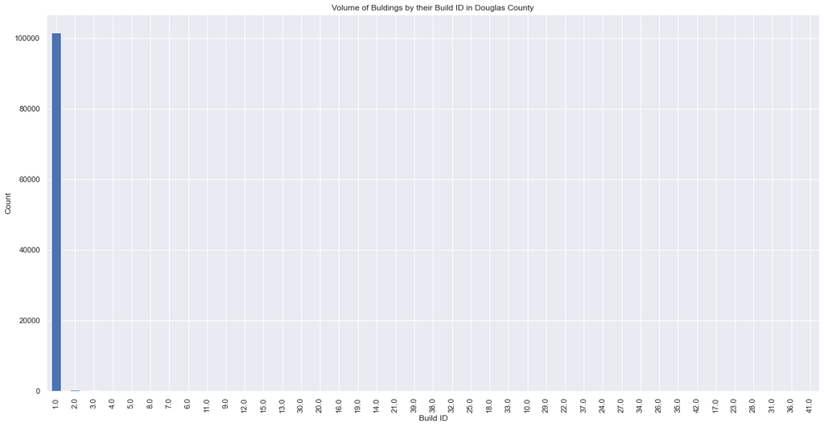

```python
# View visually the numer of accounts by Building ID
df_PI_sfres2['Building_ID'].value_counts().plot(kind='bar',
                            title = "Volume of Buldings by their Build ID in Douglas County",
                            xlabel = "Build ID", ylabel = "Count", figsize = (20,10))

plt.show()
```

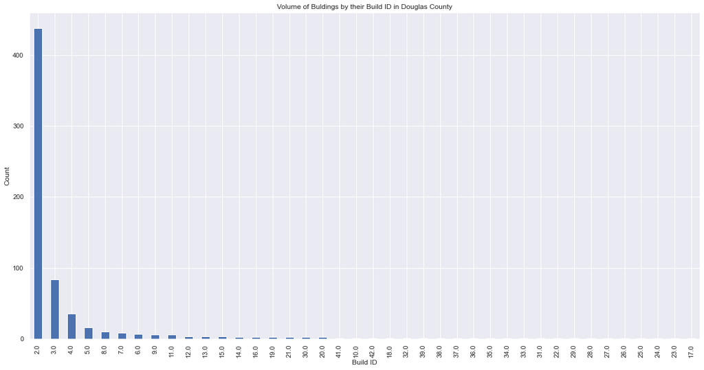

```python
# View visually the Building_ID data
df_PI_sfres2plot = df_PI_sfres[(df_PI_sfres['Building_ID'] > 1.0)]
df_PI_sfres2plot['Building_ID'].value_counts().plot(kind='bar',
                    title ="Volume of Buldings by their Build ID in Douglas County",
                    xlabel = "Build ID", ylabel = "Count", figsize = (20,10))
plt.show()
```

```python
# View visually the numer of accounts by BuildingID and Built As
plotdata1 = df_PI_sfres2.groupby(['Built_As','Building_ID']).size()
plotdata1
```

```
Built_As            Building_ID
1 1/2 Story Fin     1.0              901
                    2.0               13
                    3.0                1
                    4.0                5
                    8.0                1
                    11.0               1
                    13.0               1
1 1/2 Story Unfin   1.0                6
                    3.0                1
2 1/2 Story         1.0               35
2 Story             1.0            67698
                    2.0              187
                    3.0               22
                    4.0                3
                    5.0                3
                    6.0                1
                    8.0                5
                    9.0                1
3 Story             1.0              492
                    2.0                1
                    20.0               1
A Frame             1.0               10
                    2.0                1
Bi Level            1.0             1298
                    2.0                3
                    3.0                1
                    15.0               1
Cabin               1.0              105
                    2.0                8
                    3.0                3
                    4.0                4
                    5.0                2
                    6.0                2
Cottage             2.0                1
Dome                1.0               18
Earth Sheltered     1.0               16
                    2.0                1
Modular             1.0              131
                    2.0               14
```

[output cut: 36 more lines]

```
                    31.0               1
                    32.0               1
                    33.0               1
                    34.0               1
                    35.0               1
                    36.0               1
                    37.0               1
                    38.0               1
                    39.0               1
                    41.0               1
                    42.0               1
Split Level         1.0             8146
                    2.0                8
                    3.0                1
dtype: int64
```

```python
# View the Accounts with Large Number of Buildings
Lrg_BldID = df_PI_sfres[(df_PI_sfres['Building_ID'] > 1.0)].sort_values('Building_ID')
Lrg_BldID_AcctNo = Lrg_BldID['Account_No']
Lrg_BldID
```

|  | Account_No | Building_ID | Style | Occupancy_Code | Built_As_code | Built_As | Quality_Code | Property_Type_Code | Improvement_Type_Code | Completion_Percent | Unit_Type | No_of_Fireplace | Total_Garage_SF | Walkout_Basement_Flag | Total_Porch_SF | Total_Finished_Basement_SF | Total_Unfinished_Basement_SF | Roof_Construction_Type | Built_as_SF | Exterior_Construction | Interior_Construction | No_of_Story | Roof_Material_Code | Floor_Material_Type_Code | No_of_Bedrooms | No_of_Bathrooms | Built_Year | Remodeled_Year | Length_of_Mobile_Home | … |
| --- | --- | --- | --- | --- | --- | --- | --- | --- | --- | --- | --- | --- | --- | --- | --- | --- | --- | --- | --- | --- | --- | --- | --- | --- | --- | --- | --- | --- | --- | --- |
| 227 | R0000211 | 2.0 | Single Family Residential | 100 | 1 | Ranch 1 Story | Average | Residential | 840 | 100.0 | NaN | 0 | 0 | N | 0 | 0 | 0 | Gable | 840 | Frame Stucco | Drywall | 1.0 | Built Up Rock | Allowance | 2.0 | 1.0 | 1969 | 0.0 | 0.0 | … |
| 71493 | R0411089 | 2.0 | Single Family Residential | 100 | 1 | Ranch 1 Story | Good | Residential | 2236 | 100.0 | NaN | 1 | 482 | Y | 392 | 1050 | 262 | Gable | 2236 | Frame Siding | Drywall | 1.0 | Composition Shingle | Allowance | 3.0 | 2.0 | 2001 | 0.0 | 0.0 | … |
| 70948 | R0410388 | 2.0 | Single Family Residential | 100 | 8 | 2 Story | Good | Residential | 2943 | 100.0 | NaN | 1 | 736 | N | 472 | 1170 | 62 | Hip | 2943 | Frame Stucco | Drywall | 2.0 | Concrete Tile | Allowance | 4.0 | 4.0 | 1999 | 0.0 | 0.0 | … |
| 70947 | R0410387 | 2.0 | Single Family Residential | 100 | 8 | 2 Story | Good | Residential | 2965 | 100.0 | NaN | 1 | 635 | N | 405 | 1300 | 417 | Hip/Gable | 2965 | Frame Siding | Drywall | 2.0 | Concrete Tile | Allowance | 3.0 | 3.0 | 1999 | 0.0 | 0.0 | … |
| 70938 | R0410378 | 2.0 | Single Family Residential | 100 | 8 | 2 Story | Very Good | Residential | 3675 | 100.0 | NaN | 1 | 746 | Y | 1214 | 1808 | 119 | Gable | 3675 | Frame Brick Veneer | Drywall | 2.0 | Clay Tile | Allowance | 4.0 | 5.0 | 1999 | 0.0 | 0.0 | … |
| ... | ... | ... | ... | ... | ... | ... | ... | ... | ... | ... | ... | ... | ... | ... | ... | ... | ... | ... | ... | ... | ... | ... | ... | ... | ... | ... | ... | ... | ... | … |
| 117942 | R0482022 | 37.0 | Single Family Residential | 100 | 1 | Ranch 1 Story | Average | Residential | 1636 | 100.0 | End | 1 | 400 | N | 270 | 0 | 1636 | Gable | 1636 | Frame Siding | Drywall | 1.0 | Composition Shingle | Allowance | 2.0 | 2.0 | 2008 | 0.0 | 0.0 | … |
| 117943 | R0482022 | 38.0 | Single Family Residential | 100 | 1 | Ranch 1 Story | Average | Residential | 1636 | 100.0 | End | 1 | 400 | N | 270 | 1157 | 479 | Gable | 1636 | Frame Siding | Drywall | 1.0 | Composition Shingle | Allowance | 2.0 | 2.0 | 2008 | 0.0 | 0.0 | … |
| 117944 | R0482022 | 39.0 | Single Family Residential | 100 | 1 | Ranch 1 Story | Average | Residential | 1600 | 100.0 | End | 1 | 400 | N | 245 | 1151 | 449 | Gable | 1600 | Frame Siding | Drywall | 1.0 | Composition Shingle | Allowance | 2.0 | 2.0 | 2008 | 0.0 | 0.0 | … |
| 117946 | R0482022 | 41.0 | Single Family Residential | 100 | 1 | Ranch 1 Story | Average | Residential | 1641 | 100.0 | End | 1 | 400 | N | 275 | 1136 | 505 | Gable | 1641 | Frame Siding | Drywall | 1.0 | Composition Shingle | Allowance | 2.0 | 2.0 | 2008 | 0.0 | 0.0 | … |
| 117947 | R0482022 | 42.0 | Single Family Residential | 100 | 1 | Ranch 1 Story | Average | Residential | 1605 | 100.0 | End | 1 | 400 | N | 245 | 0 | 1605 | Gable | 1605 | Frame Siding | Drywall | 1.0 | Composition Shingle | Allowance | 2.0 | 2.0 | 2007 | 0.0 | 0.0 | … |

653 rows × 35 columns

```python
# Review all of the records for large building ID Accounts
Lrg_BldID_rvw = df_PI_sfres[df_PI_sfres.Account_No.isin(Lrg_BldID_AcctNo)].sort_values('Building_ID')
Lrg_BldID_rvw
```

|  | Account_No | Building_ID | Style | Occupancy_Code | Built_As_code | Built_As | Quality_Code | Property_Type_Code | Improvement_Type_Code | Completion_Percent | Unit_Type | No_of_Fireplace | Total_Garage_SF | Walkout_Basement_Flag | Total_Porch_SF | Total_Finished_Basement_SF | Total_Unfinished_Basement_SF | Roof_Construction_Type | Built_as_SF | Exterior_Construction | Interior_Construction | No_of_Story | Roof_Material_Code | Floor_Material_Type_Code | No_of_Bedrooms | No_of_Bathrooms | Built_Year | Remodeled_Year | Length_of_Mobile_Home | … |
| --- | --- | --- | --- | --- | --- | --- | --- | --- | --- | --- | --- | --- | --- | --- | --- | --- | --- | --- | --- | --- | --- | --- | --- | --- | --- | --- | --- | --- | --- | --- |
| 226 | R0000211 | 1.0 | Single Family Residential | 100 | 1 | Ranch 1 Story | Good | Residential | 2964 | 100.0 | NaN | 1 | 768 | N | 598 | 0 | 0 | Gable | 2964 | Frame Stucco | Drywall | 1.0 | Concrete Tile | Allowance | 3.0 | 2.0 | 1969 | 0.0 | 0.0 | … |
| 95388 | R0445994 | 1.0 | Single Family Residential | 100 | 1 | Ranch 1 Story | Average | Residential | 1439 | 100.0 | NaN | 1 | 483 | N | 549 | 0 | 1271 | NaN | 1439 | Frame Siding | Drywall | 1.0 | Wood Shake | Allowance | 2.0 | 1.0 | 1972 | 0.0 | 0.0 | … |
| 95188 | R0445277 | 1.0 | Single Family Residential | 100 | 8 | 2 Story | Excellent | Residential | 5241 | 100.0 | NaN | 2 | 1108 | Y | 1682 | 1312 | 1318 | Gable | 5241 | Frame Stone Veneer | Drywall | 2.0 | Concrete Tile | Allowance | 4.0 | 6.0 | 2007 | 0.0 | 0.0 | … |
| 15182 | R0161162 | 1.0 | Single Family Residential | 100 | 1 | Ranch 1 Story | Average | Residential | 2936 | 100.0 | NaN | 1 | 675 | Y | 621 | 2788 | 149 | Gable | 2936 | Frame Masonry Veneer | Drywall | 1.0 | Composition Shingle | Allowance | 3.0 | 3.0 | 1978 | 0.0 | 0.0 | … |
| 95170 | R0445253 | 1.0 | Single Family Residential | 100 | 1 | Ranch 1 Story | Very Good | Residential | 3620 | 100.0 | NaN | 1 | 1539 | Y | 2559 | 2453 | 832 | Gable | 3620 | Frame Stucco | Drywall | 1.0 | Composition Shingle | Allowance | 2.0 | 3.0 | 2007 | 0.0 | 0.0 | … |
| ... | ... | ... | ... | ... | ... | ... | ... | ... | ... | ... | ... | ... | ... | ... | ... | ... | ... | ... | ... | ... | ... | ... | ... | ... | ... | ... | ... | ... | ... | … |
| 117942 | R0482022 | 37.0 | Single Family Residential | 100 | 1 | Ranch 1 Story | Average | Residential | 1636 | 100.0 | End | 1 | 400 | N | 270 | 0 | 1636 | Gable | 1636 | Frame Siding | Drywall | 1.0 | Composition Shingle | Allowance | 2.0 | 2.0 | 2008 | 0.0 | 0.0 | … |
| 117943 | R0482022 | 38.0 | Single Family Residential | 100 | 1 | Ranch 1 Story | Average | Residential | 1636 | 100.0 | End | 1 | 400 | N | 270 | 1157 | 479 | Gable | 1636 | Frame Siding | Drywall | 1.0 | Composition Shingle | Allowance | 2.0 | 2.0 | 2008 | 0.0 | 0.0 | … |
| 117944 | R0482022 | 39.0 | Single Family Residential | 100 | 1 | Ranch 1 Story | Average | Residential | 1600 | 100.0 | End | 1 | 400 | N | 245 | 1151 | 449 | Gable | 1600 | Frame Siding | Drywall | 1.0 | Composition Shingle | Allowance | 2.0 | 2.0 | 2008 | 0.0 | 0.0 | … |
| 117946 | R0482022 | 41.0 | Single Family Residential | 100 | 1 | Ranch 1 Story | Average | Residential | 1641 | 100.0 | End | 1 | 400 | N | 275 | 1136 | 505 | Gable | 1641 | Frame Siding | Drywall | 1.0 | Composition Shingle | Allowance | 2.0 | 2.0 | 2008 | 0.0 | 0.0 | … |
| 117947 | R0482022 | 42.0 | Single Family Residential | 100 | 1 | Ranch 1 Story | Average | Residential | 1605 | 100.0 | End | 1 | 400 | N | 245 | 0 | 1605 | Gable | 1605 | Frame Siding | Drywall | 1.0 | Composition Shingle | Allowance | 2.0 | 2.0 | 2007 | 0.0 | 0.0 | … |

859 rows × 35 columns

```python
# View the account with the most buliding IDs - Hmm...... Need to join data to Location.
LrgBld1 = df_PI_sfres[df_PI_sfres['Account_No'] == 'R0482022']
LrgBld1
```

|  | Account_No | Building_ID | Style | Occupancy_Code | Built_As_code | Built_As | Quality_Code | Property_Type_Code | Improvement_Type_Code | Completion_Percent | Unit_Type | No_of_Fireplace | Total_Garage_SF | Walkout_Basement_Flag | Total_Porch_SF | Total_Finished_Basement_SF | Total_Unfinished_Basement_SF | Roof_Construction_Type | Built_as_SF | Exterior_Construction | Interior_Construction | No_of_Story | Roof_Material_Code | Floor_Material_Type_Code | No_of_Bedrooms | No_of_Bathrooms | Built_Year | Remodeled_Year | Length_of_Mobile_Home | … |
| --- | --- | --- | --- | --- | --- | --- | --- | --- | --- | --- | --- | --- | --- | --- | --- | --- | --- | --- | --- | --- | --- | --- | --- | --- | --- | --- | --- | --- | --- | --- |
| 117906 | R0482022 | 1.0 | Single Family Residential | 100 | 1 | Ranch 1 Story | Average | Residential | 1874 | 100.0 | NaN | 1 | 414 | Y | 377 | 1370 | 505 | Hip/Gable | 1874 | Frame Masonry Veneer | Drywall | 1.0 | Composition Shingle | Allowance | 1.0 | 1.0 | 2004 | 0.0 | 0.0 | … |
| 117907 | R0482022 | 2.0 | Single Family Residential | 100 | 1 | Ranch 1 Story | Average | Residential | 1874 | 100.0 | NaN | 1 | 414 | Y | 377 | 1241 | 634 | Gable | 1874 | Frame Masonry Veneer | Drywall | 1.0 | Composition Shingle | Allowance | 2.0 | 3.0 | 2005 | 0.0 | 0.0 | … |
| 117909 | R0482022 | 4.0 | Single Family Residential | 100 | 1 | Ranch 1 Story | Average | Residential | 1849 | 100.0 | NaN | 1 | 400 | Y | 386 | 0 | 1850 | Gable | 1849 | Frame Siding | Drywall | 1.0 | Composition Shingle | Allowance | 2.0 | 3.0 | 2007 | 0.0 | 0.0 | … |
| 117910 | R0482022 | 5.0 | Single Family Residential | 100 | 1 | Ranch 1 Story | Average | Residential | 1856 | 100.0 | End | 1 | 400 | Y | 376 | 1424 | 433 | Gable | 1856 | Frame Siding | Drywall | 1.0 | Composition Shingle | Allowance | 2.0 | 3.0 | 2007 | 0.0 | 0.0 | … |
| 117911 | R0482022 | 6.0 | Single Family Residential | 100 | 1 | Ranch 1 Story | Average | Residential | 1890 | 100.0 | End | 1 | 400 | Y | 288 | 1282 | 609 | Gable | 1890 | Frame Siding | Drywall | 1.0 | Composition Shingle | Allowance | 2.0 | 3.0 | 2007 | 0.0 | 0.0 | … |
| 117912 | R0482022 | 7.0 | Single Family Residential | 100 | 1 | Ranch 1 Story | Average | Residential | 1672 | 100.0 | End | 1 | 400 | Y | 376 | 0 | 1673 | Gable | 1672 | Frame Siding | Drywall | 1.0 | Composition Shingle | Allowance | 2.0 | 3.0 | 2007 | 0.0 | 0.0 | … |
| 117913 | R0482022 | 8.0 | Single Family Residential | 100 | 1 | Ranch 1 Story | Average | Residential | 1912 | 100.0 | End | 1 | 400 | Y | 287 | 1050 | 863 | Gable | 1912 | Frame Siding | Drywall | 1.0 | Composition Shingle | Allowance | 2.0 | 3.0 | 2007 | 0.0 | 0.0 | … |
| 117914 | R0482022 | 9.0 | Single Family Residential | 100 | 1 | Ranch 1 Story | Average | Residential | 1759 | 100.0 | End | 1 | 400 | Y | 376 | 0 | 1760 | Gable | 1759 | Frame Siding | Drywall | 1.0 | Composition Shingle | Allowance | 2.0 | 3.0 | 2007 | 0.0 | 0.0 | … |
| 117915 | R0482022 | 10.0 | Single Family Residential | 100 | 1 | Ranch 1 Story | Average | Residential | 1935 | 100.0 | End | 1 | 400 | Y | 401 | 1373 | 563 | Gable | 1935 | Frame Siding | Drywall | 1.0 | Composition Shingle | Allowance | 2.0 | 3.0 | 2007 | 0.0 | 0.0 | … |
| 117916 | R0482022 | 11.0 | Single Family Residential | 100 | 1 | Ranch 1 Story | Average | Residential | 1671 | 100.0 | End | 1 | 400 | Y | 376 | 0 | 1672 | Gable | 1671 | Frame Siding | Drywall | 1.0 | Composition Shingle | Allowance | 2.0 | 3.0 | 2007 | 0.0 | 0.0 | … |
| 117917 | R0482022 | 12.0 | Single Family Residential | 100 | 1 | Ranch 1 Story | Average | Residential | 1884 | 100.0 | End | 1 | 400 | Y | 289 | 724 | 1161 | Gable | 1884 | Frame Siding | Drywall | 1.0 | Composition Shingle | Allowance | 2.0 | 3.0 | 2007 | 0.0 | 0.0 | … |
| 117918 | R0482022 | 13.0 | Single Family Residential | 100 | 1 | Ranch 1 Story | Average | Residential | 1910 | 100.0 | End | 1 | 400 | Y | 671 | 1313 | 598 | Gable | 1910 | Frame Siding | Drywall | 1.0 | Composition Shingle | Allowance | 2.0 | 3.0 | 2007 | 0.0 | 0.0 | … |
| 117919 | R0482022 | 14.0 | Single Family Residential | 100 | 1 | Ranch 1 Story | Average | Residential | 1868 | 100.0 | End | 1 | 400 | Y | 376 | 1325 | 544 | Gable | 1868 | Frame Siding | Drywall | 1.0 | Composition Shingle | Allowance | 2.0 | 3.0 | 2007 | 0.0 | 0.0 | … |
| 117920 | R0482022 | 15.0 | Single Family Residential | 100 | 1 | Ranch 1 Story | Average | Residential | 1897 | 100.0 | End | 1 | 400 | Y | 401 | 1400 | 498 | Gable | 1897 | Frame Siding | Drywall | 1.0 | Composition Shingle | Allowance | 2.0 | 3.0 | 2007 | 0.0 | 0.0 | … |
| 117921 | R0482022 | 16.0 | Single Family Residential | 100 | 1 | Ranch 1 Story | Average | Residential | 1600 | 100.0 | End | 1 | 400 | N | 222 | 1172 | 428 | Gable | 1600 | Frame Siding | Drywall | 1.0 | Composition Shingle | Allowance | 2.0 | 2.0 | 2007 | 0.0 | 0.0 | … |
| 117922 | R0482022 | 17.0 | Single Family Residential | 100 | 1 | Ranch 1 Story | Average | Residential | 1884 | 100.0 | NaN | 1 | 400 | Y | 386 | 0 | 1885 | Gable | 1884 | Frame Siding | Drywall | 1.0 | Composition Shingle | Allowance | 2.0 | 3.0 | 2008 | 0.0 | 0.0 | … |
| 117923 | R0482022 | 18.0 | Single Family Residential | 100 | 1 | Ranch 1 Story | Average | Residential | 1873 | 100.0 | End | 1 | 400 | Y | 386 | 0 | 1874 | Gable | 1873 | Frame Siding | Drywall | 1.0 | Composition Shingle | Allowance | 2.0 | 3.0 | 2007 | 0.0 | 0.0 | … |
| 117924 | R0482022 | 19.0 | Single Family Residential | 100 | 1 | Ranch 1 Story | Average | Residential | 1925 | 100.0 | End | 1 | 400 | Y | 282 | 1394 | 532 | Gable | 1925 | Frame Siding | Drywall | 1.0 | Composition Shingle | Allowance | 2.0 | 3.0 | 2008 | 0.0 | 0.0 | … |
| 117925 | R0482022 | 20.0 | Single Family Residential | 100 | 1 | Ranch 1 Story | Average | Residential | 1903 | 100.0 | NaN | 1 | 400 | Y | 348 | 1361 | 543 | Gable | 1903 | Frame Siding | Drywall | 1.0 | Composition Shingle | Allowance | 2.0 | 3.0 | 2008 | 0.0 | 0.0 | … |
| 117926 | R0482022 | 21.0 | Single Family Residential | 100 | 1 | Ranch 1 Story | Average | Residential | 1762 | 100.0 | NaN | 1 | 400 | Y | 386 | 0 | 1763 | Gable | 1762 | Frame Siding | Drywall | 1.0 | Composition Shingle | Allowance | 2.0 | 3.0 | 2008 | 0.0 | 0.0 | … |
| 117927 | R0482022 | 22.0 | Single Family Residential | 100 | 1 | Ranch 1 Story | Average | Residential | 1886 | 100.0 | End | 1 | 400 | Y | 409 | 0 | 1887 | Gable | 1886 | Frame Siding | Drywall | 1.0 | Composition Shingle | Allowance | 2.0 | 3.0 | 2008 | 0.0 | 0.0 | … |
| 117928 | R0482022 | 23.0 | Single Family Residential | 100 | 1 | Ranch 1 Story | Average | Residential | 1842 | 100.0 | End | 1 | 400 | Y | 385 | 1325 | 518 | Gable | 1842 | Frame Siding | Drywall | 1.0 | Composition Shingle | Allowance | 2.0 | 3.0 | 2008 | 0.0 | 0.0 | … |
| 117929 | R0482022 | 24.0 | Single Family Residential | 100 | 1 | Ranch 1 Story | Average | Residential | 1598 | 100.0 | End | 1 | 400 | N | 246 | 676 | 922 | Gable | 1598 | Frame Siding | Drywall | 1.0 | Composition Shingle | Allowance | 2.0 | 2.0 | 2008 | 0.0 | 0.0 | … |
| 117930 | R0482022 | 25.0 | Single Family Residential | 100 | 1 | Ranch 1 Story | Average | Residential | 1636 | 100.0 | End | 1 | 400 | N | 270 | 0 | 1636 | Gable | 1636 | Frame Siding | Drywall | 1.0 | Composition Shingle | Allowance | 2.0 | 2.0 | 2008 | 0.0 | 0.0 | … |
| 117931 | R0482022 | 26.0 | Single Family Residential | 100 | 1 | Ranch 1 Story | Average | Residential | 1600 | 100.0 | End | 1 | 400 | N | 245 | 1050 | 550 | Gable | 1600 | Frame Siding | Drywall | 1.0 | Composition Shingle | Allowance | 2.0 | 2.0 | 2008 | 0.0 | 0.0 | … |
| 117932 | R0482022 | 27.0 | Single Family Residential | 100 | 1 | Ranch 1 Story | Average | Residential | 1636 | 100.0 | End | 1 | 400 | N | 270 | 0 | 1636 | Gable | 1636 | Frame Siding | Drywall | 1.0 | Composition Shingle | Allowance | 2.0 | 2.0 | 2008 | 0.0 | 0.0 | … |
| 117933 | R0482022 | 28.0 | Single Family Residential | 100 | 1 | Ranch 1 Story | Average | Residential | 1600 | 100.0 | End | 1 | 400 | N | 245 | 1177 | 423 | Gable | 1600 | Frame Siding | Drywall | 1.0 | Composition Shingle | Allowance | 2.0 | 2.0 | 2008 | 0.0 | 0.0 | … |
| 117934 | R0482022 | 29.0 | Single Family Residential | 100 | 1 | Ranch 1 Story | Average | Residential | 1636 | 100.0 | End | 1 | 400 | N | 270 | 0 | 1636 | Gable | 1636 | Frame Siding | Drywall | 1.0 | Composition Shingle | Allowance | 2.0 | 2.0 | 2008 | 0.0 | 0.0 | … |
| 117935 | R0482022 | 30.0 | Single Family Residential | 100 | 1 | Ranch 1 Story | Average | Residential | 1600 | 100.0 | End | 1 | 400 | N | 245 | 0 | 1600 | Gable | 1600 | Frame Siding | Drywall | 1.0 | Composition Shingle | Allowance | 2.0 | 2.0 | 2008 | 0.0 | 0.0 | … |
| 117936 | R0482022 | 31.0 | Single Family Residential | 100 | 1 | Ranch 1 Story | Average | Residential | 1636 | 100.0 | End | 1 | 400 | N | 270 | 0 | 1636 | Gable | 1636 | Frame Siding | Drywall | 1.0 | Composition Shingle | Allowance | 2.0 | 2.0 | 2008 | 0.0 | 0.0 | … |
| 117937 | R0482022 | 32.0 | Single Family Residential | 100 | 1 | Ranch 1 Story | Average | Residential | 1834 | 100.0 | End | 1 | 400 | Y | 368 | 1200 | 635 | Gable | 1834 | Frame Siding | Drywall | 1.0 | Composition Shingle | Allowance | 2.0 | 3.0 | 2008 | 0.0 | 0.0 | … |
| 117938 | R0482022 | 33.0 | Single Family Residential | 100 | 1 | Ranch 1 Story | Average | Residential | 1896 | 100.0 | End | 1 | 400 | Y | 386 | 1353 | 544 | Gable | 1896 | Frame Siding | Drywall | 1.0 | Composition Shingle | Allowance | 2.0 | 3.0 | 2008 | 0.0 | 0.0 | … |
| 117939 | R0482022 | 34.0 | Single Family Residential | 100 | 1 | Ranch 1 Story | Average | Residential | 1769 | 100.0 | End | 1 | 400 | Y | 342 | 1275 | 495 | Gable | 1769 | Frame Siding | Drywall | 1.0 | Composition Shingle | Allowance | 2.0 | 3.0 | 2008 | 0.0 | 0.0 | … |
| 117940 | R0482022 | 35.0 | Single Family Residential | 100 | 1 | Ranch 1 Story | Average | Residential | 1905 | 100.0 | End | 1 | 400 | Y | 396 | 0 | 1906 | Gable | 1905 | Frame Siding | Drywall | 1.0 | Composition Shingle | Allowance | 2.0 | 3.0 | 2008 | 0.0 | 0.0 | … |
| 117941 | R0482022 | 36.0 | Single Family Residential | 100 | 1 | Ranch 1 Story | Average | Residential | 1787 | 100.0 | End | 1 | 400 | Y | 366 | 0 | 1788 | Gable | 1787 | Frame Siding | Drywall | 1.0 | Composition Shingle | Allowance | 2.0 | 3.0 | 2008 | 0.0 | 0.0 | … |
| 117942 | R0482022 | 37.0 | Single Family Residential | 100 | 1 | Ranch 1 Story | Average | Residential | 1636 | 100.0 | End | 1 | 400 | N | 270 | 0 | 1636 | Gable | 1636 | Frame Siding | Drywall | 1.0 | Composition Shingle | Allowance | 2.0 | 2.0 | 2008 | 0.0 | 0.0 | … |
| 117943 | R0482022 | 38.0 | Single Family Residential | 100 | 1 | Ranch 1 Story | Average | Residential | 1636 | 100.0 | End | 1 | 400 | N | 270 | 1157 | 479 | Gable | 1636 | Frame Siding | Drywall | 1.0 | Composition Shingle | Allowance | 2.0 | 2.0 | 2008 | 0.0 | 0.0 | … |
| 117944 | R0482022 | 39.0 | Single Family Residential | 100 | 1 | Ranch 1 Story | Average | Residential | 1600 | 100.0 | End | 1 | 400 | N | 245 | 1151 | 449 | Gable | 1600 | Frame Siding | Drywall | 1.0 | Composition Shingle | Allowance | 2.0 | 2.0 | 2008 | 0.0 | 0.0 | … |
| 117946 | R0482022 | 41.0 | Single Family Residential | 100 | 1 | Ranch 1 Story | Average | Residential | 1641 | 100.0 | End | 1 | 400 | N | 275 | 1136 | 505 | Gable | 1641 | Frame Siding | Drywall | 1.0 | Composition Shingle | Allowance | 2.0 | 2.0 | 2008 | 0.0 | 0.0 | … |
| 117947 | R0482022 | 42.0 | Single Family Residential | 100 | 1 | Ranch 1 Story | Average | Residential | 1605 | 100.0 | End | 1 | 400 | N | 245 | 0 | 1605 | Gable | 1605 | Frame Siding | Drywall | 1.0 | Composition Shingle | Allowance | 2.0 | 2.0 | 2007 | 0.0 | 0.0 | … |

```python
# View the account with the most buliding IDs - Hmm...... Need to join data to Location.
Lrg_BldID_rvw2 = df_PI_sfres[df_PI_sfres['Building_ID'] >= 20]
Lrg_BldID_rvw2
```

|  | Account_No | Building_ID | Style | Occupancy_Code | Built_As_code | Built_As | Quality_Code | Property_Type_Code | Improvement_Type_Code | Completion_Percent | Unit_Type | No_of_Fireplace | Total_Garage_SF | Walkout_Basement_Flag | Total_Porch_SF | Total_Finished_Basement_SF | Total_Unfinished_Basement_SF | Roof_Construction_Type | Built_as_SF | Exterior_Construction | Interior_Construction | No_of_Story | Roof_Material_Code | Floor_Material_Type_Code | No_of_Bedrooms | No_of_Bathrooms | Built_Year | Remodeled_Year | Length_of_Mobile_Home | … |
| --- | --- | --- | --- | --- | --- | --- | --- | --- | --- | --- | --- | --- | --- | --- | --- | --- | --- | --- | --- | --- | --- | --- | --- | --- | --- | --- | --- | --- | --- | --- |
| 96757 | R0448867 | 21.0 | Single Family Residential | 100 | 1 | Ranch 1 Story | Average | Residential | 2632 | 100.0 | NaN | 0 | 0 | N | 448 | 0 | 0 | Gable | 2632 | Frame Siding | NaN | 1.0 | Composition Shingle | Allowance | 0.0 | 0.0 | 1935 | 0.0 | 0.0 | … |
| 96766 | R0448867 | 30.0 | Single Family Residential | 100 | 1 | Ranch 1 Story | Average | Residential | 1196 | 100.0 | NaN | 1 | 0 | N | 0 | 1196 | 0 | NaN | 1196 | Frame Siding | Drywall | 1.0 | Composition Shingle | Allowance | 0.0 | 0.0 | 1975 | 0.0 | 0.0 | … |
| 98998 | R0451642 | 20.0 | Single Family Residential | 100 | 25 | 3 Story | Average | Residential | 2888 | 100.0 | NaN | 0 | 0 | N | 288 | 0 | 0 | Gambrel | 2888 | Frame Siding | Drywall | 3.0 | Composition Shingle | Allowance | 2.0 | 2.0 | 1981 | 2019.0 | 0.0 | … |
| 117925 | R0482022 | 20.0 | Single Family Residential | 100 | 1 | Ranch 1 Story | Average | Residential | 1903 | 100.0 | NaN | 1 | 400 | Y | 348 | 1361 | 543 | Gable | 1903 | Frame Siding | Drywall | 1.0 | Composition Shingle | Allowance | 2.0 | 3.0 | 2008 | 0.0 | 0.0 | … |
| 117926 | R0482022 | 21.0 | Single Family Residential | 100 | 1 | Ranch 1 Story | Average | Residential | 1762 | 100.0 | NaN | 1 | 400 | Y | 386 | 0 | 1763 | Gable | 1762 | Frame Siding | Drywall | 1.0 | Composition Shingle | Allowance | 2.0 | 3.0 | 2008 | 0.0 | 0.0 | … |
| 117927 | R0482022 | 22.0 | Single Family Residential | 100 | 1 | Ranch 1 Story | Average | Residential | 1886 | 100.0 | End | 1 | 400 | Y | 409 | 0 | 1887 | Gable | 1886 | Frame Siding | Drywall | 1.0 | Composition Shingle | Allowance | 2.0 | 3.0 | 2008 | 0.0 | 0.0 | … |
| 117928 | R0482022 | 23.0 | Single Family Residential | 100 | 1 | Ranch 1 Story | Average | Residential | 1842 | 100.0 | End | 1 | 400 | Y | 385 | 1325 | 518 | Gable | 1842 | Frame Siding | Drywall | 1.0 | Composition Shingle | Allowance | 2.0 | 3.0 | 2008 | 0.0 | 0.0 | … |
| 117929 | R0482022 | 24.0 | Single Family Residential | 100 | 1 | Ranch 1 Story | Average | Residential | 1598 | 100.0 | End | 1 | 400 | N | 246 | 676 | 922 | Gable | 1598 | Frame Siding | Drywall | 1.0 | Composition Shingle | Allowance | 2.0 | 2.0 | 2008 | 0.0 | 0.0 | … |
| 117930 | R0482022 | 25.0 | Single Family Residential | 100 | 1 | Ranch 1 Story | Average | Residential | 1636 | 100.0 | End | 1 | 400 | N | 270 | 0 | 1636 | Gable | 1636 | Frame Siding | Drywall | 1.0 | Composition Shingle | Allowance | 2.0 | 2.0 | 2008 | 0.0 | 0.0 | … |
| 117931 | R0482022 | 26.0 | Single Family Residential | 100 | 1 | Ranch 1 Story | Average | Residential | 1600 | 100.0 | End | 1 | 400 | N | 245 | 1050 | 550 | Gable | 1600 | Frame Siding | Drywall | 1.0 | Composition Shingle | Allowance | 2.0 | 2.0 | 2008 | 0.0 | 0.0 | … |
| 117932 | R0482022 | 27.0 | Single Family Residential | 100 | 1 | Ranch 1 Story | Average | Residential | 1636 | 100.0 | End | 1 | 400 | N | 270 | 0 | 1636 | Gable | 1636 | Frame Siding | Drywall | 1.0 | Composition Shingle | Allowance | 2.0 | 2.0 | 2008 | 0.0 | 0.0 | … |
| 117933 | R0482022 | 28.0 | Single Family Residential | 100 | 1 | Ranch 1 Story | Average | Residential | 1600 | 100.0 | End | 1 | 400 | N | 245 | 1177 | 423 | Gable | 1600 | Frame Siding | Drywall | 1.0 | Composition Shingle | Allowance | 2.0 | 2.0 | 2008 | 0.0 | 0.0 | … |
| 117934 | R0482022 | 29.0 | Single Family Residential | 100 | 1 | Ranch 1 Story | Average | Residential | 1636 | 100.0 | End | 1 | 400 | N | 270 | 0 | 1636 | Gable | 1636 | Frame Siding | Drywall | 1.0 | Composition Shingle | Allowance | 2.0 | 2.0 | 2008 | 0.0 | 0.0 | … |
| 117935 | R0482022 | 30.0 | Single Family Residential | 100 | 1 | Ranch 1 Story | Average | Residential | 1600 | 100.0 | End | 1 | 400 | N | 245 | 0 | 1600 | Gable | 1600 | Frame Siding | Drywall | 1.0 | Composition Shingle | Allowance | 2.0 | 2.0 | 2008 | 0.0 | 0.0 | … |
| 117936 | R0482022 | 31.0 | Single Family Residential | 100 | 1 | Ranch 1 Story | Average | Residential | 1636 | 100.0 | End | 1 | 400 | N | 270 | 0 | 1636 | Gable | 1636 | Frame Siding | Drywall | 1.0 | Composition Shingle | Allowance | 2.0 | 2.0 | 2008 | 0.0 | 0.0 | … |
| 117937 | R0482022 | 32.0 | Single Family Residential | 100 | 1 | Ranch 1 Story | Average | Residential | 1834 | 100.0 | End | 1 | 400 | Y | 368 | 1200 | 635 | Gable | 1834 | Frame Siding | Drywall | 1.0 | Composition Shingle | Allowance | 2.0 | 3.0 | 2008 | 0.0 | 0.0 | … |
| 117938 | R0482022 | 33.0 | Single Family Residential | 100 | 1 | Ranch 1 Story | Average | Residential | 1896 | 100.0 | End | 1 | 400 | Y | 386 | 1353 | 544 | Gable | 1896 | Frame Siding | Drywall | 1.0 | Composition Shingle | Allowance | 2.0 | 3.0 | 2008 | 0.0 | 0.0 | … |
| 117939 | R0482022 | 34.0 | Single Family Residential | 100 | 1 | Ranch 1 Story | Average | Residential | 1769 | 100.0 | End | 1 | 400 | Y | 342 | 1275 | 495 | Gable | 1769 | Frame Siding | Drywall | 1.0 | Composition Shingle | Allowance | 2.0 | 3.0 | 2008 | 0.0 | 0.0 | … |
| 117940 | R0482022 | 35.0 | Single Family Residential | 100 | 1 | Ranch 1 Story | Average | Residential | 1905 | 100.0 | End | 1 | 400 | Y | 396 | 0 | 1906 | Gable | 1905 | Frame Siding | Drywall | 1.0 | Composition Shingle | Allowance | 2.0 | 3.0 | 2008 | 0.0 | 0.0 | … |
| 117941 | R0482022 | 36.0 | Single Family Residential | 100 | 1 | Ranch 1 Story | Average | Residential | 1787 | 100.0 | End | 1 | 400 | Y | 366 | 0 | 1788 | Gable | 1787 | Frame Siding | Drywall | 1.0 | Composition Shingle | Allowance | 2.0 | 3.0 | 2008 | 0.0 | 0.0 | … |
| 117942 | R0482022 | 37.0 | Single Family Residential | 100 | 1 | Ranch 1 Story | Average | Residential | 1636 | 100.0 | End | 1 | 400 | N | 270 | 0 | 1636 | Gable | 1636 | Frame Siding | Drywall | 1.0 | Composition Shingle | Allowance | 2.0 | 2.0 | 2008 | 0.0 | 0.0 | … |
| 117943 | R0482022 | 38.0 | Single Family Residential | 100 | 1 | Ranch 1 Story | Average | Residential | 1636 | 100.0 | End | 1 | 400 | N | 270 | 1157 | 479 | Gable | 1636 | Frame Siding | Drywall | 1.0 | Composition Shingle | Allowance | 2.0 | 2.0 | 2008 | 0.0 | 0.0 | … |
| 117944 | R0482022 | 39.0 | Single Family Residential | 100 | 1 | Ranch 1 Story | Average | Residential | 1600 | 100.0 | End | 1 | 400 | N | 245 | 1151 | 449 | Gable | 1600 | Frame Siding | Drywall | 1.0 | Composition Shingle | Allowance | 2.0 | 2.0 | 2008 | 0.0 | 0.0 | … |
| 117946 | R0482022 | 41.0 | Single Family Residential | 100 | 1 | Ranch 1 Story | Average | Residential | 1641 | 100.0 | End | 1 | 400 | N | 275 | 1136 | 505 | Gable | 1641 | Frame Siding | Drywall | 1.0 | Composition Shingle | Allowance | 2.0 | 2.0 | 2008 | 0.0 | 0.0 | … |
| 117947 | R0482022 | 42.0 | Single Family Residential | 100 | 1 | Ranch 1 Story | Average | Residential | 1605 | 100.0 | End | 1 | 400 | N | 245 | 0 | 1605 | Gable | 1605 | Frame Siding | Drywall | 1.0 | Composition Shingle | Allowance | 2.0 | 2.0 | 2007 | 0.0 | 0.0 | … |

```python
# Review the location information for the accounts with a large number of buldiings....
LrgBld2 = df_PI_sfres[df_PI_sfres['Account_No'] == 'R0448867']
LrgBld2
```

|  | Account_No | Building_ID | Style | Occupancy_Code | Built_As_code | Built_As | Quality_Code | Property_Type_Code | Improvement_Type_Code | Completion_Percent | Unit_Type | No_of_Fireplace | Total_Garage_SF | Walkout_Basement_Flag | Total_Porch_SF | Total_Finished_Basement_SF | Total_Unfinished_Basement_SF | Roof_Construction_Type | Built_as_SF | Exterior_Construction | Interior_Construction | No_of_Story | Roof_Material_Code | Floor_Material_Type_Code | No_of_Bedrooms | No_of_Bathrooms | Built_Year | Remodeled_Year | Length_of_Mobile_Home | … |
| --- | --- | --- | --- | --- | --- | --- | --- | --- | --- | --- | --- | --- | --- | --- | --- | --- | --- | --- | --- | --- | --- | --- | --- | --- | --- | --- | --- | --- | --- | --- |
| 96742 | R0448867 | 6.0 | Single Family Residential | 100 | 1 | Ranch 1 Story | Average | Residential | 2054 | 100.0 | NaN | 1 | 0 | N | 0 | 0 | 0 | Gable | 2054 | Frame Siding | Drywall | 1.0 | Composition Shingle | Allowance | 0.0 | 0.0 | 1975 | 0.0 | 0.0 | … |
| 96755 | R0448867 | 19.0 | Single Family Residential | 100 | 1 | Ranch 1 Story | Average | Residential | 610 | 100.0 | NaN | 0 | 0 | N | 0 | 0 | 360 | Gable | 610 | Frame Siding | NaN | 1.0 | Composition Shingle | Allowance | 0.0 | 0.0 | 1930 | 1950.0 | 0.0 | … |
| 96757 | R0448867 | 21.0 | Single Family Residential | 100 | 1 | Ranch 1 Story | Average | Residential | 2632 | 100.0 | NaN | 0 | 0 | N | 448 | 0 | 0 | Gable | 2632 | Frame Siding | NaN | 1.0 | Composition Shingle | Allowance | 0.0 | 0.0 | 1935 | 0.0 | 0.0 | … |
| 96766 | R0448867 | 30.0 | Single Family Residential | 100 | 1 | Ranch 1 Story | Average | Residential | 1196 | 100.0 | NaN | 1 | 0 | N | 0 | 1196 | 0 | NaN | 1196 | Frame Siding | Drywall | 1.0 | Composition Shingle | Allowance | 0.0 | 0.0 | 1975 | 0.0 | 0.0 | … |

```python
# Review the location information for the accounts with a large number of buldiings....
LrgBld3 = df_PI_sfres[df_PI_sfres['Account_No'] == 'R0451642']
LrgBld3
```

|  | Account_No | Building_ID | Style | Occupancy_Code | Built_As_code | Built_As | Quality_Code | Property_Type_Code | Improvement_Type_Code | Completion_Percent | Unit_Type | No_of_Fireplace | Total_Garage_SF | Walkout_Basement_Flag | Total_Porch_SF | Total_Finished_Basement_SF | Total_Unfinished_Basement_SF | Roof_Construction_Type | Built_as_SF | Exterior_Construction | Interior_Construction | No_of_Story | Roof_Material_Code | Floor_Material_Type_Code | No_of_Bedrooms | No_of_Bathrooms | Built_Year | Remodeled_Year | Length_of_Mobile_Home | … |
| --- | --- | --- | --- | --- | --- | --- | --- | --- | --- | --- | --- | --- | --- | --- | --- | --- | --- | --- | --- | --- | --- | --- | --- | --- | --- | --- | --- | --- | --- | --- |
| 98998 | R0451642 | 20.0 | Single Family Residential | 100 | 25 | 3 Story | Average | Residential | 2888 | 100.0 | NaN | 0 | 0 | N | 288 | 0 | 0 | Gambrel | 2888 | Frame Siding | Drywall | 3.0 | Composition Shingle | Allowance | 2.0 | 2.0 | 1981 | 2019.0 | 0.0 | … |

```python
# View the account with the most buliding IDs - Hmm...... Need to join data to Location.
Lrg_BldID_rvw3 = df_PI_sfres[df_PI_sfres['Building_ID'] >= 10].sort_values('Building_ID')
Lrg_BldID_rvw3
```

|  | Account_No | Building_ID | Style | Occupancy_Code | Built_As_code | Built_As | Quality_Code | Property_Type_Code | Improvement_Type_Code | Completion_Percent | Unit_Type | No_of_Fireplace | Total_Garage_SF | Walkout_Basement_Flag | Total_Porch_SF | Total_Finished_Basement_SF | Total_Unfinished_Basement_SF | Roof_Construction_Type | Built_as_SF | Exterior_Construction | Interior_Construction | No_of_Story | Roof_Material_Code | Floor_Material_Type_Code | No_of_Bedrooms | No_of_Bathrooms | Built_Year | Remodeled_Year | Length_of_Mobile_Home | … |
| --- | --- | --- | --- | --- | --- | --- | --- | --- | --- | --- | --- | --- | --- | --- | --- | --- | --- | --- | --- | --- | --- | --- | --- | --- | --- | --- | --- | --- | --- | --- |
| 117915 | R0482022 | 10.0 | Single Family Residential | 100 | 1 | Ranch 1 Story | Average | Residential | 1935 | 100.0 | End | 1 | 400 | Y | 401 | 1373 | 563 | Gable | 1935 | Frame Siding | Drywall | 1.0 | Composition Shingle | Allowance | 2.0 | 3.0 | 2007 | 0.0 | 0.0 | … |
| 34338 | R0346011 | 11.0 | Single Family Residential | 100 | 1 | Ranch 1 Story | Average | Residential | 1182 | 100.0 | NaN | 0 | 399 | N | 0 | 0 | 0 | Hip/Gable | 1182 | Frame Siding | Drywall | 1.0 | Composition Shingle | Allowance | 2.0 | 1.0 | 2004 | 0.0 | 0.0 | … |
| 45326 | R0374153 | 11.0 | Single Family Residential | 100 | 1 | Ranch 1 Story | Fair | Residential | 912 | 100.0 | NaN | 0 | 0 | N | 100 | 0 | 0 | Gable | 912 | Frame Siding | Drywall | 1.0 | Composition Shingle | Allowance | 1.0 | 1.0 | 1994 | 0.0 | 0.0 | … |
| 48301 | R0377575 | 11.0 | Single Family Residential | 100 | 1 | Ranch 1 Story | Fair | Residential | 1160 | 100.0 | NaN | 0 | 0 | N | 0 | 0 | 0 | Gable | 1160 | Frame Siding | Drywall | 1.0 | Composition Shingle | Allowance | 0.0 | 0.0 | 1960 | 0.0 | 0.0 | … |
| 96454 | R0448361 | 11.0 | Single Family Residential | 100 | 1 | Ranch 1 Story | Average | Residential | 995 | 100.0 | NaN | 0 | 0 | N | 56 | 0 | 0 | Flat | 995 | Frame Stucco | Drywall | 1.0 | Clay Tile | Allowance | 1.0 | 1.0 | 2012 | 0.0 | 0.0 | … |
| 117916 | R0482022 | 11.0 | Single Family Residential | 100 | 1 | Ranch 1 Story | Average | Residential | 1671 | 100.0 | End | 1 | 400 | Y | 376 | 0 | 1672 | Gable | 1671 | Frame Siding | Drywall | 1.0 | Composition Shingle | Allowance | 2.0 | 3.0 | 2007 | 0.0 | 0.0 | … |
| 109033 | R0467699 | 11.0 | Single Family Residential | 100 | 5 | 1 1/2 Story Fin | Very Good | Residential | 5515 | 100.0 | NaN | 4 | 2294 | N | 7461 | 0 | 1202 | Gable | 5515 | Frame Siding | Drywall | 2.0 | Composition Shingle | Hardwood | 4.0 | 5.0 | 2005 | 2009.0 | 0.0 | … |
| 48302 | R0377575 | 12.0 | Single Family Residential | 100 | 1 | Ranch 1 Story | Average | Residential | 1500 | 100.0 | NaN | 0 | 0 | N | 0 | 0 | 750 | Gable | 1500 | Frame Siding | Drywall | 1.0 | Composition Shingle | Allowance | 0.0 | 0.0 | 1950 | 0.0 | 0.0 | … |
| 95433 | R0446082 | 12.0 | Single Family Residential | 100 | 1 | Ranch 1 Story | Average | Residential | 898 | 100.0 | NaN | 0 | 0 | N | 0 | 0 | 0 | NaN | 898 | NaN | NaN | 1.0 | NaN | Concrete Lt Wght | NaN | NaN | 2016 | NaN | 0.0 | … |
| 117917 | R0482022 | 12.0 | Single Family Residential | 100 | 1 | Ranch 1 Story | Average | Residential | 1884 | 100.0 | End | 1 | 400 | Y | 289 | 724 | 1161 | Gable | 1884 | Frame Siding | Drywall | 1.0 | Composition Shingle | Allowance | 2.0 | 3.0 | 2007 | 0.0 | 0.0 | … |
| 132660 | R0603425 | 13.0 | Single Family Residential | 100 | 5 | 1 1/2 Story Fin | Average | Residential | 1528 | 100.0 | NaN | 0 | 0 | N | 176 | 0 | 0 | NaN | 1528 | Masonry Common Brick | Drywall | 2.0 | Composition Shingle | Allowance | 2.0 | 1.0 | 1940 | 1996.0 | 0.0 | … |
| 35768 | R0349887 | 13.0 | Single Family Residential | 100 | 1 | Ranch 1 Story | Low | Residential | 1397 | 100.0 | NaN | 0 | 0 | N | 0 | 0 | 0 | Gable | 1397 | Frame Rustic Log | Drywall | 1.0 | Composition Shingle | Hardwood | 3.0 | 1.5 | 1928 | 1960.0 | 0.0 | … |
| 117918 | R0482022 | 13.0 | Single Family Residential | 100 | 1 | Ranch 1 Story | Average | Residential | 1910 | 100.0 | End | 1 | 400 | Y | 671 | 1313 | 598 | Gable | 1910 | Frame Siding | Drywall | 1.0 | Composition Shingle | Allowance | 2.0 | 3.0 | 2007 | 0.0 | 0.0 | … |
| 117919 | R0482022 | 14.0 | Single Family Residential | 100 | 1 | Ranch 1 Story | Average | Residential | 1868 | 100.0 | End | 1 | 400 | Y | 376 | 1325 | 544 | Gable | 1868 | Frame Siding | Drywall | 1.0 | Composition Shingle | Allowance | 2.0 | 3.0 | 2007 | 0.0 | 0.0 | … |
| 17128 | R0210403 | 14.0 | Single Family Residential | 100 | 1 | Ranch 1 Story | Average | Residential | 2450 | 100.0 | NaN | 0 | 0 | N | 0 | 0 | 0 | Gable | 2450 | Frame Siding | Drywall | 1.0 | Composition Shingle | Allowance | 0.0 | 0.0 | 1913 | 2003.0 | 0.0 | … |
| 103938 | R0460542 | 15.0 | Single Family Residential | 100 | 1 | Ranch 1 Story | Good | Residential | 1908 | 100.0 | NaN | 0 | 0 | N | 0 | 908 | 92 | Gable | 1908 | Frame Siding | Drywall | 1.0 | Composition Shingle | Allowance | 0.0 | 0.0 | 2005 | 0.0 | 0.0 | … |
| 17129 | R0210403 | 15.0 | Single Family Residential | 100 | 2 | Bi Level | Average | Residential | 1452 | 100.0 | NaN | 0 | 350 | N | 0 | 0 | 0 | Gable | 1452 | Frame Siding | Drywall | 1.0 | Composition Shingle | Allowance | 0.0 | 0.0 | 2003 | 0.0 | 0.0 | … |
| 117920 | R0482022 | 15.0 | Single Family Residential | 100 | 1 | Ranch 1 Story | Average | Residential | 1897 | 100.0 | End | 1 | 400 | Y | 401 | 1400 | 498 | Gable | 1897 | Frame Siding | Drywall | 1.0 | Composition Shingle | Allowance | 2.0 | 3.0 | 2007 | 0.0 | 0.0 | … |
| 71629 | R0411200 | 16.0 | Single Family Residential | 100 | 1 | Ranch 1 Story | Fair | Residential | 1083 | 100.0 | NaN | 0 | 0 | N | 81 | 0 | 0 | Gable | 1083 | Frame Masonry Veneer | Drywall | 1.0 | Composition Shingle | Allowance | 2.0 | 1.0 | 1999 | 0.0 | 0.0 | … |
| 117921 | R0482022 | 16.0 | Single Family Residential | 100 | 1 | Ranch 1 Story | Average | Residential | 1600 | 100.0 | End | 1 | 400 | N | 222 | 1172 | 428 | Gable | 1600 | Frame Siding | Drywall | 1.0 | Composition Shingle | Allowance | 2.0 | 2.0 | 2007 | 0.0 | 0.0 | … |
| 117922 | R0482022 | 17.0 | Single Family Residential | 100 | 1 | Ranch 1 Story | Average | Residential | 1884 | 100.0 | NaN | 1 | 400 | Y | 386 | 0 | 1885 | Gable | 1884 | Frame Siding | Drywall | 1.0 | Composition Shingle | Allowance | 2.0 | 3.0 | 2008 | 0.0 | 0.0 | … |
| 117923 | R0482022 | 18.0 | Single Family Residential | 100 | 1 | Ranch 1 Story | Average | Residential | 1873 | 100.0 | End | 1 | 400 | Y | 386 | 0 | 1874 | Gable | 1873 | Frame Siding | Drywall | 1.0 | Composition Shingle | Allowance | 2.0 | 3.0 | 2007 | 0.0 | 0.0 | … |
| 96755 | R0448867 | 19.0 | Single Family Residential | 100 | 1 | Ranch 1 Story | Average | Residential | 610 | 100.0 | NaN | 0 | 0 | N | 0 | 0 | 360 | Gable | 610 | Frame Siding | NaN | 1.0 | Composition Shingle | Allowance | 0.0 | 0.0 | 1930 | 1950.0 | 0.0 | … |
| 117924 | R0482022 | 19.0 | Single Family Residential | 100 | 1 | Ranch 1 Story | Average | Residential | 1925 | 100.0 | End | 1 | 400 | Y | 282 | 1394 | 532 | Gable | 1925 | Frame Siding | Drywall | 1.0 | Composition Shingle | Allowance | 2.0 | 3.0 | 2008 | 0.0 | 0.0 | … |
| 117925 | R0482022 | 20.0 | Single Family Residential | 100 | 1 | Ranch 1 Story | Average | Residential | 1903 | 100.0 | NaN | 1 | 400 | Y | 348 | 1361 | 543 | Gable | 1903 | Frame Siding | Drywall | 1.0 | Composition Shingle | Allowance | 2.0 | 3.0 | 2008 | 0.0 | 0.0 | … |
| 98998 | R0451642 | 20.0 | Single Family Residential | 100 | 25 | 3 Story | Average | Residential | 2888 | 100.0 | NaN | 0 | 0 | N | 288 | 0 | 0 | Gambrel | 2888 | Frame Siding | Drywall | 3.0 | Composition Shingle | Allowance | 2.0 | 2.0 | 1981 | 2019.0 | 0.0 | … |
| 96757 | R0448867 | 21.0 | Single Family Residential | 100 | 1 | Ranch 1 Story | Average | Residential | 2632 | 100.0 | NaN | 0 | 0 | N | 448 | 0 | 0 | Gable | 2632 | Frame Siding | NaN | 1.0 | Composition Shingle | Allowance | 0.0 | 0.0 | 1935 | 0.0 | 0.0 | … |
| 117926 | R0482022 | 21.0 | Single Family Residential | 100 | 1 | Ranch 1 Story | Average | Residential | 1762 | 100.0 | NaN | 1 | 400 | Y | 386 | 0 | 1763 | Gable | 1762 | Frame Siding | Drywall | 1.0 | Composition Shingle | Allowance | 2.0 | 3.0 | 2008 | 0.0 | 0.0 | … |
| 117927 | R0482022 | 22.0 | Single Family Residential | 100 | 1 | Ranch 1 Story | Average | Residential | 1886 | 100.0 | End | 1 | 400 | Y | 409 | 0 | 1887 | Gable | 1886 | Frame Siding | Drywall | 1.0 | Composition Shingle | Allowance | 2.0 | 3.0 | 2008 | 0.0 | 0.0 | … |
| 117928 | R0482022 | 23.0 | Single Family Residential | 100 | 1 | Ranch 1 Story | Average | Residential | 1842 | 100.0 | End | 1 | 400 | Y | 385 | 1325 | 518 | Gable | 1842 | Frame Siding | Drywall | 1.0 | Composition Shingle | Allowance | 2.0 | 3.0 | 2008 | 0.0 | 0.0 | … |
| 117929 | R0482022 | 24.0 | Single Family Residential | 100 | 1 | Ranch 1 Story | Average | Residential | 1598 | 100.0 | End | 1 | 400 | N | 246 | 676 | 922 | Gable | 1598 | Frame Siding | Drywall | 1.0 | Composition Shingle | Allowance | 2.0 | 2.0 | 2008 | 0.0 | 0.0 | … |
| 117930 | R0482022 | 25.0 | Single Family Residential | 100 | 1 | Ranch 1 Story | Average | Residential | 1636 | 100.0 | End | 1 | 400 | N | 270 | 0 | 1636 | Gable | 1636 | Frame Siding | Drywall | 1.0 | Composition Shingle | Allowance | 2.0 | 2.0 | 2008 | 0.0 | 0.0 | … |
| 117931 | R0482022 | 26.0 | Single Family Residential | 100 | 1 | Ranch 1 Story | Average | Residential | 1600 | 100.0 | End | 1 | 400 | N | 245 | 1050 | 550 | Gable | 1600 | Frame Siding | Drywall | 1.0 | Composition Shingle | Allowance | 2.0 | 2.0 | 2008 | 0.0 | 0.0 | … |
| 117932 | R0482022 | 27.0 | Single Family Residential | 100 | 1 | Ranch 1 Story | Average | Residential | 1636 | 100.0 | End | 1 | 400 | N | 270 | 0 | 1636 | Gable | 1636 | Frame Siding | Drywall | 1.0 | Composition Shingle | Allowance | 2.0 | 2.0 | 2008 | 0.0 | 0.0 | … |
| 117933 | R0482022 | 28.0 | Single Family Residential | 100 | 1 | Ranch 1 Story | Average | Residential | 1600 | 100.0 | End | 1 | 400 | N | 245 | 1177 | 423 | Gable | 1600 | Frame Siding | Drywall | 1.0 | Composition Shingle | Allowance | 2.0 | 2.0 | 2008 | 0.0 | 0.0 | … |
| 117934 | R0482022 | 29.0 | Single Family Residential | 100 | 1 | Ranch 1 Story | Average | Residential | 1636 | 100.0 | End | 1 | 400 | N | 270 | 0 | 1636 | Gable | 1636 | Frame Siding | Drywall | 1.0 | Composition Shingle | Allowance | 2.0 | 2.0 | 2008 | 0.0 | 0.0 | … |
| 117935 | R0482022 | 30.0 | Single Family Residential | 100 | 1 | Ranch 1 Story | Average | Residential | 1600 | 100.0 | End | 1 | 400 | N | 245 | 0 | 1600 | Gable | 1600 | Frame Siding | Drywall | 1.0 | Composition Shingle | Allowance | 2.0 | 2.0 | 2008 | 0.0 | 0.0 | … |
| 96766 | R0448867 | 30.0 | Single Family Residential | 100 | 1 | Ranch 1 Story | Average | Residential | 1196 | 100.0 | NaN | 1 | 0 | N | 0 | 1196 | 0 | NaN | 1196 | Frame Siding | Drywall | 1.0 | Composition Shingle | Allowance | 0.0 | 0.0 | 1975 | 0.0 | 0.0 | … |
| 117936 | R0482022 | 31.0 | Single Family Residential | 100 | 1 | Ranch 1 Story | Average | Residential | 1636 | 100.0 | End | 1 | 400 | N | 270 | 0 | 1636 | Gable | 1636 | Frame Siding | Drywall | 1.0 | Composition Shingle | Allowance | 2.0 | 2.0 | 2008 | 0.0 | 0.0 | … |
| 117937 | R0482022 | 32.0 | Single Family Residential | 100 | 1 | Ranch 1 Story | Average | Residential | 1834 | 100.0 | End | 1 | 400 | Y | 368 | 1200 | 635 | Gable | 1834 | Frame Siding | Drywall | 1.0 | Composition Shingle | Allowance | 2.0 | 3.0 | 2008 | 0.0 | 0.0 | … |
| 117938 | R0482022 | 33.0 | Single Family Residential | 100 | 1 | Ranch 1 Story | Average | Residential | 1896 | 100.0 | End | 1 | 400 | Y | 386 | 1353 | 544 | Gable | 1896 | Frame Siding | Drywall | 1.0 | Composition Shingle | Allowance | 2.0 | 3.0 | 2008 | 0.0 | 0.0 | … |
| 117939 | R0482022 | 34.0 | Single Family Residential | 100 | 1 | Ranch 1 Story | Average | Residential | 1769 | 100.0 | End | 1 | 400 | Y | 342 | 1275 | 495 | Gable | 1769 | Frame Siding | Drywall | 1.0 | Composition Shingle | Allowance | 2.0 | 3.0 | 2008 | 0.0 | 0.0 | … |
| 117940 | R0482022 | 35.0 | Single Family Residential | 100 | 1 | Ranch 1 Story | Average | Residential | 1905 | 100.0 | End | 1 | 400 | Y | 396 | 0 | 1906 | Gable | 1905 | Frame Siding | Drywall | 1.0 | Composition Shingle | Allowance | 2.0 | 3.0 | 2008 | 0.0 | 0.0 | … |
| 117941 | R0482022 | 36.0 | Single Family Residential | 100 | 1 | Ranch 1 Story | Average | Residential | 1787 | 100.0 | End | 1 | 400 | Y | 366 | 0 | 1788 | Gable | 1787 | Frame Siding | Drywall | 1.0 | Composition Shingle | Allowance | 2.0 | 3.0 | 2008 | 0.0 | 0.0 | … |
| 117942 | R0482022 | 37.0 | Single Family Residential | 100 | 1 | Ranch 1 Story | Average | Residential | 1636 | 100.0 | End | 1 | 400 | N | 270 | 0 | 1636 | Gable | 1636 | Frame Siding | Drywall | 1.0 | Composition Shingle | Allowance | 2.0 | 2.0 | 2008 | 0.0 | 0.0 | … |
| 117943 | R0482022 | 38.0 | Single Family Residential | 100 | 1 | Ranch 1 Story | Average | Residential | 1636 | 100.0 | End | 1 | 400 | N | 270 | 1157 | 479 | Gable | 1636 | Frame Siding | Drywall | 1.0 | Composition Shingle | Allowance | 2.0 | 2.0 | 2008 | 0.0 | 0.0 | … |
| 117944 | R0482022 | 39.0 | Single Family Residential | 100 | 1 | Ranch 1 Story | Average | Residential | 1600 | 100.0 | End | 1 | 400 | N | 245 | 1151 | 449 | Gable | 1600 | Frame Siding | Drywall | 1.0 | Composition Shingle | Allowance | 2.0 | 2.0 | 2008 | 0.0 | 0.0 | … |
| 117946 | R0482022 | 41.0 | Single Family Residential | 100 | 1 | Ranch 1 Story | Average | Residential | 1641 | 100.0 | End | 1 | 400 | N | 275 | 1136 | 505 | Gable | 1641 | Frame Siding | Drywall | 1.0 | Composition Shingle | Allowance | 2.0 | 2.0 | 2008 | 0.0 | 0.0 | … |
| 117947 | R0482022 | 42.0 | Single Family Residential | 100 | 1 | Ranch 1 Story | Average | Residential | 1605 | 100.0 | End | 1 | 400 | N | 245 | 0 | 1605 | Gable | 1605 | Frame Siding | Drywall | 1.0 | Composition Shingle | Allowance | 2.0 | 2.0 | 2007 | 0.0 | 0.0 | … |

```python
# View the account with the most buliding IDs - Hmm...... Need to join data to Location.
Lrg_BldID_rvw4 = df_PI_sfres[df_PI_sfres['Building_ID'] == 2].sort_values('Building_ID')
Lrg_BldID_rvw4
```

|  | Account_No | Building_ID | Style | Occupancy_Code | Built_As_code | Built_As | Quality_Code | Property_Type_Code | Improvement_Type_Code | Completion_Percent | Unit_Type | No_of_Fireplace | Total_Garage_SF | Walkout_Basement_Flag | Total_Porch_SF | Total_Finished_Basement_SF | Total_Unfinished_Basement_SF | Roof_Construction_Type | Built_as_SF | Exterior_Construction | Interior_Construction | No_of_Story | Roof_Material_Code | Floor_Material_Type_Code | No_of_Bedrooms | No_of_Bathrooms | Built_Year | Remodeled_Year | Length_of_Mobile_Home | … |
| --- | --- | --- | --- | --- | --- | --- | --- | --- | --- | --- | --- | --- | --- | --- | --- | --- | --- | --- | --- | --- | --- | --- | --- | --- | --- | --- | --- | --- | --- | --- |
| 227 | R0000211 | 2.0 | Single Family Residential | 100 | 1 | Ranch 1 Story | Average | Residential | 840 | 100.0 | NaN | 0 | 0 | N | 0 | 0 | 0 | Gable | 840 | Frame Stucco | Drywall | 1.0 | Built Up Rock | Allowance | 2.0 | 1.0 | 1969 | 0.0 | 0.0 | … |
| 80976 | R0425297 | 2.0 | Single Family Residential | 100 | 1 | Ranch 1 Story | Good | Residential | 1497 | 100.0 | NaN | 1 | 798 | Y | 516 | 0 | 680 | Gable | 1497 | Frame Siding | Drywall | 1.0 | Concrete Tile | Allowance | 2.0 | 2.0 | 2009 | 0.0 | 0.0 | … |
| 80971 | R0425294 | 2.0 | Single Family Residential | 100 | 8 | 2 Story | Good | Residential | 1868 | 100.0 | NaN | 1 | 1725 | Y | 1355 | 1601 | 849 | Gable | 1868 | Frame Stucco | Drywall | 2.0 | Concrete Tile | Hardwood | 1.0 | 1.0 | 2019 | NaN | 0.0 | … |
| 80936 | R0425251 | 2.0 | Single Family Residential | 100 | 1 | Ranch 1 Story | Good | Residential | 2068 | 100.0 | NaN | 3 | 1742 | N | 498 | 0 | 326 | Hip/Gable | 2068 | Frame Stucco | Drywall | 1.0 | Composition Shingle | Allowance | 1.0 | 2.0 | 2020 | NaN | 0.0 | … |
| 80468 | R0424680 | 2.0 | Single Family Residential | 100 | 8 | 2 Story | Good | Residential | 3843 | 100.0 | NaN | 1 | 800 | N | 1054 | 0 | 1663 | Hip/Gable | 3843 | Frame Siding | Drywall | 2.0 | Composition Shingle | Allowance | 4.0 | 4.0 | 2005 | 0.0 | 0.0 | … |
| ... | ... | ... | ... | ... | ... | ... | ... | ... | ... | ... | ... | ... | ... | ... | ... | ... | ... | ... | ... | ... | ... | ... | ... | ... | ... | ... | ... | ... | ... | … |
| 31422 | R0341617 | 2.0 | Single Family Residential | 100 | 8 | 2 Story | Average | Residential | 1582 | 100.0 | NaN | 1 | 420 | N | 108 | 0 | 815 | Gable | 1582 | Frame Siding | Drywall | 2.0 | Composition Shingle | Hardwood | 3.0 | 3.0 | 2001 | 0.0 | 0.0 | … |
| 31417 | R0341612 | 2.0 | Single Family Residential | 100 | 8 | 2 Story | Average | Residential | 2002 | 100.0 | NaN | 1 | 400 | N | 199 | 0 | 806 | Gable | 2002 | Frame Siding | Drywall | 2.0 | Composition Shingle | Allowance | 4.0 | 3.0 | 1998 | 0.0 | 0.0 | … |
| 31124 | R0340384 | 2.0 | Single Family Residential | 100 | 8 | 2 Story | Very Good | Residential | 4436 | 100.0 | NaN | 1 | 1397 | N | 1409 | 2055 | 771 | Gable | 4436 | Frame Stucco | Drywall | 2.0 | Clay Tile | Allowance | 3.0 | 4.0 | 1991 | 0.0 | 0.0 | … |
| 36715 | R0352309 | 2.0 | Single Family Residential | 100 | 8 | 2 Story | Average | Residential | 1865 | 100.0 | NaN | 1 | 487 | N | 176 | 0 | 0 | Gable | 1865 | Frame Siding | Drywall | 2.0 | Composition Shingle | Allowance | 3.0 | 3.0 | 2000 | 0.0 | 0.0 | … |
| 133836 | R0611797 | 2.0 | Single Family Residential | 100 | 8 | 2 Story | Good | Residential | 3225 | 100.0 | NaN | 0 | 0 | N | 160 | 0 | 0 | Gable | 3225 | Masonry Concrete Block | Drywall | 2.0 | Composition Shingle | Allowance | 0.0 | 0.0 | 1930 | 0.0 | 0.0 | … |

438 rows × 35 columns

```python
# Review the location information for the accounts with a large number of buldiings.... \
LrgBld4 = df_PI_sfres[df_PI_sfres['Account_No'] == 'R0000211']
LrgBld4
```

|  | Account_No | Building_ID | Style | Occupancy_Code | Built_As_code | Built_As | Quality_Code | Property_Type_Code | Improvement_Type_Code | Completion_Percent | Unit_Type | No_of_Fireplace | Total_Garage_SF | Walkout_Basement_Flag | Total_Porch_SF | Total_Finished_Basement_SF | Total_Unfinished_Basement_SF | Roof_Construction_Type | Built_as_SF | Exterior_Construction | Interior_Construction | No_of_Story | Roof_Material_Code | Floor_Material_Type_Code | No_of_Bedrooms | No_of_Bathrooms | Built_Year | Remodeled_Year | Length_of_Mobile_Home | … |
| --- | --- | --- | --- | --- | --- | --- | --- | --- | --- | --- | --- | --- | --- | --- | --- | --- | --- | --- | --- | --- | --- | --- | --- | --- | --- | --- | --- | --- | --- | --- |
| 226 | R0000211 | 1.0 | Single Family Residential | 100 | 1 | Ranch 1 Story | Good | Residential | 2964 | 100.0 | NaN | 1 | 768 | N | 598 | 0 | 0 | Gable | 2964 | Frame Stucco | Drywall | 1.0 | Concrete Tile | Allowance | 3.0 | 2.0 | 1969 | 0.0 | 0.0 | … |
| 227 | R0000211 | 2.0 | Single Family Residential | 100 | 1 | Ranch 1 Story | Average | Residential | 840 | 100.0 | NaN | 0 | 0 | N | 0 | 0 | 0 | Gable | 840 | Frame Stucco | Drywall | 1.0 | Built Up Rock | Allowance | 2.0 | 1.0 | 1969 | 0.0 | 0.0 | … |

```python
#View the shape of the filtered dataframe
df_PI_sfres2.shape
```

```
(102136, 35)
```

```python
# Describe the filtered dataframe
df_PI_sfres2.describe(include=['object','float64','int64','datetime64[ns]'])
```

|  | Account_No | Building_ID | Style | Occupancy_Code | Built_As_code | Built_As | Quality_Code | Property_Type_Code | Improvement_Type_Code | Completion_Percent | Unit_Type | No_of_Fireplace | Total_Garage_SF | Walkout_Basement_Flag | Total_Porch_SF | Total_Finished_Basement_SF | Total_Unfinished_Basement_SF | Roof_Construction_Type | Built_as_SF | Exterior_Construction | Interior_Construction | No_of_Story | Roof_Material_Code | Floor_Material_Type_Code | No_of_Bedrooms | No_of_Bathrooms | Built_Year | Remodeled_Year | Length_of_Mobile_Home | … |
| --- | --- | --- | --- | --- | --- | --- | --- | --- | --- | --- | --- | --- | --- | --- | --- | --- | --- | --- | --- | --- | --- | --- | --- | --- | --- | --- | --- | --- | --- | --- |
| count | 102136 | 102136.000000 | 102136 | 102136.0 | 102136.000000 | 102136 | 102123 | 102136 | 102136.000000 | 102136.000000 | 135 | 102136.000000 | 102136.000000 | 102136 | 102136.000000 | 102136.000000 | 102136.000000 | 88350 | 102136.000000 | 102116 | 102100 | 102135.00000 | 102106 | 102097 | 102095.000000 | 102094.000000 | 102136.000000 | 85886.00000 | 89325.000000 | … |
| unique | 101848 | NaN | 1 | NaN | NaN | 15 | 6 | 1 | NaN | NaN | 2 | NaN | NaN | 2 | NaN | NaN | NaN | 9 | NaN | 30 | 3 | NaN | 13 | 18 | NaN | NaN | NaN | NaN | NaN | … |
| top | R0482022 | NaN | Single Family Residential | NaN | NaN | 2 Story | Average | Residential | NaN | NaN | End | NaN | NaN | N | NaN | NaN | NaN | Gable | NaN | Frame Siding | Drywall | NaN | Composition Shingle | Allowance | NaN | NaN | NaN | NaN | NaN | … |
| freq | 40 | NaN | 102136 | NaN | NaN | 67920 | 66021 | 102136 | NaN | NaN | 126 | NaN | NaN | 74853 | NaN | NaN | NaN | 63997 | NaN | 87498 | 102015 | NaN | 79258 | 98992 | NaN | NaN | NaN | NaN | NaN | … |
| mean | NaN | 1.019503 | NaN | 100.0 | 6.354782 | NaN | NaN | NaN | 2390.618362 | 99.987615 | NaN | 0.989720 | 603.233218 | NaN | 450.556993 | 529.814620 | 681.181660 | NaN | 2390.462423 | NaN | NaN | 1.69042 | NaN | NaN | 3.317763 | 2.989982 | 1999.034816 | 163.48746 | 0.003359 | … |
| std | NaN | 0.527476 | NaN | 0.0 | 3.283325 | NaN | NaN | NaN | 813.755216 | 0.970558 | NaN | 0.556489 | 265.029814 | NaN | 462.813095 | 692.257019 | 637.488632 | NaN | 813.891864 | NaN | NaN | 0.47591 | NaN | NaN | 0.838714 | 0.783905 | 13.077733 | 548.97588 | 0.439311 | … |
| min | NaN | 1.000000 | NaN | 100.0 | 1.000000 | NaN | NaN | NaN | 0.000000 | 0.000000 | NaN | 0.000000 | 0.000000 | NaN | 0.000000 | 0.000000 | -639.000000 | NaN | 0.000000 | NaN | NaN | 0.00000 | NaN | NaN | 0.000000 | 0.000000 | 1867.000000 | 0.00000 | 0.000000 | … |
| 25% | NaN | 1.000000 | NaN | 100.0 | 7.000000 | NaN | NaN | NaN | 1808.000000 | 100.000000 | NaN | 1.000000 | 440.000000 | NaN | 191.000000 | 0.000000 | 123.000000 | NaN | 1807.000000 | NaN | NaN | 1.00000 | NaN | NaN | 3.000000 | 3.000000 | 1993.000000 | 0.00000 | 0.000000 | … |
| 50% | NaN | 1.000000 | NaN | 100.0 | 8.000000 | NaN | NaN | NaN | 2284.000000 | 100.000000 | NaN | 1.000000 | 579.000000 | NaN | 337.000000 | 0.000000 | 512.000000 | NaN | 2284.000000 | NaN | NaN | 2.00000 | NaN | NaN | 3.000000 | 3.000000 | 1999.000000 | 0.00000 | 0.000000 | … |
| 75% | NaN | 1.000000 | NaN | 100.0 | 8.000000 | NaN | NaN | NaN | 2844.000000 | 100.000000 | NaN | 1.000000 | 687.000000 | NaN | 553.000000 | 986.000000 | 1093.000000 | NaN | 2844.000000 | NaN | NaN | 2.00000 | NaN | NaN | 4.000000 | 3.000000 | 2006.000000 | 0.00000 | 0.000000 | … |
| max | NaN | 42.000000 | NaN | 100.0 | 40.000000 | NaN | NaN | NaN | 16807.000000 | 100.000000 | NaN | 8.000000 | 7745.000000 | NaN | 16444.000000 | 22450.000000 | 6964.000000 | NaN | 16807.000000 | NaN | NaN | 10.00000 | NaN | NaN | 10.000000 | 18.000000 | 2021.000000 | 2020.00000 | 70.000000 | … |

```python
#View the first few records
df_PI_sfres2.head()
```

|  | Account_No | Building_ID | Style | Occupancy_Code | Built_As_code | Built_As | Quality_Code | Property_Type_Code | Improvement_Type_Code | Completion_Percent | Unit_Type | No_of_Fireplace | Total_Garage_SF | Walkout_Basement_Flag | Total_Porch_SF | Total_Finished_Basement_SF | Total_Unfinished_Basement_SF | Roof_Construction_Type | Built_as_SF | Exterior_Construction | Interior_Construction | No_of_Story | Roof_Material_Code | Floor_Material_Type_Code | No_of_Bedrooms | No_of_Bathrooms | Built_Year | Remodeled_Year | Length_of_Mobile_Home | … |
| --- | --- | --- | --- | --- | --- | --- | --- | --- | --- | --- | --- | --- | --- | --- | --- | --- | --- | --- | --- | --- | --- | --- | --- | --- | --- | --- | --- | --- | --- | --- |
| 214 | R0000027 | 1.0 | Single Family Residential | 100 | 1 | Ranch 1 Story | Fair | Residential | 969 | 100.0 | NaN | 0 | 0 | N | 98 | 0 | 0 | Gable | 969 | Frame Siding | Drywall | 1.0 | Composition Shingle | Allowance | 2.0 | 1.0 | 1957 | 0.0 | 0.0 | … |
| 216 | R0000051 | 1.0 | Single Family Residential | 100 | 1 | Ranch 1 Story | Average | Residential | 1080 | 100.0 | NaN | 0 | 379 | N | 388 | 0 | 0 | Gable | 1080 | Frame Masonry Veneer | Drywall | 1.0 | Composition Shingle | Allowance | 3.0 | 1.0 | 1947 | 1960.0 | 0.0 | … |
| 221 | R0000174 | 1.0 | Single Family Residential | 100 | 5 | 1 1/2 Story Fin | Average | Residential | 1938 | 100.0 | NaN | 0 | 900 | N | 463 | 456 | 34 | Gable | 1938 | Frame Siding | Drywall | 2.0 | Composition Shingle | Allowance | 3.0 | 2.0 | 1935 | 1950.0 | 0.0 | … |
| 226 | R0000211 | 1.0 | Single Family Residential | 100 | 1 | Ranch 1 Story | Good | Residential | 2964 | 100.0 | NaN | 1 | 768 | N | 598 | 0 | 0 | Gable | 2964 | Frame Stucco | Drywall | 1.0 | Concrete Tile | Allowance | 3.0 | 2.0 | 1969 | 0.0 | 0.0 | … |
| 227 | R0000211 | 2.0 | Single Family Residential | 100 | 1 | Ranch 1 Story | Average | Residential | 840 | 100.0 | NaN | 0 | 0 | N | 0 | 0 | 0 | Gable | 840 | Frame Stucco | Drywall | 1.0 | Built Up Rock | Allowance | 2.0 | 1.0 | 1969 | 0.0 | 0.0 | … |

```python
# View the last few records
df_PI_sfres2.tail()
```

|  | Account_No | Building_ID | Style | Occupancy_Code | Built_As_code | Built_As | Quality_Code | Property_Type_Code | Improvement_Type_Code | Completion_Percent | Unit_Type | No_of_Fireplace | Total_Garage_SF | Walkout_Basement_Flag | Total_Porch_SF | Total_Finished_Basement_SF | Total_Unfinished_Basement_SF | Roof_Construction_Type | Built_as_SF | Exterior_Construction | Interior_Construction | No_of_Story | Roof_Material_Code | Floor_Material_Type_Code | No_of_Bedrooms | No_of_Bathrooms | Built_Year | Remodeled_Year | Length_of_Mobile_Home | … |
| --- | --- | --- | --- | --- | --- | --- | --- | --- | --- | --- | --- | --- | --- | --- | --- | --- | --- | --- | --- | --- | --- | --- | --- | --- | --- | --- | --- | --- | --- | --- |
| 133836 | R0611797 | 2.0 | Single Family Residential | 100 | 8 | 2 Story | Good | Residential | 3225 | 100.0 | NaN | 0 | 0 | N | 160 | 0 | 0 | Gable | 3225 | Masonry Concrete Block | Drywall | 2.0 | Composition Shingle | Allowance | 0.0 | 0.0 | 1930 | 0.0 | 0.0 | … |
| 133837 | R0611797 | 3.0 | Single Family Residential | 100 | 8 | 2 Story | Good | Residential | 832 | 100.0 | NaN | 0 | 0 | N | 36 | 0 | 0 | Gable | 832 | Frame Siding | Drywall | 2.0 | Composition Shingle | Allowance | 0.0 | 0.0 | 1930 | 0.0 | 0.0 | … |
| 133855 | R0611814 | 1.0 | Single Family Residential | 100 | 1 | Ranch 1 Story | Good | Residential | 3187 | 100.0 | NaN | 1 | 840 | Y | 4638 | 1553 | 1606 | Gable | 3187 | Frame Siding | Drywall | 1.0 | Wood Shake | Allowance | 4.0 | 2.0 | 1980 | 1986.0 | 0.0 | … |
| 133858 | R0611815 | 1.0 | Single Family Residential | 100 | 5 | 1 1/2 Story Fin | Good | Residential | 3451 | 100.0 | NaN | 1 | 495 | N | 1445 | 1747 | 301 | Hip | 3451 | Frame Siding | Drywall | 2.0 | Concrete Tile | Allowance | 3.0 | 3.0 | 1978 | 2015.0 | NaN | … |
| 133864 | R0612156 | 1.0 | Single Family Residential | 100 | 1 | Ranch 1 Story | Very Good | Residential | 3103 | 100.0 | NaN | 3 | 3347 | Y | 1617 | 2665 | 439 | Hip/Gable | 3103 | Frame Siding | Drywall | 1.0 | Concrete Tile | Allowance | 1.0 | 2.0 | 2019 | NaN | 0.0 | … |

```python
# View the unique values
df_PI_sfres2['Occupancy_Code'].unique()
```

```
array([100], dtype=int64)
```

```python
#Dropping columns with only 1 value or un-needed columns
df_PI_sfres_det = df_PI_sfres2.drop(['Style','Occupancy_Code','Property_Type_Code'], axis = 1)
```

```python
# View the shape of the dataframe
df_PI_sfres_det.shape
```

```
(102136, 32)
```

```python
# Check for any duplicated records in the dataframe - specific columns
df_PI_sfres_det.duplicated(subset=["Account_No"],keep='first').sum()
```

```
288
```

```python
# Check for any duplicated records in the dataframe - specific columns
df_PI_sfres_det.duplicated(subset=["Account_No","Built_As"],keep='first').sum()
```

```
170
```

```python
# Describe the filtered dataframe
df_PI_sfres_det.describe(include=['object','float64','int64','datetime64[ns]'])
```

|  | Account_No | Building_ID | Built_As_code | Built_As | Quality_Code | Improvement_Type_Code | Completion_Percent | Unit_Type | No_of_Fireplace | Total_Garage_SF | Walkout_Basement_Flag | Total_Porch_SF | Total_Finished_Basement_SF | Total_Unfinished_Basement_SF | Roof_Construction_Type | Built_as_SF | Exterior_Construction | Interior_Construction | No_of_Story | Roof_Material_Code | Floor_Material_Type_Code | No_of_Bedrooms | No_of_Bathrooms | Built_Year | Remodeled_Year | Length_of_Mobile_Home | Width_of_Mobile_Home | Average_Story_Height | No_Of_Unit | … |
| --- | --- | --- | --- | --- | --- | --- | --- | --- | --- | --- | --- | --- | --- | --- | --- | --- | --- | --- | --- | --- | --- | --- | --- | --- | --- | --- | --- | --- | --- | --- |
| count | 102136 | 102136.000000 | 102136.000000 | 102136 | 102123 | 102136.000000 | 102136.000000 | 135 | 102136.000000 | 102136.000000 | 102136 | 102136.000000 | 102136.000000 | 102136.000000 | 88350 | 102136.000000 | 102116 | 102100 | 102135.00000 | 102106 | 102097 | 102095.000000 | 102094.000000 | 102136.000000 | 85886.00000 | 89325.000000 | 89325.000000 | 102133.000000 | 102135.000000 | … |
| unique | 101848 | NaN | NaN | 15 | 6 | NaN | NaN | 2 | NaN | NaN | 2 | NaN | NaN | NaN | 9 | NaN | 30 | 3 | NaN | 13 | 18 | NaN | NaN | NaN | NaN | NaN | NaN | NaN | NaN | … |
| top | R0482022 | NaN | NaN | 2 Story | Average | NaN | NaN | End | NaN | NaN | N | NaN | NaN | NaN | Gable | NaN | Frame Siding | Drywall | NaN | Composition Shingle | Allowance | NaN | NaN | NaN | NaN | NaN | NaN | NaN | NaN | … |
| freq | 40 | NaN | NaN | 67920 | 66021 | NaN | NaN | 126 | NaN | NaN | 74853 | NaN | NaN | NaN | 63997 | NaN | 87498 | 102015 | NaN | 79258 | 98992 | NaN | NaN | NaN | NaN | NaN | NaN | NaN | NaN | … |
| mean | NaN | 1.019503 | 6.354782 | NaN | NaN | 2390.618362 | 99.987615 | NaN | 0.989720 | 603.233218 | NaN | 450.556993 | 529.814620 | 681.181660 | NaN | 2390.462423 | NaN | NaN | 1.69042 | NaN | NaN | 3.317763 | 2.989982 | 1999.034816 | 163.48746 | 0.003359 | 0.002082 | 8.908208 | 1.000715 | … |
| std | NaN | 0.527476 | 3.283325 | NaN | NaN | 813.755216 | 0.970558 | NaN | 0.556489 | 265.029814 | NaN | 462.813095 | 692.257019 | 637.488632 | NaN | 813.891864 | NaN | NaN | 0.47591 | NaN | NaN | 0.838714 | 0.783905 | 13.077733 | 548.97588 | 0.439311 | 0.277925 | 1.001841 | 0.102591 | … |
| min | NaN | 1.000000 | 1.000000 | NaN | NaN | 0.000000 | 0.000000 | NaN | 0.000000 | 0.000000 | NaN | 0.000000 | 0.000000 | -639.000000 | NaN | 0.000000 | NaN | NaN | 0.00000 | NaN | NaN | 0.000000 | 0.000000 | 1867.000000 | 0.00000 | 0.000000 | 0.000000 | -1.000000 | 0.000000 | … |
| 25% | NaN | 1.000000 | 7.000000 | NaN | NaN | 1808.000000 | 100.000000 | NaN | 1.000000 | 440.000000 | NaN | 191.000000 | 0.000000 | 123.000000 | NaN | 1807.000000 | NaN | NaN | 1.00000 | NaN | NaN | 3.000000 | 3.000000 | 1993.000000 | 0.00000 | 0.000000 | 0.000000 | 8.000000 | 1.000000 | … |
| 50% | NaN | 1.000000 | 8.000000 | NaN | NaN | 2284.000000 | 100.000000 | NaN | 1.000000 | 579.000000 | NaN | 337.000000 | 0.000000 | 512.000000 | NaN | 2284.000000 | NaN | NaN | 2.00000 | NaN | NaN | 3.000000 | 3.000000 | 1999.000000 | 0.00000 | 0.000000 | 0.000000 | 9.000000 | 1.000000 | … |
| 75% | NaN | 1.000000 | 8.000000 | NaN | NaN | 2844.000000 | 100.000000 | NaN | 1.000000 | 687.000000 | NaN | 553.000000 | 986.000000 | 1093.000000 | NaN | 2844.000000 | NaN | NaN | 2.00000 | NaN | NaN | 4.000000 | 3.000000 | 2006.000000 | 0.00000 | 0.000000 | 0.000000 | 10.000000 | 1.000000 | … |
| max | NaN | 42.000000 | 40.000000 | NaN | NaN | 16807.000000 | 100.000000 | NaN | 8.000000 | 7745.000000 | NaN | 16444.000000 | 22450.000000 | 6964.000000 | NaN | 16807.000000 | NaN | NaN | 10.00000 | NaN | NaN | 10.000000 | 18.000000 | 2021.000000 | 2020.00000 | 70.000000 | 60.000000 | 100.000000 | 20.000000 | … |

### Property Location (Property_Location.txt) - 2

```python
# read the text file into a pandas dataframe - files have no headers
df_loc=pd.read_csv('C:/Users/edkcb/Documents/MSDS696_Practicum2/Data/Property_Location.txt', header=None, low_memory=False)
```

```python
# Set the names of each of the columns as obtained from the Douglas County Asessors Website
# Note - headers are not included in the text file.
df_loc.columns = ["Account_No","Account_Type_Code","State_Parcel_No","Address_No","Pre_Directional_Code","Street_Name"
                  ,"Street_Type_Code","Unit_No","Location_Zip_Code","City_Name","Legal_Descr","Township"
                  ,"Range","Section","Quarter","Land_Economic_Area_Code","Vacant_Flag","Total_Net_Acres","Tax_District_No"
                  ,"Neighborhood_Code","Neighborhood_Extention"]
```

```python
# View the shape (rows, columns) of the data frame
df_loc.shape
```

```
(159058, 21)
```

```python
# View the data types of the columns
df_loc.dtypes
```

```
Account_No                  object
Account_Type_Code           object
State_Parcel_No             object
Address_No                  object
Pre_Directional_Code        object
Street_Name                 object
Street_Type_Code            object
Unit_No                     object
Location_Zip_Code          float64
City_Name                   object
Legal_Descr                 object
Township                   float64
Range                      float64
Section                    float64
Quarter                     object
Land_Economic_Area_Code     object
Vacant_Flag                 object
Total_Net_Acres            float64
Tax_District_No              int64
Neighborhood_Code           object
Neighborhood_Extention      object
dtype: object
```

```python
# Use Describe to view descriptive statistics on each of the columns.
df_loc.describe(include=['object','float64','int64','datetime64[ns]'])
```

|  | Account_No | Account_Type_Code | State_Parcel_No | Address_No | Pre_Directional_Code | Street_Name | Street_Type_Code | Unit_No | Location_Zip_Code | City_Name | Legal_Descr | Township | Range | Section | Quarter | Land_Economic_Area_Code | Vacant_Flag | Total_Net_Acres | Tax_District_No | Neighborhood_Code | Neighborhood_Extention |
| --- | --- | --- | --- | --- | --- | --- | --- | --- | --- | --- | --- | --- | --- | --- | --- | --- | --- | --- | --- | --- | --- |
| count | 159058 | 159058 | 158146 | 139684 | 13670 | 140035 | 136214 | 9593 | 1.590430e+05 | 140619 | 156682 | 156752.000000 | 156752.000000 | 156752.000000 | 156619 | 154597 | 159058 | 154613.000000 | 159058.000000 | 154645 | 154645 |
| unique | 156630 | 15 | 146143 | 20749 | 4 | 4712 | 19 | 1426 | NaN | 16 | 152293 | NaN | NaN | NaN | 5 | 413 | 2 | NaN | NaN | 251 | 36 |
| top | R0328424 | Residential | 223334402001 | 5050 | E | PARK MEADOWS | DR | A | NaN | PARKER | LOT 2 HIGHLANDS RANCH #26 17.631 AM/L | NaN | NaN | NaN | SE | 2CC | N | NaN | NaN | Null | A |
| freq | 406 | 116131 | 469 | 100 | 5512 | 445 | 29708 | 613 | NaN | 39327 | 406 | NaN | NaN | NaN | 39928 | 17337 | 128264 | NaN | NaN | 21742 | 23577 |
| mean | NaN | NaN | NaN | NaN | NaN | NaN | NaN | NaN | 4.419358e+08 | NaN | NaN | 15.585741 | 6.588382 | 65.980115 | NaN | NaN | NaN | 4.777600 | 2300.515491 | NaN | NaN |
| std | NaN | NaN | NaN | NaN | NaN | NaN | NaN | NaN | 3.984660e+08 | NaN | NaN | 9.796591 | 1.212997 | 7.758444 | NaN | NaN | NaN | 176.459022 | 1378.633328 | NaN | NaN |
| min | NaN | NaN | NaN | NaN | NaN | NaN | NaN | NaN | 0.000000e+00 | NaN | NaN | 0.000000 | 0.000000 | 0.000000 | NaN | NaN | NaN | 0.000000 | 35.000000 | NaN | NaN |
| 25% | NaN | NaN | NaN | NaN | NaN | NaN | NaN | NaN | 8.010900e+04 | NaN | NaN | 8.000000 | 6.000000 | 66.000000 | NaN | NaN | NaN | 0.124000 | 803.000000 | NaN | NaN |
| 50% | NaN | NaN | NaN | NaN | NaN | NaN | NaN | NaN | 8.010400e+08 | NaN | NaN | 15.000000 | 6.000000 | 67.000000 | NaN | NaN | NaN | 0.178994 | 3068.000000 | NaN | NaN |
| 75% | NaN | NaN | NaN | NaN | NaN | NaN | NaN | NaN | 8.012900e+08 | NaN | NaN | 23.000000 | 7.000000 | 68.000000 | NaN | NaN | NaN | 0.360000 | 3602.000000 | NaN | NaN |
| max | NaN | NaN | NaN | NaN | NaN | NaN | NaN | NaN | 8.038000e+08 | NaN | NaN | 36.000000 | 10.000000 | 71.000000 | NaN | NaN | NaN | 49450.000000 | 9999.000000 | NaN | NaN |

```python
# View the first few records
df_loc.head()
```

|  | Account_No | Account_Type_Code | State_Parcel_No | Address_No | Pre_Directional_Code | Street_Name | Street_Type_Code | Unit_No | Location_Zip_Code | City_Name | Legal_Descr | Township | Range | Section | Quarter | Land_Economic_Area_Code | Vacant_Flag | Total_Net_Acres | Tax_District_No | Neighborhood_Code | Neighborhood_Extention |
| --- | --- | --- | --- | --- | --- | --- | --- | --- | --- | --- | --- | --- | --- | --- | --- | --- | --- | --- | --- | --- | --- |
| 0 | C0193439 | State Assessed | ER083 | NaN | NaN | NaN | NaN | NaN | 0.0 | NaN | NaN | 0.0 | 0.0 | 0.0 | 0 | NaN | N | NaN | 9999 | NaN | NaN |
| 1 | C0214025 | State Assessed | EL077 | NaN | NaN | NaN | NaN | NaN | 0.0 | NaN | NaN | 0.0 | 0.0 | 0.0 | 0 | NaN | N | NaN | 9999 | NaN | NaN |
| 2 | C0214228 | State Assessed | TL369 | NaN | NaN | NaN | NaN | NaN | 0.0 | NaN | NaN | 0.0 | 0.0 | 0.0 | 0 | NaN | N | NaN | 9999 | NaN | NaN |
| 3 | C0214252 | State Assessed | TL393 | NaN | NaN | NaN | NaN | NaN | 0.0 | NaN | NaN | 0.0 | 0.0 | 0.0 | 0 | NaN | N | NaN | 9999 | NaN | NaN |
| 4 | C0214615 | State Assessed | EL064 | NaN | NaN | NaN | NaN | NaN | 0.0 | NaN | NaN | 0.0 | 0.0 | 0.0 | 0 | NaN | N | NaN | 9999 | NaN | NaN |

```python
# View the last few records
df_loc.tail()
```

|  | Account_No | Account_Type_Code | State_Parcel_No | Address_No | Pre_Directional_Code | Street_Name | Street_Type_Code | Unit_No | Location_Zip_Code | City_Name | Legal_Descr | Township | Range | Section | Quarter | Land_Economic_Area_Code | Vacant_Flag | Total_Net_Acres | Tax_District_No | Neighborhood_Code | Neighborhood_Extention |
| --- | --- | --- | --- | --- | --- | --- | --- | --- | --- | --- | --- | --- | --- | --- | --- | --- | --- | --- | --- | --- | --- |
| 159053 | R0612570 | Vacant Land | 250526415060 | NaN | NaN | NaN | NaN | NaN | 80104.0 | NaN | PART TRACT T LANTERNS 5 0.232 AM/L MTD R0612568 R0612569 R0612571 | 26.0 | 8.0 | 67.0 | SE | LEA04 | N | 0.232 | 3683 | Null | Null |
| 159054 | R0612571 | Vacant Land | 250526415061 | NaN | NaN | NaN | NaN | NaN | 80104.0 | NaN | PART TRACT T LANTERNS 5 0.146 AM/L MTD R0612568 R0612569 R0612570 | 26.0 | 8.0 | 67.0 | SE | LEA04 | N | 0.146 | 3683 | Null | Null |
| 159055 | R0612572 | Vacant Land | 250526499003 | NaN | NaN | NaN | NaN | NaN | 80104.0 | NaN | ROW WITHIN LANTERNS 5 2.174 AM/L | 26.0 | 8.0 | 67.0 | SE | LEA04 | N | 2.174 | 3682 | Null | Null |
| 159056 | R0612573 | Vacant Land | 250526499004 | NaN | NaN | NaN | NaN | NaN | 80104.0 | NaN | ROW WITHIN LANTERNS 5 0.613 AM/L | 26.0 | 8.0 | 67.0 | SE | LEA04 | N | 0.613 | 3682 | Null | Null |
| 159057 | R0612574 | Vacant Land | 250526499005 | NaN | NaN | NaN | NaN | NaN | 80104.0 | NaN | ROW WITHIN LANTERNS 5 0.526 AM/L | 26.0 | 8.0 | 67.0 | SE | LEA04 | N | 0.526 | 3682 | Null | Null |

```python
# Check for any duplicated records in the dataframe
df_loc.duplicated(keep='first').sum()
```

```
0
```

```python
# Check for any duplicated records in the dataframe - specific columns
df_loc.duplicated(subset=["Account_No"],keep='first').sum()
```

```
2428
```

```python
# Check for any duplicated records in the dataframe - specific columns
df_loc.duplicated(subset=["Account_No","Account_Type_Code","State_Parcel_No"],keep='first').sum()
```

```
2428
```

```python
# Check for any duplicated records in the dataframe - specific columns
df_loc.duplicated(subset=["Account_No","Address_No"],keep ='first').sum()
```

```
144
```

```python
# Check for any duplicated records in the dataframe - specific columns
df_loc.duplicated(subset=["Account_No","Address_No","Street_Name"],keep ='first').sum()
```

```
58
```

```python
# Check for any duplicated records in the dataframe - specific columns
df_loc.duplicated(subset=["Account_No","Address_No","Street_Name","Street_Type_Code","City_Name","Location_Zip_Code","Unit_No"],
                  keep ='first').sum()
```

```
0
```

```python
# View the unique values
df_loc['Account_Type_Code'].unique()
```

```
array(['State Assessed', 'Mobile Home', 'Exempt', 'Personal', 'Leasing',
       'Vacant Land', 'Residential', 'Industrial', 'Commercial',
       'Severed Int', 'Agricultural', 'HOA', 'Producing Mine',
       'Utilities', 'Possessory Int'], dtype=object)
```

```python
# Fill the "NaN" values in "Pre_Directional_Code" with blank ""
df_loc['Pre_Directional_Code'] = df_loc['Pre_Directional_Code'].fillna("")
```

```python
# Change the "Location_Zip_Code" to a string and select the first 6 characters
df_loc['Location_Zip_Code'] = df_loc['Location_Zip_Code'].astype('str').str[:5]
```

```python
# Create a new field "Loc_Full_Address" by changing columns to string type and joining into a single column.
df_loc['Loc_Full_Address'] = df_loc['Address_No'].map(str) + " " + df_loc['Pre_Directional_Code'].map(str) + " " + df_loc['Street_Name'].map(str) + " " + df_loc['Street_Type_Code'].map(str) + " ," + df_loc['City_Name'].map(str) + " ," + "CO," + df_loc['Location_Zip_Code'].map(str)
```

```python
# View the first few records
df_loc.head()
```

|  | Account_No | Account_Type_Code | State_Parcel_No | Address_No | Pre_Directional_Code | Street_Name | Street_Type_Code | Unit_No | Location_Zip_Code | City_Name | Legal_Descr | Township | Range | Section | Quarter | Land_Economic_Area_Code | Vacant_Flag | Total_Net_Acres | Tax_District_No | Neighborhood_Code | Neighborhood_Extention | Loc_Full_Address |
| --- | --- | --- | --- | --- | --- | --- | --- | --- | --- | --- | --- | --- | --- | --- | --- | --- | --- | --- | --- | --- | --- | --- |
| 0 | C0193439 | State Assessed | ER083 | NaN |  | NaN | NaN | NaN | 0.0 | NaN | NaN | 0.0 | 0.0 | 0.0 | 0 | NaN | N | NaN | 9999 | NaN | NaN | nan nan nan ,nan ,CO,0.0 |
| 1 | C0214025 | State Assessed | EL077 | NaN |  | NaN | NaN | NaN | 0.0 | NaN | NaN | 0.0 | 0.0 | 0.0 | 0 | NaN | N | NaN | 9999 | NaN | NaN | nan nan nan ,nan ,CO,0.0 |
| 2 | C0214228 | State Assessed | TL369 | NaN |  | NaN | NaN | NaN | 0.0 | NaN | NaN | 0.0 | 0.0 | 0.0 | 0 | NaN | N | NaN | 9999 | NaN | NaN | nan nan nan ,nan ,CO,0.0 |
| 3 | C0214252 | State Assessed | TL393 | NaN |  | NaN | NaN | NaN | 0.0 | NaN | NaN | 0.0 | 0.0 | 0.0 | 0 | NaN | N | NaN | 9999 | NaN | NaN | nan nan nan ,nan ,CO,0.0 |
| 4 | C0214615 | State Assessed | EL064 | NaN |  | NaN | NaN | NaN | 0.0 | NaN | NaN | 0.0 | 0.0 | 0.0 | 0 | NaN | N | NaN | 9999 | NaN | NaN | nan nan nan ,nan ,CO,0.0 |

```python
# View the last few records
df_loc.tail()
```

|  | Account_No | Account_Type_Code | State_Parcel_No | Address_No | Pre_Directional_Code | Street_Name | Street_Type_Code | Unit_No | Location_Zip_Code | City_Name | Legal_Descr | Township | Range | Section | Quarter | Land_Economic_Area_Code | Vacant_Flag | Total_Net_Acres | Tax_District_No | Neighborhood_Code | Neighborhood_Extention | Loc_Full_Address |
| --- | --- | --- | --- | --- | --- | --- | --- | --- | --- | --- | --- | --- | --- | --- | --- | --- | --- | --- | --- | --- | --- | --- |
| 159053 | R0612570 | Vacant Land | 250526415060 | NaN |  | NaN | NaN | NaN | 80104 | NaN | PART TRACT T LANTERNS 5 0.232 AM/L MTD R0612568 R0612569 R0612571 | 26.0 | 8.0 | 67.0 | SE | LEA04 | N | 0.232 | 3683 | Null | Null | nan nan nan ,nan ,CO,80104 |
| 159054 | R0612571 | Vacant Land | 250526415061 | NaN |  | NaN | NaN | NaN | 80104 | NaN | PART TRACT T LANTERNS 5 0.146 AM/L MTD R0612568 R0612569 R0612570 | 26.0 | 8.0 | 67.0 | SE | LEA04 | N | 0.146 | 3683 | Null | Null | nan nan nan ,nan ,CO,80104 |
| 159055 | R0612572 | Vacant Land | 250526499003 | NaN |  | NaN | NaN | NaN | 80104 | NaN | ROW WITHIN LANTERNS 5 2.174 AM/L | 26.0 | 8.0 | 67.0 | SE | LEA04 | N | 2.174 | 3682 | Null | Null | nan nan nan ,nan ,CO,80104 |
| 159056 | R0612573 | Vacant Land | 250526499004 | NaN |  | NaN | NaN | NaN | 80104 | NaN | ROW WITHIN LANTERNS 5 0.613 AM/L | 26.0 | 8.0 | 67.0 | SE | LEA04 | N | 0.613 | 3682 | Null | Null | nan nan nan ,nan ,CO,80104 |
| 159057 | R0612574 | Vacant Land | 250526499005 | NaN |  | NaN | NaN | NaN | 80104 | NaN | ROW WITHIN LANTERNS 5 0.526 AM/L | 26.0 | 8.0 | 67.0 | SE | LEA04 | N | 0.526 | 3682 | Null | Null | nan nan nan ,nan ,CO,80104 |

```python
# Review the location information for the accounts with a large number of buldiings....
# Aha! Commercial buldings like Retirment are Single Family Residential, will need to filter out all but Residential
LrgBld_loc = df_loc[df_loc['Account_No'] == 'R0482022']
LrgBld_loc
```

|  | Account_No | Account_Type_Code | State_Parcel_No | Address_No | Pre_Directional_Code | Street_Name | Street_Type_Code | Unit_No | Location_Zip_Code | City_Name | Legal_Descr | Township | Range | Section | Quarter | Land_Economic_Area_Code | Vacant_Flag | Total_Net_Acres | Tax_District_No | Neighborhood_Code | Neighborhood_Extention | Loc_Full_Address |
| --- | --- | --- | --- | --- | --- | --- | --- | --- | --- | --- | --- | --- | --- | --- | --- | --- | --- | --- | --- | --- | --- | --- |
| 130242 | R0482022 | Commercial | 222901316009 | 2730 |  | CLASSIC | DR | NaN | 80126 | HIGHLANDS RANCH | LOT 3A-1 HIGHLANDS RANCH FLG 150 2ND AMD 23.375 AM/L | 1.0 | 6.0 | 68.0 | SW | 25114 | N | 23.375 | 3602 | A05 | H | 2730 CLASSIC DR ,HIGHLANDS RANCH ,CO,80126 |
| 130243 | R0482022 | Commercial | 222901316009 | 2755 |  | CLASSIC | DR | NaN | 80126 | HIGHLANDS RANCH | LOT 3A-1 HIGHLANDS RANCH FLG 150 2ND AMD 23.375 AM/L | 1.0 | 6.0 | 68.0 | SW | 25114 | N | 23.375 | 3602 | A05 | H | 2755 CLASSIC DR ,HIGHLANDS RANCH ,CO,80126 |
| 130244 | R0482022 | Commercial | 222901316009 | 2781 |  | CLASSIC | DR | NaN | 80126 | HIGHLANDS RANCH | LOT 3A-1 HIGHLANDS RANCH FLG 150 2ND AMD 23.375 AM/L | 1.0 | 6.0 | 68.0 | SW | 25114 | N | 23.375 | 3602 | A05 | H | 2781 CLASSIC DR ,HIGHLANDS RANCH ,CO,80126 |
| 130245 | R0482022 | Commercial | 222901316009 | 9009 |  | RANCH RIVER | CIR | NaN | 80126 | HIGHLANDS RANCH | LOT 3A-1 HIGHLANDS RANCH FLG 150 2ND AMD 23.375 AM/L | 1.0 | 6.0 | 68.0 | SW | 25114 | N | 23.375 | 3602 | A05 | H | 9009 RANCH RIVER CIR ,HIGHLANDS RANCH ,CO,80126 |
| 130246 | R0482022 | Commercial | 222901316009 | 9019 |  | RANCH RIVER | CIR | NaN | 80126 | HIGHLANDS RANCH | LOT 3A-1 HIGHLANDS RANCH FLG 150 2ND AMD 23.375 AM/L | 1.0 | 6.0 | 68.0 | SW | 25114 | N | 23.375 | 3602 | A05 | H | 9019 RANCH RIVER CIR ,HIGHLANDS RANCH ,CO,80126 |
| 130247 | R0482022 | Commercial | 222901316009 | 9032 |  | RANCH RIVER | CIR | NaN | 80126 | HIGHLANDS RANCH | LOT 3A-1 HIGHLANDS RANCH FLG 150 2ND AMD 23.375 AM/L | 1.0 | 6.0 | 68.0 | SW | 25114 | N | 23.375 | 3602 | A05 | H | 9032 RANCH RIVER CIR ,HIGHLANDS RANCH ,CO,80126 |
| 130248 | R0482022 | Commercial | 222901316009 | 9063 |  | RANCH RIVER | CIR | NaN | 80126 | HIGHLANDS RANCH | LOT 3A-1 HIGHLANDS RANCH FLG 150 2ND AMD 23.375 AM/L | 1.0 | 6.0 | 68.0 | SW | 25114 | N | 23.375 | 3602 | A05 | H | 9063 RANCH RIVER CIR ,HIGHLANDS RANCH ,CO,80126 |
| 130249 | R0482022 | Commercial | 222901316009 | 9077 |  | RANCH RIVER | CIR | NaN | 80126 | HIGHLANDS RANCH | LOT 3A-1 HIGHLANDS RANCH FLG 150 2ND AMD 23.375 AM/L | 1.0 | 6.0 | 68.0 | SW | 25114 | N | 23.375 | 3602 | A05 | H | 9077 RANCH RIVER CIR ,HIGHLANDS RANCH ,CO,80126 |
| 130250 | R0482022 | Commercial | 222901316009 | 9086 |  | RANCH RIVER | CIR | NaN | 80126 | HIGHLANDS RANCH | LOT 3A-1 HIGHLANDS RANCH FLG 150 2ND AMD 23.375 AM/L | 1.0 | 6.0 | 68.0 | SW | 25114 | N | 23.375 | 3602 | A05 | H | 9086 RANCH RIVER CIR ,HIGHLANDS RANCH ,CO,80126 |
| 130251 | R0482022 | Commercial | 222901316009 | 9142 |  | RANCH RIVER | CIR | NaN | 80126 | HIGHLANDS RANCH | LOT 3A-1 HIGHLANDS RANCH FLG 150 2ND AMD 23.375 AM/L | 1.0 | 6.0 | 68.0 | SW | 25114 | N | 23.375 | 3602 | A05 | H | 9142 RANCH RIVER CIR ,HIGHLANDS RANCH ,CO,80126 |
| 130252 | R0482022 | Commercial | 222901316009 | 9159 |  | RANCH RIVER | CIR | NaN | 80126 | HIGHLANDS RANCH | LOT 3A-1 HIGHLANDS RANCH FLG 150 2ND AMD 23.375 AM/L | 1.0 | 6.0 | 68.0 | SW | 25114 | N | 23.375 | 3602 | A05 | H | 9159 RANCH RIVER CIR ,HIGHLANDS RANCH ,CO,80126 |
| 130253 | R0482022 | Commercial | 222901316009 | 9172 |  | RANCH RIVER | CIR | NaN | 80126 | HIGHLANDS RANCH | LOT 3A-1 HIGHLANDS RANCH FLG 150 2ND AMD 23.375 AM/L | 1.0 | 6.0 | 68.0 | SW | 25114 | N | 23.375 | 3602 | A05 | H | 9172 RANCH RIVER CIR ,HIGHLANDS RANCH ,CO,80126 |
| 130254 | R0482022 | Commercial | 222901316009 | 2850 |  | CLASSIC | DR | NaN | 80126 | HIGHLANDS RANCH | LOT 3A-1 HIGHLANDS RANCH FLG 150 2ND AMD 23.375 AM/L | 1.0 | 6.0 | 68.0 | SW | 25114 | N | 23.375 | 3602 | A05 | H | 2850 CLASSIC DR ,HIGHLANDS RANCH ,CO,80126 |
| 130255 | R0482022 | Commercial | 222901316009 | 2860 |  | CLASSIC | DR | NaN | 80126 | HIGHLANDS RANCH | LOT 3A-1 HIGHLANDS RANCH FLG 150 2ND AMD 23.375 AM/L | 1.0 | 6.0 | 68.0 | SW | 25114 | N | 23.375 | 3602 | A05 | H | 2860 CLASSIC DR ,HIGHLANDS RANCH ,CO,80126 |
| 130256 | R0482022 | Commercial | 222901316009 | 9039 |  | RANCH RIVER | CIR | NaN | 80126 | HIGHLANDS RANCH | LOT 3A-1 HIGHLANDS RANCH FLG 150 2ND AMD 23.375 AM/L | 1.0 | 6.0 | 68.0 | SW | 25114 | N | 23.375 | 3602 | A05 | H | 9039 RANCH RIVER CIR ,HIGHLANDS RANCH ,CO,80126 |
| 130257 | R0482022 | Commercial | 222901316009 | 9053 |  | RANCH RIVER | CIR | NaN | 80126 | HIGHLANDS RANCH | LOT 3A-1 HIGHLANDS RANCH FLG 150 2ND AMD 23.375 AM/L | 1.0 | 6.0 | 68.0 | SW | 25114 | N | 23.375 | 3602 | A05 | H | 9053 RANCH RIVER CIR ,HIGHLANDS RANCH ,CO,80126 |
| 130258 | R0482022 | Commercial | 222901316009 | 9064 |  | RANCH RIVER | CIR | NaN | 80126 | HIGHLANDS RANCH | LOT 3A-1 HIGHLANDS RANCH FLG 150 2ND AMD 23.375 AM/L | 1.0 | 6.0 | 68.0 | SW | 25114 | N | 23.375 | 3602 | A05 | H | 9064 RANCH RIVER CIR ,HIGHLANDS RANCH ,CO,80126 |
| 130259 | R0482022 | Commercial | 222901316009 | 9066 |  | RANCH RIVER | CIR | NaN | 80126 | HIGHLANDS RANCH | LOT 3A-1 HIGHLANDS RANCH FLG 150 2ND AMD 23.375 AM/L | 1.0 | 6.0 | 68.0 | SW | 25114 | N | 23.375 | 3602 | A05 | H | 9066 RANCH RIVER CIR ,HIGHLANDS RANCH ,CO,80126 |
| 130260 | R0482022 | Commercial | 222901316009 | 9088 |  | RANCH RIVER | CIR | NaN | 80126 | HIGHLANDS RANCH | LOT 3A-1 HIGHLANDS RANCH FLG 150 2ND AMD 23.375 AM/L | 1.0 | 6.0 | 68.0 | SW | 25114 | N | 23.375 | 3602 | A05 | H | 9088 RANCH RIVER CIR ,HIGHLANDS RANCH ,CO,80126 |
| 130261 | R0482022 | Commercial | 222901316009 | 9139 |  | RANCH RIVER | CIR | NaN | 80126 | HIGHLANDS RANCH | LOT 3A-1 HIGHLANDS RANCH FLG 150 2ND AMD 23.375 AM/L | 1.0 | 6.0 | 68.0 | SW | 25114 | N | 23.375 | 3602 | A05 | H | 9139 RANCH RIVER CIR ,HIGHLANDS RANCH ,CO,80126 |
| 130262 | R0482022 | Commercial | 222901316009 | 9158 |  | RANCH RIVER | CIR | NaN | 80126 | HIGHLANDS RANCH | LOT 3A-1 HIGHLANDS RANCH FLG 150 2ND AMD 23.375 AM/L | 1.0 | 6.0 | 68.0 | SW | 25114 | N | 23.375 | 3602 | A05 | H | 9158 RANCH RIVER CIR ,HIGHLANDS RANCH ,CO,80126 |
| 130263 | R0482022 | Commercial | 222901316009 | 9164 |  | RANCH RIVER | CIR | NaN | 80126 | HIGHLANDS RANCH | LOT 3A-1 HIGHLANDS RANCH FLG 150 2ND AMD 23.375 AM/L | 1.0 | 6.0 | 68.0 | SW | 25114 | N | 23.375 | 3602 | A05 | H | 9164 RANCH RIVER CIR ,HIGHLANDS RANCH ,CO,80126 |
| 130264 | R0482022 | Commercial | 222901316009 | 9166 |  | RANCH RIVER | CIR | NaN | 80126 | HIGHLANDS RANCH | LOT 3A-1 HIGHLANDS RANCH FLG 150 2ND AMD 23.375 AM/L | 1.0 | 6.0 | 68.0 | SW | 25114 | N | 23.375 | 3602 | A05 | H | 9166 RANCH RIVER CIR ,HIGHLANDS RANCH ,CO,80126 |
| 130265 | R0482022 | Commercial | 222901316009 | 2731 |  | CLASSIC | DR | NaN | 80126 | HIGHLANDS RANCH | LOT 3A-1 HIGHLANDS RANCH FLG 150 2ND AMD 23.375 AM/L | 1.0 | 6.0 | 68.0 | SW | 25114 | N | 23.375 | 3602 | A05 | H | 2731 CLASSIC DR ,HIGHLANDS RANCH ,CO,80126 |
| 130266 | R0482022 | Commercial | 222901316009 | 9031 |  | RANCH RIVER | CIR | NaN | 80126 | HIGHLANDS RANCH | LOT 3A-1 HIGHLANDS RANCH FLG 150 2ND AMD 23.375 AM/L | 1.0 | 6.0 | 68.0 | SW | 25114 | N | 23.375 | 3602 | A05 | H | 9031 RANCH RIVER CIR ,HIGHLANDS RANCH ,CO,80126 |
| 130267 | R0482022 | Commercial | 222901316009 | 9050 |  | RANCH RIVER | CIR | NaN | 80126 | HIGHLANDS RANCH | LOT 3A-1 HIGHLANDS RANCH FLG 150 2ND AMD 23.375 AM/L | 1.0 | 6.0 | 68.0 | SW | 25114 | N | 23.375 | 3602 | A05 | H | 9050 RANCH RIVER CIR ,HIGHLANDS RANCH ,CO,80126 |
| 130268 | R0482022 | Commercial | 222901316009 | 9051 |  | RANCH RIVER | CIR | NaN | 80126 | HIGHLANDS RANCH | LOT 3A-1 HIGHLANDS RANCH FLG 150 2ND AMD 23.375 AM/L | 1.0 | 6.0 | 68.0 | SW | 25114 | N | 23.375 | 3602 | A05 | H | 9051 RANCH RIVER CIR ,HIGHLANDS RANCH ,CO,80126 |
| 130269 | R0482022 | Commercial | 222901316009 | 9065 |  | RANCH RIVER | CIR | NaN | 80126 | HIGHLANDS RANCH | LOT 3A-1 HIGHLANDS RANCH FLG 150 2ND AMD 23.375 AM/L | 1.0 | 6.0 | 68.0 | SW | 25114 | N | 23.375 | 3602 | A05 | H | 9065 RANCH RIVER CIR ,HIGHLANDS RANCH ,CO,80126 |
| 130270 | R0482022 | Commercial | 222901316009 | 9085 |  | RANCH RIVER | CIR | NaN | 80126 | HIGHLANDS RANCH | LOT 3A-1 HIGHLANDS RANCH FLG 150 2ND AMD 23.375 AM/L | 1.0 | 6.0 | 68.0 | SW | 25114 | N | 23.375 | 3602 | A05 | H | 9085 RANCH RIVER CIR ,HIGHLANDS RANCH ,CO,80126 |
| 130271 | R0482022 | Commercial | 222901316009 | 9121 |  | RANCH RIVER | CIR | NaN | 80126 | HIGHLANDS RANCH | LOT 3A-1 HIGHLANDS RANCH FLG 150 2ND AMD 23.375 AM/L | 1.0 | 6.0 | 68.0 | SW | 25114 | N | 23.375 | 3602 | A05 | H | 9121 RANCH RIVER CIR ,HIGHLANDS RANCH ,CO,80126 |
| 130272 | R0482022 | Commercial | 222901316009 | 9136 |  | RANCH RIVER | CIR | NaN | 80126 | HIGHLANDS RANCH | LOT 3A-1 HIGHLANDS RANCH FLG 150 2ND AMD 23.375 AM/L | 1.0 | 6.0 | 68.0 | SW | 25114 | N | 23.375 | 3602 | A05 | H | 9136 RANCH RIVER CIR ,HIGHLANDS RANCH ,CO,80126 |
| 130273 | R0482022 | Commercial | 222901316009 | 9141 |  | RANCH RIVER | CIR | NaN | 80126 | HIGHLANDS RANCH | LOT 3A-1 HIGHLANDS RANCH FLG 150 2ND AMD 23.375 AM/L | 1.0 | 6.0 | 68.0 | SW | 25114 | N | 23.375 | 3602 | A05 | H | 9141 RANCH RIVER CIR ,HIGHLANDS RANCH ,CO,80126 |
| 130274 | R0482022 | Commercial | 222901316009 | 9170 |  | RANCH RIVER | CIR | NaN | 80126 | HIGHLANDS RANCH | LOT 3A-1 HIGHLANDS RANCH FLG 150 2ND AMD 23.375 AM/L | 1.0 | 6.0 | 68.0 | SW | 25114 | N | 23.375 | 3602 | A05 | H | 9170 RANCH RIVER CIR ,HIGHLANDS RANCH ,CO,80126 |
| 130275 | R0482022 | Commercial | 222901316009 | 9011 |  | RANCH RIVER | CIR | NaN | 80126 | HIGHLANDS RANCH | LOT 3A-1 HIGHLANDS RANCH FLG 150 2ND AMD 23.375 AM/L | 1.0 | 6.0 | 68.0 | SW | 25114 | N | 23.375 | 3602 | A05 | H | 9011 RANCH RIVER CIR ,HIGHLANDS RANCH ,CO,80126 |
| 130276 | R0482022 | Commercial | 222901316009 | 9017 |  | RANCH RIVER | CIR | NaN | 80126 | HIGHLANDS RANCH | LOT 3A-1 HIGHLANDS RANCH FLG 150 2ND AMD 23.375 AM/L | 1.0 | 6.0 | 68.0 | SW | 25114 | N | 23.375 | 3602 | A05 | H | 9017 RANCH RIVER CIR ,HIGHLANDS RANCH ,CO,80126 |
| 130277 | R0482022 | Commercial | 222901316009 | 9034 |  | RANCH RIVER | CIR | NaN | 80126 | HIGHLANDS RANCH | LOT 3A-1 HIGHLANDS RANCH FLG 150 2ND AMD 23.375 AM/L | 1.0 | 6.0 | 68.0 | SW | 25114 | N | 23.375 | 3602 | A05 | H | 9034 RANCH RIVER CIR ,HIGHLANDS RANCH ,CO,80126 |
| 130278 | R0482022 | Commercial | 222901316009 | 9041 |  | RANCH RIVER | CIR | NaN | 80126 | HIGHLANDS RANCH | LOT 3A-1 HIGHLANDS RANCH FLG 150 2ND AMD 23.375 AM/L | 1.0 | 6.0 | 68.0 | SW | 25114 | N | 23.375 | 3602 | A05 | H | 9041 RANCH RIVER CIR ,HIGHLANDS RANCH ,CO,80126 |
| 130279 | R0482022 | Commercial | 222901316009 | 9052 |  | RANCH RIVER | CIR | NaN | 80126 | HIGHLANDS RANCH | LOT 3A-1 HIGHLANDS RANCH FLG 150 2ND AMD 23.375 AM/L | 1.0 | 6.0 | 68.0 | SW | 25114 | N | 23.375 | 3602 | A05 | H | 9052 RANCH RIVER CIR ,HIGHLANDS RANCH ,CO,80126 |
| 130280 | R0482022 | Commercial | 222901316009 | 9075 |  | RANCH RIVER | CIR | NaN | 80126 | HIGHLANDS RANCH | LOT 3A-1 HIGHLANDS RANCH FLG 150 2ND AMD 23.375 AM/L | 1.0 | 6.0 | 68.0 | SW | 25114 | N | 23.375 | 3602 | A05 | H | 9075 RANCH RIVER CIR ,HIGHLANDS RANCH ,CO,80126 |
| 130281 | R0482022 | Commercial | 222901316009 | 9115 |  | RANCH RIVER | CIR | NaN | 80126 | HIGHLANDS RANCH | LOT 3A-1 HIGHLANDS RANCH FLG 150 2ND AMD 23.375 AM/L | 1.0 | 6.0 | 68.0 | SW | 25114 | N | 23.375 | 3602 | A05 | H | 9115 RANCH RIVER CIR ,HIGHLANDS RANCH ,CO,80126 |
| 130282 | R0482022 | Commercial | 222901316009 | 9117 |  | RANCH RIVER | CIR | NaN | 80126 | HIGHLANDS RANCH | LOT 3A-1 HIGHLANDS RANCH FLG 150 2ND AMD 23.375 AM/L | 1.0 | 6.0 | 68.0 | SW | 25114 | N | 23.375 | 3602 | A05 | H | 9117 RANCH RIVER CIR ,HIGHLANDS RANCH ,CO,80126 |
| 130283 | R0482022 | Commercial | 222901316009 | 9138 |  | RANCH RIVER | CIR | NaN | 80126 | HIGHLANDS RANCH | LOT 3A-1 HIGHLANDS RANCH FLG 150 2ND AMD 23.375 AM/L | 1.0 | 6.0 | 68.0 | SW | 25114 | N | 23.375 | 3602 | A05 | H | 9138 RANCH RIVER CIR ,HIGHLANDS RANCH ,CO,80126 |
| 130284 | R0482022 | Commercial | 222901316009 | 9144 |  | RANCH RIVER | CIR | NaN | 80126 | HIGHLANDS RANCH | LOT 3A-1 HIGHLANDS RANCH FLG 150 2ND AMD 23.375 AM/L | 1.0 | 6.0 | 68.0 | SW | 25114 | N | 23.375 | 3602 | A05 | H | 9144 RANCH RIVER CIR ,HIGHLANDS RANCH ,CO,80126 |
| 130285 | R0482022 | Commercial | 222901316009 | 9157 |  | RANCH RIVER | CIR | NaN | 80126 | HIGHLANDS RANCH | LOT 3A-1 HIGHLANDS RANCH FLG 150 2ND AMD 23.375 AM/L | 1.0 | 6.0 | 68.0 | SW | 25114 | N | 23.375 | 3602 | A05 | H | 9157 RANCH RIVER CIR ,HIGHLANDS RANCH ,CO,80126 |
| 130286 | R0482022 | Commercial | 222901316009 | 9160 |  | RANCH RIVER | CIR | NaN | 80126 | HIGHLANDS RANCH | LOT 3A-1 HIGHLANDS RANCH FLG 150 2ND AMD 23.375 AM/L | 1.0 | 6.0 | 68.0 | SW | 25114 | N | 23.375 | 3602 | A05 | H | 9160 RANCH RIVER CIR ,HIGHLANDS RANCH ,CO,80126 |

```python
# Review the location information for the accounts with a large number of buldiings....
# Aha! Commercial buldings like Retirment are Single Family Residential, will need to filter out all but Residential
AcctIDs_loc2 = ['R0451642','R0448867','R0000211']
LrgBld_loc2 = df_loc[df_loc.Account_No.isin(AcctIDs_loc2)]
LrgBld_loc2
```

|  | Account_No | Account_Type_Code | State_Parcel_No | Address_No | Pre_Directional_Code | Street_Name | Street_Type_Code | Unit_No | Location_Zip_Code | City_Name | Legal_Descr | Township | Range | Section | Quarter | Land_Economic_Area_Code | Vacant_Flag | Total_Net_Acres | Tax_District_No | Neighborhood_Code | Neighborhood_Extention | Loc_Full_Address |
| --- | --- | --- | --- | --- | --- | --- | --- | --- | --- | --- | --- | --- | --- | --- | --- | --- | --- | --- | --- | --- | --- | --- |
| 4637 | R0000211 | Residential | 222934000001 | 6002 |  | RON KING | TRL | NaN | 80125 | LITTLETON | PT E1/2NE1/4. 34-6-68 44 AM/L 271-448 | 34.0 | 6.0 | 68.0 | NE | 9CC | N | 44.000 | 3468 | 680 | 00 | 6002 RON KING TRL ,LITTLETON ,CO,80125 |
| 105510 | R0448867 | Exempt | 277125400002 | 15235 |  | FURROW | RD | NaN | 80118 | LARKSPUR | PT SE1/4 25-10-67 160.00 AM/L PT N1/2N1/2 PT NW1/4NE1/4 36-10-67 196.00 AM/L PT SW1/4 30-10-66 29.90 AM/L TOTAL 385.83 AM/L MFD HOMES ON PARCEL M0435822 & M0435823 RLTD IMPS ONLY 0352937 311.55 ACRES … | 25.0 | 10.0 | 67.0 | SE | 55192 | N | 385.830 | 491 | C000 | A | 15235 FURROW RD ,LARKSPUR ,CO,80118 |
| 107911 | R0451642 | Residential | 250326200002 | 2073 | S | PERRY PARK | RD | NaN | 80135 | SEDALIA | TR IN N1/2NW1/4 26-8-68 36.204 AM/L | 26.0 | 8.0 | 68.0 | NW | 9CC | N | 36.204 | 570 | 680 | 00 | 2073 S PERRY PARK RD ,SEDALIA ,CO,80135 |

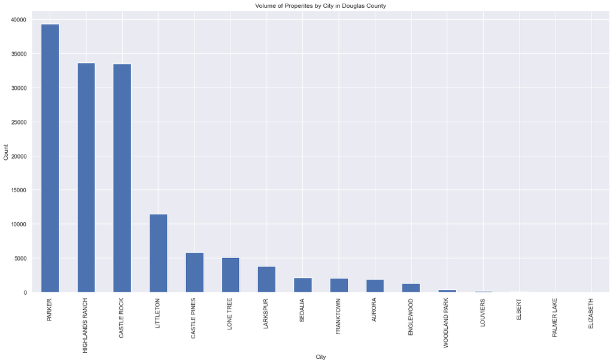

```python
# View visually the numer of accounts by Style
df_loc['City_Name'].value_counts().plot(kind='bar', title = "Volume of Properites by City in Douglas County",
                            xlabel = "City", ylabel = "Count", figsize = (20,10))
plt.show()
```

```python
# Filter the dataframe for \"Residential\" properties - remove commerical types and leave orginal residential detail.
df_loc_res = df_loc[(df_loc['Account_Type_Code'] == 'Residential')]
```

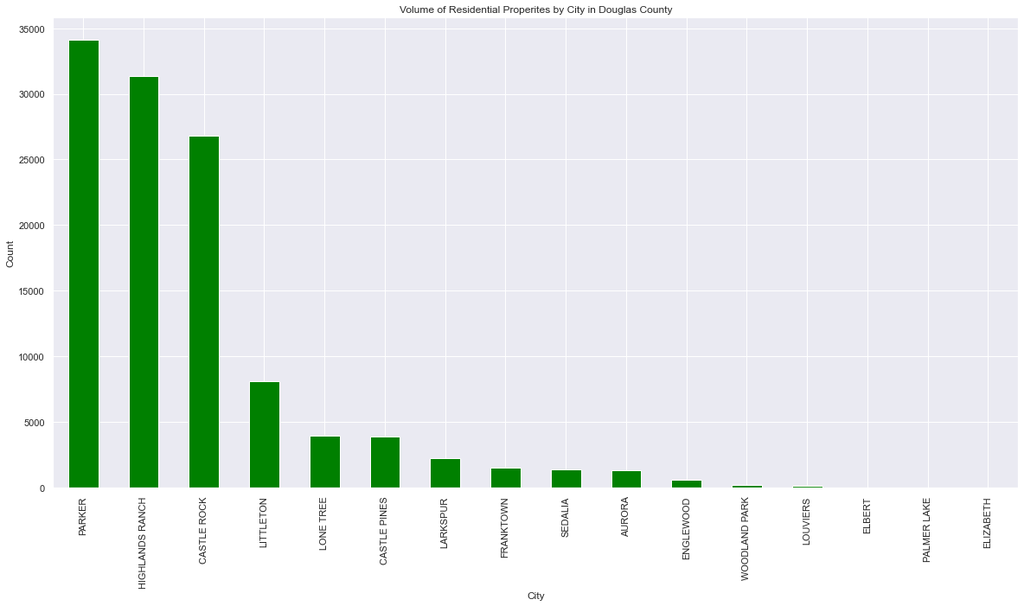

```python
# View visually the numer of accounts by Style
df_loc_res['City_Name'].value_counts().plot(kind='bar',title="Volume of Residential Properites by City in Douglas County",
                                    xlabel = "City", ylabel = "Count", figsize = (20,10), color='green')
plt.show()
```

```python
# View the unique values
df_loc_res['Account_Type_Code'].unique()
```

```
array(['Residential'], dtype=object)
```

```python
# Check for any duplicated records in the dataframe - specific columns
df_loc_res.duplicated(subset=["Account_No"],keep='first').sum()
```

```
58
```

```python
# Check for any duplicated records in the dataframe - specific columns
df_loc_res.duplicated(subset=["Account_No","Unit_No"],keep='first').sum()
```

```
56
```

```python
# Check for any duplicated records in the dataframe - specific columns
df_loc_res.duplicated(subset=["Account_No","Unit_No","Loc_Full_Address"],keep='first').sum()
```

```
0
```

```python
# extract duplicate records
loc_dups = df_loc_res.duplicated(subset=["Account_No"],keep='first')
loc_dups_list = df_loc_res[loc_dups]
loc_dups_list_acctno = loc_dups_list['Account_No']
df_loc_dups_rec = df_loc_res[df_loc_res.Account_No.isin(loc_dups_list_acctno)].sort_values('Account_No')
df_loc_dups_rec.head(60)
```

|  | Account_No | Account_Type_Code | State_Parcel_No | Address_No | Pre_Directional_Code | Street_Name | Street_Type_Code | Unit_No | Location_Zip_Code | City_Name | Legal_Descr | Township | Range | Section | Quarter | Land_Economic_Area_Code | Vacant_Flag | Total_Net_Acres | Tax_District_No | Neighborhood_Code | Neighborhood_Extention | Loc_Full_Address |
| --- | --- | --- | --- | --- | --- | --- | --- | --- | --- | --- | --- | --- | --- | --- | --- | --- | --- | --- | --- | --- | --- | --- |
| 4690 | R0000887 | Residential | 222724000012 | 9765 |  | TITAN | RD | NaN | 80125 | LITTLETON | ALL S & E OF THE S & E ROW LINE OF THE HIGHLINE CANAL OF NORTHERN IRR CO IN THE SW1/4SW1/4 24-6-69 112-117 3.00 AM/L | 24.0 | 6.0 | 69.0 | SW | 9CC | N | 3.000000 | 3468 | 380 | 00 | 9765 TITAN RD ,LITTLETON ,CO,80125 |
| 4691 | R0000887 | Residential | 222724000012 | 9767 |  | TITAN | RD | NaN | 80125 | LITTLETON | ALL S & E OF THE S & E ROW LINE OF THE HIGHLINE CANAL OF NORTHERN IRR CO IN THE SW1/4SW1/4 24-6-69 112-117 3.00 AM/L | 24.0 | 6.0 | 69.0 | SW | 9CC | N | 3.000000 | 3468 | 380 | 00 | 9767 TITAN RD ,LITTLETON ,CO,80125 |
| 7569 | R0042622 | Residential | 250916000008 | 156 |  | BILL DAVIS | RD | NaN | 80116 | FRANKTOWN | PART SE1/4NE1/4NW1/4 PARTT NW1/4NE1/4 16-8-65 18.04 AM/L 162-251 LSP 775 | 16.0 | 8.0 | 65.0 | NE | 9C2 | N | 18.039991 | 118 | 580 | 00 | 156 BILL DAVIS RD ,FRANKTOWN ,CO,80116 |
| 7570 | R0042622 | Residential | 250916000008 | 148 |  | BILL DAVIS | RD | NaN | 80116 | FRANKTOWN | PART SE1/4NE1/4NW1/4 PARTT NW1/4NE1/4 16-8-65 18.04 AM/L 162-251 LSP 775 | 16.0 | 8.0 | 65.0 | NE | 9C2 | N | 18.039991 | 118 | 580 | 00 | 148 BILL DAVIS RD ,FRANKTOWN ,CO,80116 |
| 9488 | R0070990 | Residential | 250511137004 | 106 | N | CANTRIL | ST | NaN | 80104 | CASTLE ROCK | S1/2 LOT 3 & ALL LOT 4 BLK 17 CRAIG & GOULDS ADD TO CSTLE ROCK 0.241 AM/L | 11.0 | 8.0 | 67.0 | NE | 4EE | N | 0.241001 | 215 | 401 | A | 106 N CANTRIL ST ,CASTLE ROCK ,CO,80104 |
| 9489 | R0070990 | Residential | 250511137004 | 110 | N | CANTRIL | ST | NaN | 80104 | CASTLE ROCK | S1/2 LOT 3 & ALL LOT 4 BLK 17 CRAIG & GOULDS ADD TO CSTLE ROCK 0.241 AM/L | 11.0 | 8.0 | 67.0 | NE | 4EE | N | 0.241001 | 215 | 401 | A | 110 N CANTRIL ST ,CASTLE ROCK ,CO,80104 |
| 9537 | R0071503 | Residential | 250511124003 | 316 | N | LEWIS | ST | NaN | 80104 | CASTLE ROCK | LOTS 3 & 4 BLK 10 CRAIG & GOULD'S ADD TO CASTLE ROCK 0.321 AM/L | 11.0 | 8.0 | 67.0 | NE | 4EE | N | 0.321006 | 215 | 401 | A | 316 N LEWIS ST ,CASTLE ROCK ,CO,80104 |
| 9538 | R0071503 | Residential | 250511124003 | 312 | N | LEWIS | ST | NaN | 80104 | CASTLE ROCK | LOTS 3 & 4 BLK 10 CRAIG & GOULD'S ADD TO CASTLE ROCK 0.321 AM/L | 11.0 | 8.0 | 67.0 | NE | 4EE | N | 0.321006 | 215 | 401 | A | 312 N LEWIS ST ,CASTLE ROCK ,CO,80104 |
| 9735 | R0073841 | Residential | 250511132009 | 207 | N | LEWIS | ST | NaN | 80104 | CASTLE ROCK | LOT 9 BLK 14 CRAIG & GOULDS ADD TO CASTLE ROCK 0.161 AM/L | 11.0 | 8.0 | 67.0 | NE | 4EE | N | 0.160996 | 215 | A80 | A | 207 N LEWIS ST ,CASTLE ROCK ,CO,80104 |
| 9736 | R0073841 | Residential | 250511132009 | 209 | N | LEWIS | ST | NaN | 80104 | CASTLE ROCK | LOT 9 BLK 14 CRAIG & GOULDS ADD TO CASTLE ROCK 0.161 AM/L | 11.0 | 8.0 | 67.0 | NE | 4EE | N | 0.160996 | 215 | A80 | A | 209 N LEWIS ST ,CASTLE ROCK ,CO,80104 |
| 9810 | R0074835 | Residential | 250511210008 | 307 |  | JERRY | ST | NaN | 80104 | CASTLE ROCK | LOTS 9 & 10 BLK 17 TOWN OF CASTLE ROCK 0.161 AM/L | 11.0 | 8.0 | 67.0 | NW | 4EE | N | 0.161000 | 3287 | A80 | A | 307 JERRY ST ,CASTLE ROCK ,CO,80104 |
| 9809 | R0074835 | Residential | 250511210008 | 305 |  | JERRY | ST | NaN | 80104 | CASTLE ROCK | LOTS 9 & 10 BLK 17 TOWN OF CASTLE ROCK 0.161 AM/L | 11.0 | 8.0 | 67.0 | NW | 4EE | N | 0.161000 | 3287 | A80 | A | 305 JERRY ST ,CASTLE ROCK ,CO,80104 |
| 9828 | R0075070 | Residential | 250511137001 | 120 | N | CANTRIL | ST | NaN | 80104 | CASTLE ROCK | LOT 1A BLOCK 17 CRAIG & GOULDS ADD TO CASTLE ROCK PER LLV 2013067748 & 2013073771 0.241 AM/L | 11.0 | 8.0 | 67.0 | NE | 4EE | N | 0.241001 | 215 | A80 | B | 120 N CANTRIL ST ,CASTLE ROCK ,CO,80104 |
| 9829 | R0075070 | Residential | 250511137001 | 612 |  | SECOND | ST | NaN | 80104 | CASTLE ROCK | LOT 1A BLOCK 17 CRAIG & GOULDS ADD TO CASTLE ROCK PER LLV 2013067748 & 2013073771 0.241 AM/L | 11.0 | 8.0 | 67.0 | NE | 4EE | N | 0.241001 | 215 | A80 | B | 612 SECOND ST ,CASTLE ROCK ,CO,80104 |
| 10126 | R0078414 | Residential | 250511105004 | 602 |  | FRONT | ST | NaN | 80104 | CASTLE ROCK | LOTS 9, 10, 11, & 12 BLK 1 CRAIG & GOULD'S ADD. TO CASTLE ROCK LESS WEST 30 FT 0.23 AM/L | 11.0 | 8.0 | 67.0 | NE | 4EE | N | 0.230005 | 215 | A80 | A | 602 FRONT ST ,CASTLE ROCK ,CO,80104 |
| 10127 | R0078414 | Residential | 250511105004 | 606 |  | FRONT | ST | NaN | 80104 | CASTLE ROCK | LOTS 9, 10, 11, & 12 BLK 1 CRAIG & GOULD'S ADD. TO CASTLE ROCK LESS WEST 30 FT 0.23 AM/L | 11.0 | 8.0 | 67.0 | NE | 4EE | N | 0.230005 | 215 | A80 | A | 606 FRONT ST ,CASTLE ROCK ,CO,80104 |
| 10128 | R0078422 | Residential | 250511108001 | 516 |  | FRONT | ST | NaN | 80104 | CASTLE ROCK | LOTS 1, 2, 3, 4 & 5 BLK 6 CRAIG & GOULD'S ADD TO CASTLE ROCK LESS WEST 30 FT TO DEPT OF HIGHWAYS 0.273 AM/L | 11.0 | 8.0 | 67.0 | NE | 4EE | N | 0.273003 | 215 | A80 | A | 516 FRONT ST ,CASTLE ROCK ,CO,80104 |
| 10129 | R0078422 | Residential | 250511108001 | 518 |  | FRONT | ST | NaN | 80104 | CASTLE ROCK | LOTS 1, 2, 3, 4 & 5 BLK 6 CRAIG & GOULD'S ADD TO CASTLE ROCK LESS WEST 30 FT TO DEPT OF HIGHWAYS 0.273 AM/L | 11.0 | 8.0 | 67.0 | NE | 4EE | N | 0.273003 | 215 | A80 | A | 518 FRONT ST ,CASTLE ROCK ,CO,80104 |
| 10130 | R0078422 | Residential | 250511108001 | 520 |  | FRONT | ST | NaN | 80104 | CASTLE ROCK | LOTS 1, 2, 3, 4 & 5 BLK 6 CRAIG & GOULD'S ADD TO CASTLE ROCK LESS WEST 30 FT TO DEPT OF HIGHWAYS 0.273 AM/L | 11.0 | 8.0 | 67.0 | NE | 4EE | N | 0.273003 | 215 | A80 | A | 520 FRONT ST ,CASTLE ROCK ,CO,80104 |
| 10286 | R0080282 | Residential | 250511122005 | 521 |  | THIRD | ST | NaN | 80104 | CASTLE ROCK | LOTS 13, 14, 15 & 16 BLK 12 CRAIG & GOULDS ADDITION TO CASTLE ROCK 0.287 AM/L | 11.0 | 8.0 | 67.0 | NE | 4EE | N | 0.287006 | 215 | 401 | A | 521 THIRD ST ,CASTLE ROCK ,CO,80104 |
| 10287 | R0080282 | Residential | 250511122005 | 515 |  | THIRD | ST | NaN | 80104 | CASTLE ROCK | LOTS 13, 14, 15 & 16 BLK 12 CRAIG & GOULDS ADDITION TO CASTLE ROCK 0.287 AM/L | 11.0 | 8.0 | 67.0 | NE | 4EE | N | 0.287006 | 215 | 401 | A | 515 THIRD ST ,CASTLE ROCK ,CO,80104 |
| 10460 | R0082413 | Residential | 250512211004 | 903 |  | SOUTH | ST | NaN | 80104 | CASTLE ROCK | LOT 10 BLK 6 YOUNG'S 4TH 0.28 AM/L | 12.0 | 8.0 | 67.0 | NW | 4FF | N | 0.280005 | 217 | A80 | C | 903 SOUTH ST ,CASTLE ROCK ,CO,80104 |
| 10459 | R0082413 | Residential | 250512211004 | 901 |  | SOUTH | ST | NaN | 80104 | CASTLE ROCK | LOT 10 BLK 6 YOUNG'S 4TH 0.28 AM/L | 12.0 | 8.0 | 67.0 | NW | 4FF | N | 0.280005 | 217 | A80 | C | 901 SOUTH ST ,CASTLE ROCK ,CO,80104 |
| 10467 | R0082510 | Residential | 250511117008 | 411 | N | GILBERT | ST | NaN | 80104 | CASTLE ROCK | LOT 8 & S1/2 LOT 9 BLK 9 CRAIG & GOULD'S ADD TO CASTLE ROCK 0.241 AM/L | 11.0 | 8.0 | 67.0 | NE | 4EE | N | 0.241001 | 215 | 401 | A | 411 N GILBERT ST ,CASTLE ROCK ,CO,80104 |
| 10466 | R0082510 | Residential | 250511117008 | 409 | N | GILBERT | ST | NaN | 80104 | CASTLE ROCK | LOT 8 & S1/2 LOT 9 BLK 9 CRAIG & GOULD'S ADD TO CASTLE ROCK 0.241 AM/L | 11.0 | 8.0 | 67.0 | NE | 4EE | N | 0.241001 | 215 | 401 | A | 409 N GILBERT ST ,CASTLE ROCK ,CO,80104 |
| 10787 | R0086457 | Residential | 260733104002 | 192 |  | COLORADO | AVE | NaN | 80118 | LARKSPUR | LOTS 3 & 4 & PT OF LOT 6 TRACT B LARKSPUR HEIGHTS 0.989 AM/L CP 0086465 | 33.0 | 9.0 | 67.0 | NE | 3FF | N | 0.989004 | 179 | 603 | 00 | 192 COLORADO AVE ,LARKSPUR ,CO,80118 |
| 10788 | R0086457 | Residential | 260733104002 | 170 |  | COLORADO | AVE | NaN | 80118 | LARKSPUR | LOTS 3 & 4 & PT OF LOT 6 TRACT B LARKSPUR HEIGHTS 0.989 AM/L CP 0086465 | 33.0 | 9.0 | 67.0 | NE | 3FF | N | 0.989004 | 179 | 603 | 00 | 170 COLORADO AVE ,LARKSPUR ,CO,80118 |
| 14652 | R0136629 | Residential | 234708000003 | 6305 |  | FLINTWOOD | RD | NaN | 80134 | PARKER | TR 8-7-65 121-58 TOTAL ACREAGE 5.18 AM/L | 8.0 | 7.0 | 65.0 | SE | 9C1 | N | 5.180005 | 324 | 180 | 00 | 6305 FLINTWOOD RD ,PARKER ,CO,80134 |
| 14653 | R0136629 | Residential | 234708000003 | 6237 |  | FLINTWOOD | RD | NaN | 80134 | PARKER | TR 8-7-65 121-58 TOTAL ACREAGE 5.18 AM/L | 8.0 | 7.0 | 65.0 | SE | 9C1 | N | 5.180005 | 324 | 180 | 00 | 6237 FLINTWOOD RD ,PARKER ,CO,80134 |
| 16107 | R0152194 | Residential | 250121001007 | 606 | S | COUNTY HIGHWAY 67 | NaN | NaN | 80135 | SEDALIA | LOT 4 PINE HILLS 2 2.07 AM/L | 21.0 | 8.0 | 69.0 | NW | 70101 | N | 2.069995 | 511 | 701 | 00 | 606 S COUNTY HIGHWAY 67 nan ,SEDALIA ,CO,80135 |
| 16108 | R0152194 | Residential | 250121001007 | 610 | S | COUNTY HIGHWAY 67 | NaN | NaN | 80135 | SEDALIA | LOT 4 PINE HILLS 2 2.07 AM/L | 21.0 | 8.0 | 69.0 | NW | 70101 | N | 2.069995 | 511 | 701 | 00 | 610 S COUNTY HIGHWAY 67 nan ,SEDALIA ,CO,80135 |
| 16396 | R0156136 | Residential | 276731303015 | 15954 |  | WESTCREEK | RD | NaN | 80863 | WOODLAND PARK | LOTS 10 & 11 BLK 5 WESTCREEK LAKES SUB CP 0451864 1.6AM/L | 31.0 | 10.0 | 69.0 | SW | 70106 | Y | 1.600000 | 3140 | Null | Null | 15954 WESTCREEK RD ,WOODLAND PARK ,CO,80863 |
| 16397 | R0156136 | Residential | 276731303015 | 15972 |  | WESTCREEK | RD | NaN | 80863 | WOODLAND PARK | LOTS 10 & 11 BLK 5 WESTCREEK LAKES SUB CP 0451864 1.6AM/L | 31.0 | 10.0 | 69.0 | SW | 70106 | Y | 1.600000 | 3140 | Null | Null | 15972 WESTCREEK RD ,WOODLAND PARK ,CO,80863 |
| 16545 | R0157999 | Residential | 235314402001 | 5612 |  | CURTIS | ST | NaN | 80135 | SEDALIA | LOTS 12 13 & 14 BLK 2 SEDALIA CP 0157981 0.482 AM/L | 14.0 | 7.0 | 68.0 | SE | 3FF | N | 0.482002 | 540 | 601 | A | 5612 CURTIS ST ,SEDALIA ,CO,80135 |
| 16546 | R0157999 | Residential | 235314402001 | 5626 |  | CURTIS | ST | NaN | 80135 | SEDALIA | LOTS 12 13 & 14 BLK 2 SEDALIA CP 0157981 0.482 AM/L | 14.0 | 7.0 | 68.0 | SE | 3FF | N | 0.482002 | 540 | 601 | A | 5626 CURTIS ST ,SEDALIA ,CO,80135 |
| 18684 | R0217779 | Residential | 250511136008 | 109 | N | CANTRIL | ST | NaN | 80104 | CASTLE ROCK | LOT 17A CRAIG & GOULD'S ADD TO CASTLE ROCK 8TH AMD 0.14 AM/L | 11.0 | 8.0 | 67.0 | NE | 4EE | N | 0.144008 | 215 | A80 | B | 109 N CANTRIL ST ,CASTLE ROCK ,CO,80104 |
| 18683 | R0217779 | Residential | 250511136008 | 107 | N | CANTRIL | ST | NaN | 80104 | CASTLE ROCK | LOT 17A CRAIG & GOULD'S ADD TO CASTLE ROCK 8TH AMD 0.14 AM/L | 11.0 | 8.0 | 67.0 | NE | 4EE | N | 0.144008 | 215 | A80 | B | 107 N CANTRIL ST ,CASTLE ROCK ,CO,80104 |
| 20481 | R0256831 | Residential | 250703000002 | 6646 | E | STATE HIGHWAY 86 | NaN | NaN | 80116 | FRANKTOWN | PART NW1/4NE1/4 3-8-66 35.33 AM/L | 3.0 | 8.0 | 66.0 | NE | 9C2 | N | 35.330000 | 118 | 580 | 00 | 6646 E STATE HIGHWAY 86 nan ,FRANKTOWN ,CO,80116 |
| 20482 | R0256831 | Residential | 250703000002 | 6644 | E | STATE HIGHWAY 86 | NaN | NaN | 80116 | FRANKTOWN | PART NW1/4NE1/4 3-8-66 35.33 AM/L | 3.0 | 8.0 | 66.0 | NE | 9C2 | N | 35.330000 | 118 | 580 | 00 | 6644 E STATE HIGHWAY 86 nan ,FRANKTOWN ,CO,80116 |
| 36944 | R0347952 | Residential | 276730300003 | 14634 |  | WESTCREEK | RD | NaN | 80863 | WOODLAND PARK | ALL IN CLARKS ADD TO PEMBERTON: LOTS 1-22 BLK 1 ALL OF BLOCKS 2 3 4 & 6 LOTS 1-16 BLK 7 ALL OF BLOCKS 8 & 9 LOTS 1-10 BLK 10 LOTS 1-10 BLK 11 LOTS 1-15 BLK 12 LOTS 1-11 BLK 13 40 AM/L LSP 4203 4216 | 30.0 | 10.0 | 69.0 | SW | 70105 | N | 40.000000 | 3158 | 701 | 00 | 14634 WESTCREEK RD ,WOODLAND PARK ,CO,80863 |
| 36945 | R0347952 | Residential | 276730300003 | 14570 |  | WESTCREEK | RD | NaN | 80863 | WOODLAND PARK | ALL IN CLARKS ADD TO PEMBERTON: LOTS 1-22 BLK 1 ALL OF BLOCKS 2 3 4 & 6 LOTS 1-16 BLK 7 ALL OF BLOCKS 8 & 9 LOTS 1-10 BLK 10 LOTS 1-10 BLK 11 LOTS 1-15 BLK 12 LOTS 1-11 BLK 13 40 AM/L LSP 4203 4216 | 30.0 | 10.0 | 69.0 | SW | 70105 | N | 40.000000 | 3158 | 701 | 00 | 14570 WESTCREEK RD ,WOODLAND PARK ,CO,80863 |
| 36946 | R0347952 | Residential | 276730300003 | 14760 |  | WESTCREEK | RD | NaN | 80863 | WOODLAND PARK | ALL IN CLARKS ADD TO PEMBERTON: LOTS 1-22 BLK 1 ALL OF BLOCKS 2 3 4 & 6 LOTS 1-16 BLK 7 ALL OF BLOCKS 8 & 9 LOTS 1-10 BLK 10 LOTS 1-10 BLK 11 LOTS 1-15 BLK 12 LOTS 1-11 BLK 13 40 AM/L LSP 4203 4216 | 30.0 | 10.0 | 69.0 | SW | 70105 | N | 40.000000 | 3158 | 701 | 00 | 14760 WESTCREEK RD ,WOODLAND PARK ,CO,80863 |
| 38031 | R0350499 | Residential | 223311012002 | 7200 |  | INSPIRATION | DR | B | 80138 | PARKER | LOT 1 INSPIRATION HILLS 5.97 AM/L | 11.0 | 6.0 | 66.0 | NW | 9BB | N | 5.969995 | 325 | 104 | 00 | 7200 INSPIRATION DR ,PARKER ,CO,80138 |
| 38032 | R0350499 | Residential | 223311012002 | 7200 |  | INSPIRATION | DR | NaN | 80138 | PARKER | LOT 1 INSPIRATION HILLS 5.97 AM/L | 11.0 | 6.0 | 66.0 | NW | 9BB | N | 5.969995 | 325 | 104 | 00 | 7200 INSPIRATION DR ,PARKER ,CO,80138 |
| 48201 | R0372294 | Residential | 223521000027 | 11428 | E | PARKER | RD | NaN | 80138 | PARKER | TRACT IN E1/2SW1/4 21-6-65 36.04 AM/L LSP 2573 & 2956 | 21.0 | 6.0 | 65.0 | SW | 9C1 | N | 36.040000 | 324 | 180 | 00 | 11428 E PARKER RD ,PARKER ,CO,80138 |
| 48202 | R0372294 | Residential | 223521000027 | 11426 | E | PARKER | RD | NaN | 80138 | PARKER | TRACT IN E1/2SW1/4 21-6-65 36.04 AM/L LSP 2573 & 2956 | 21.0 | 6.0 | 65.0 | SW | 9C1 | N | 36.040000 | 324 | 180 | 00 | 11426 E PARKER RD ,PARKER ,CO,80138 |
| 51779 | R0377629 | Residential | 260733104008 | 9216 |  | DOUGLAS | BLVD | NaN | 80118 | LARKSPUR | LOTS 1 & 2 IN TRACT B LARKSPUR HEIGHTS 3.777 AM/L | 33.0 | 9.0 | 67.0 | NE | 3FF | N | 3.776997 | 179 | 603 | 00 | 9216 DOUGLAS BLVD ,LARKSPUR ,CO,80118 |
| 51780 | R0377629 | Residential | 260733104008 | 151 |  | COLUMBINE | ST | NaN | 80118 | LARKSPUR | LOTS 1 & 2 IN TRACT B LARKSPUR HEIGHTS 3.777 AM/L | 33.0 | 9.0 | 67.0 | NE | 3FF | N | 3.776997 | 179 | 603 | 00 | 151 COLUMBINE ST ,LARKSPUR ,CO,80118 |
| 88948 | R0428265 | Residential | 234718000008 | 9698 |  | DEMOCRAT | RD | NaN | 80134 | PARKER | MOST NW1/4SE1/4 18-7-65 39.049 AM/L 104-44, 261-117 THRU 119, 117-450 | 18.0 | 7.0 | 65.0 | SE | 9C1 | N | 39.049000 | 324 | 180 | 00 | 9698 DEMOCRAT RD ,PARKER ,CO,80134 |
| 88947 | R0428265 | Residential | 234718000008 | 9696 |  | DEMOCRAT | RD | NaN | 80134 | PARKER | MOST NW1/4SE1/4 18-7-65 39.049 AM/L 104-44, 261-117 THRU 119, 117-450 | 18.0 | 7.0 | 65.0 | SE | 9C1 | N | 39.049000 | 324 | 180 | 00 | 9696 DEMOCRAT RD ,PARKER ,CO,80134 |
| 95718 | R0437145 | Residential | 250534001020 | 100 |  | BELL MOUNTAIN | PKWY | NaN | 80104 | CASTLE ROCK | LOT 99-A BELL MOUNTAIN RANCH SUBDIVISION FILING 1-A 3RD AMENDMENT PER PLAT CORR 01125466 8.87 AM/L | 34.0 | 8.0 | 67.0 | NW | 9DD | N | 8.870000 | 1823 | 506 | 00 | 100 BELL MOUNTAIN PKWY ,CASTLE ROCK ,CO,80104 |
| 95719 | R0437145 | Residential | 250534001020 | 98 |  | BELL MOUNTAIN | PKWY | NaN | 80104 | CASTLE ROCK | LOT 99-A BELL MOUNTAIN RANCH SUBDIVISION FILING 1-A 3RD AMENDMENT PER PLAT CORR 01125466 8.87 AM/L | 34.0 | 8.0 | 67.0 | NW | 9DD | N | 8.870000 | 1823 | 506 | 00 | 98 BELL MOUNTAIN PKWY ,CASTLE ROCK ,CO,80104 |
| 95720 | R0437145 | Residential | 250534001020 | 96 |  | BELL MOUNTAIN | PKWY | NaN | 80104 | CASTLE ROCK | LOT 99-A BELL MOUNTAIN RANCH SUBDIVISION FILING 1-A 3RD AMENDMENT PER PLAT CORR 01125466 8.87 AM/L | 34.0 | 8.0 | 67.0 | NW | 9DD | N | 8.870000 | 1823 | 506 | 00 | 96 BELL MOUNTAIN PKWY ,CASTLE ROCK ,CO,80104 |
| 96142 | R0438057 | Residential | 223127201036 | 9623 |  | SURREY | DR | NaN | 80108 | CASTLE ROCK | LOT 12A BLOCK B SURREY RIDGE UNIT 2 AS MODIFIED BY LLA 01128789 1.51 AM/L | 27.0 | 6.0 | 67.0 | NW | 9BB | N | 1.510000 | 316 | 304 | 00 | 9623 SURREY DR ,CASTLE ROCK ,CO,80108 |
| 96143 | R0438057 | Residential | 223127201036 | 9627 |  | SURREY | DR | NaN | 80108 | CASTLE ROCK | LOT 12A BLOCK B SURREY RIDGE UNIT 2 AS MODIFIED BY LLA 01128789 1.51 AM/L | 27.0 | 6.0 | 67.0 | NW | 9BB | N | 1.510000 | 316 | 304 | 00 | 9627 SURREY DR ,CASTLE ROCK ,CO,80108 |
| 96144 | R0438057 | Residential | 223127201036 | 9625 |  | SURREY | DR | NaN | 80108 | CASTLE ROCK | LOT 12A BLOCK B SURREY RIDGE UNIT 2 AS MODIFIED BY LLA 01128789 1.51 AM/L | 27.0 | 6.0 | 67.0 | NW | 9BB | N | 1.510000 | 316 | 304 | 00 | 9625 SURREY DR ,CASTLE ROCK ,CO,80108 |
| 96544 | R0438517 | Residential | 250511109017 | 656 |  | SIXTH | ST | NaN | 80104 | CASTLE ROCK | LOT 11A BLOCK 5 CRAIG AND GOULDS ADDITION TO CASTLE ROCK 7TH AMENDMENT 0.17 AM/L | 11.0 | 8.0 | 67.0 | NE | 4EE | N | 0.170000 | 215 | A80 | A | 656 SIXTH ST ,CASTLE ROCK ,CO,80104 |
| 96543 | R0438517 | Residential | 250511109017 | 662 |  | SIXTH | ST | NaN | 80104 | CASTLE ROCK | LOT 11A BLOCK 5 CRAIG AND GOULDS ADDITION TO CASTLE ROCK 7TH AMENDMENT 0.17 AM/L | 11.0 | 8.0 | 67.0 | NE | 4EE | N | 0.170000 | 215 | A80 | A | 662 SIXTH ST ,CASTLE ROCK ,CO,80104 |
| 96546 | R0438518 | Residential | 250511109018 | 678 |  | SIXTH | ST | NaN | 80104 | CASTLE ROCK | LOT 11B BLOCK 5 CRAIG AND GOULDS ADDITION TO CASTLE ROCK 7TH AMENDMENT 0.17 AM/L | 11.0 | 8.0 | 67.0 | NE | 4EE | N | 0.170000 | 215 | A80 | A | 678 SIXTH ST ,CASTLE ROCK ,CO,80104 |
| 96545 | R0438518 | Residential | 250511109018 | 670 |  | SIXTH | ST | NaN | 80104 | CASTLE ROCK | LOT 11B BLOCK 5 CRAIG AND GOULDS ADDITION TO CASTLE ROCK 7TH AMENDMENT 0.17 AM/L | 11.0 | 8.0 | 67.0 | NE | 4EE | N | 0.170000 | 215 | A80 | A | 670 SIXTH ST ,CASTLE ROCK ,CO,80104 |

### Property Owner (Property_Ownership.txt) - 3

```python
# read the text file into a pandas dataframe - files have no headers
df_own=pd.read_csv('C:/Users/edkcb/Documents/MSDS696_Practicum2/Data/Property_Ownership.txt', header=None,low_memory=False)
```

```python
# Set the names of each of the columns as obtained from the Douglas County Asessors Website
# Note - headers are not included in the text file.
df_own.columns = ["Account_No","Owner_Name","Mailing_Address_Line_1","Mailing_Address_Line_2","Mailing_City_Name"
                    ,"Mailing_State","Mailing_Zip_Code"]
```

```python
# View the shape (rows, columns) of the data frame
df_own.shape
```

```
(156734, 7)
```

```python
# View the datatypes in the data frame
df_own.dtypes
```

```
Account_No                object
Owner_Name                object
Mailing_Address_Line_1    object
Mailing_Address_Line_2    object
Mailing_City_Name         object
Mailing_State             object
Mailing_Zip_Code          object
dtype: object
```

```python
# View the first few rows of the owners dataframe
df_own.head()
```

|  | Account_No | Owner_Name | Mailing_Address_Line_1 | Mailing_Address_Line_2 | Mailing_City_Name | Mailing_State | Mailing_Zip_Code |
| --- | --- | --- | --- | --- | --- | --- | --- |
| 0 | C0193439 | MOUNTAIN VIEW ELECTRIC ASSN INC | C/O PROPERTY TAX DEPT | PO BOX 1600 1655 5TH ST | LIMON | CO | 808281600 |
| 1 | C0214025 | INTERMOUNTAIN RURAL ELECTRICASSOCIATION | C/O PROPERTY TAX DEPT | P O DRAWER A | SEDALIA | CO | 80135 |
| 2 | C0214228 | AT&T COMMUNICATIONS | TAX DEPT | P O BOX 7207 2B112A | BEDMINSTER | NJ | 07921 |
| 3 | C0214252 | QWEST CORPORATION | 1025 ELDORADO BLVD | NaN | BROOMFIELD | CO | 800218254 |
| 4 | C0214615 | PUBLIC SERVICE CO OF COLO (XCEL) | TAX SERVICES DEPT | P O BOX 1979 | DENVER | CO | 802011979 |

```python
# View the last few rows of the owners dataframe
df_own.tail()
```

|  | Account_No | Owner_Name | Mailing_Address_Line_1 | Mailing_Address_Line_2 | Mailing_City_Name | Mailing_State | Mailing_Zip_Code |
| --- | --- | --- | --- | --- | --- | --- | --- |
| 156729 | R0612570 | TOWN OF CASTLE ROCK | 100 WILCOX ST | NaN | CASTLE ROCK | CO | 801041907 |
| 156730 | R0612571 | TOWN OF CASTLE ROCK | 100 WILCOX ST | NaN | CASTLE ROCK | CO | 801041907 |
| 156731 | R0612572 | TOWN OF CASTLE ROCK | 100 WILCOX ST | NaN | CASTLE ROCK | CO | 801041907 |
| 156732 | R0612573 | TOWN OF CASTLE ROCK | 100 WILCOX ST | NaN | CASTLE ROCK | CO | 801041907 |
| 156733 | R0612574 | TOWN OF CASTLE ROCK | 100 WILCOX ST | NaN | CASTLE ROCK | CO | 801041907 |

```python
# Check for any duplicated records in the dataframe
df_own.duplicated(subset = ['Account_No'],keep ='first').sum()
```

```
0
```

```python
# View visually the numer of accounts Owner
owners = df_own['Owner_Name'].value_counts().to_frame()
```

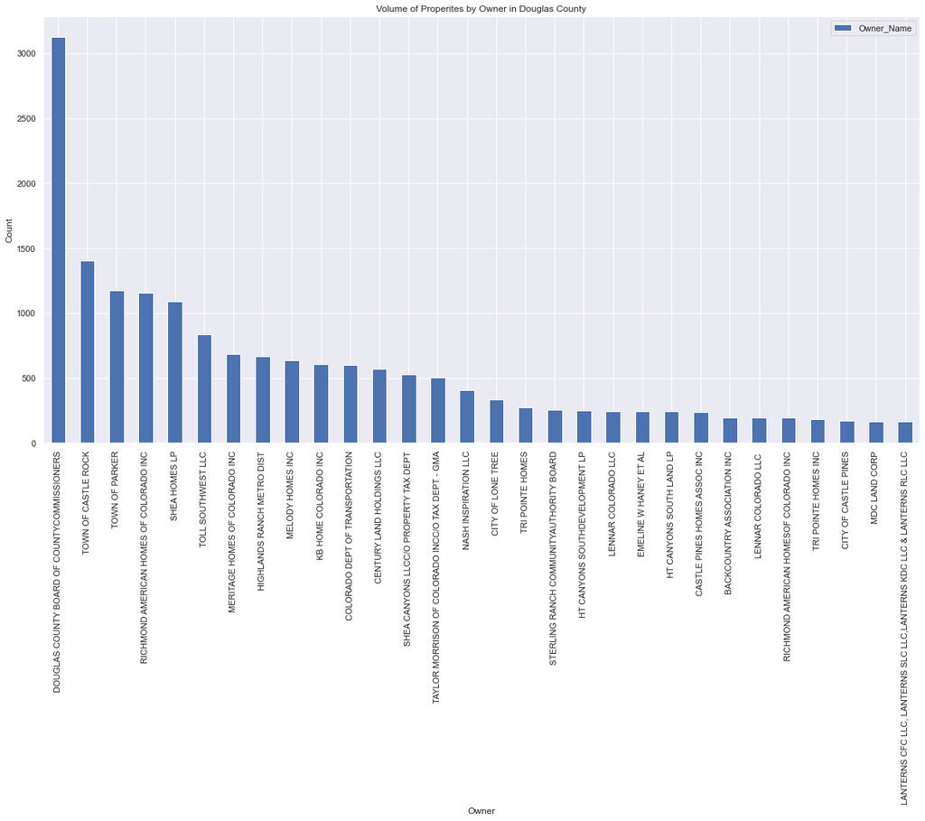

```python
# View the top owners of property in douglas county
owners[0:30].plot(kind='bar', title = "Volume of Properites by Owner in Douglas County",
                  xlabel = "Owner", ylabel = "Count", figsize = (20,10))
```

### Property Subdivision (Property_Subdivision.txt) - 4

```python
# read the text file into a pandas dataframe - files have no headers
df_sub=pd.read_csv('C:/Users/edkcb/Documents/MSDS696_Practicum2/Data/Property_Subdivision.txt',
                   header=None,low_memory=False)
```

```python
# Set the names of each of the columns as obtained from the Douglas County Asessors Website
# Note - headers are not included in the text file.
df_sub.columns = ["Account_No","Sub_Filing_Recording_No","Subdivision_Name","Lot_No","Block_No","Tract_No"]
```

```python
# View the shape (rows, columns) of the data frame
df_sub.shape
```

```
(152280, 6)
```

```python
# View the datatypes of the subdivision dataframe
df_sub.dtypes
```

```
Account_No                 object
Sub_Filing_Recording_No     int64
Subdivision_Name           object
Lot_No                     object
Block_No                   object
Tract_No                   object
dtype: object
```

```python
# Change the datatype to an Object
df_sub['Sub_Filing_Recording_No'] = df_sub['Sub_Filing_Recording_No'].astype('object')
```

```python
# View the first few records
df_sub.head()
```

|  | Account_No | Sub_Filing_Recording_No | Subdivision_Name | Lot_No | Block_No | Tract_No |
| --- | --- | --- | --- | --- | --- | --- |
| 0 | M0211043 | 152884 | WOLHURST | 0 | 0 | 0 |
| 1 | M0211051 | 152884 | WOLHURST | 0 | 0 | 0 |
| 2 | M0211078 | 152884 | WOLHURST | 0 | 0 | 0 |
| 3 | M0211086 | 152884 | WOLHURST | 0 | 0 | 0 |
| 4 | M0211094 | 152884 | WOLHURST | 0 | 0 | 0 |

```python
# View the last few records
df_sub.tail()
```

|  | Account_No | Sub_Filing_Recording_No | Subdivision_Name | Lot_No | Block_No | Tract_No |
| --- | --- | --- | --- | --- | --- | --- |
| 152275 | R0612570 | 2020115852 | LANTERNS | NaN | NaN | T |
| 152276 | R0612571 | 2020115852 | LANTERNS | NaN | NaN | T |
| 152277 | R0612572 | 2020115852 | LANTERNS | NaN | NaN | NaN |
| 152278 | R0612573 | 2020115852 | LANTERNS | NaN | NaN | NaN |
| 152279 | R0612574 | 2020115852 | LANTERNS | NaN | NaN | NaN |

```python
# Check for any duplicated records in the dataframe
df_sub.duplicated(subset = ['Account_No'],keep ='first').sum()
```

```
0
```

```python
# Use Describe to view descriptive statistics on each of the columns.
df_sub.describe(include=['object','float64','int64','datetime64[ns]'])
```

|  | Account_No | Sub_Filing_Recording_No | Subdivision_Name | Lot_No | Block_No | Tract_No |
| --- | --- | --- | --- | --- | --- | --- |
| count | 152280 | 152280 | 152280 | 146430 | 128165 | 14066 |
| unique | 152280 | 4484 | 974 | 4678 | 332 | 612 |
| top | R0386294 | 51 | HIGHLANDS RANCH | 0 | 0 | 0 |
| freq | 1 | 7555 | 32155 | 14634 | 63188 | 4860 |

```python
# View visually the numer of accounts Owner
subs = df_sub['Subdivision_Name'].value_counts().to_frame()
```

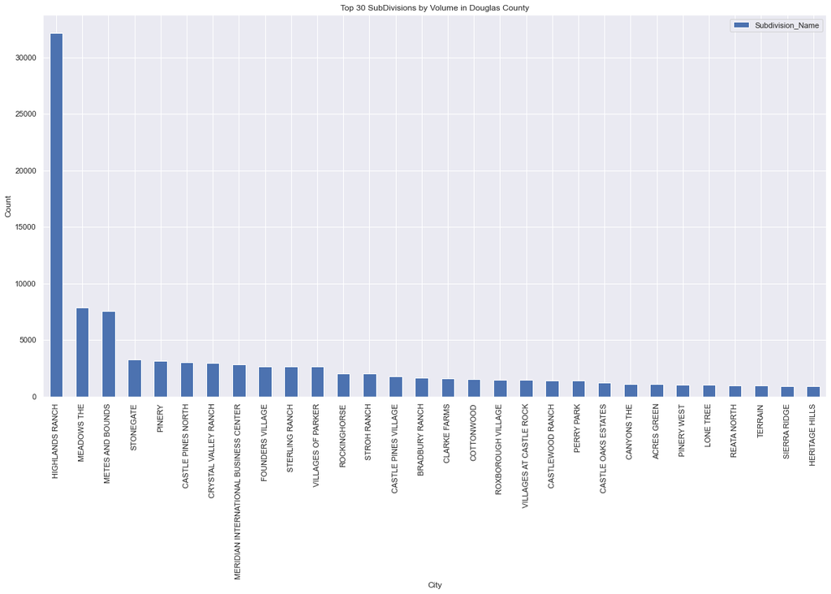

```python
# View the top owners of property in douglas county
subs[0:30].plot(kind='bar', title = "Top 30 SubDivisions by Volume in Douglas County",
                xlabel = "City", ylabel = "Count", figsize = (20,10))
```

### Property Sales (Property_Sales.txt) - 5

```python
# read the text file into a pandas dataframe - files have no headers
df_sale=pd.read_csv('C:/Users/edkcb/Documents/MSDS696_Practicum2/Data/Property_Sales.txt', header=None,low_memory=False)
```

```python
# Set the names of each of the columns as obtained from the Douglas County Asessors Website
# Note - headers are not included in the text file.
df_sale.columns = ["Account_No","Sale_Date","Sale _Price","Deed_Type","Grantor","Grantee","Book","Page","Recording_No"]
```

```python
# View the shape (rows, columns) of the data frame
df_sale.shape
```

```
(587643, 9)
```

```python
# View the columns in the file
df_sale.columns
```

```
Index(['Account_No', 'Sale_Date', 'Sale _Price', 'Deed_Type', 'Grantor',
       'Grantee', 'Book', 'Page', 'Recording_No'],
      dtype='object')
```

```python
# View the datatypes in the file
df_sale.dtypes
```

```
Account_No       object
Sale_Date        object
Sale _Price     float64
Deed_Type        object
Grantor          object
Grantee          object
Book             object
Page             object
Recording_No     object
dtype: object
```

```python
# Modify the datatype for sale date to a date/time
df_sale['Sale_Date']=pd.to_datetime(df_sale['Sale_Date'])
df_sale.dtypes
```

```
Account_No              object
Sale_Date       datetime64[ns]
Sale_Price             float64
Deed_Type               object
Grantor                 object
Grantee                 object
Book                    object
Page                    object
Recording_No            object
dtype: object
```

```python
# Sort the dataframe
df_sale.sort_values(['Account_No','Sale_Date'])
```

|  | Account_No | Sale_Date | Sale_Price | Deed_Type | Grantor | Grantee | Book | Page | Recording_No |
| --- | --- | --- | --- | --- | --- | --- | --- | --- | --- |
| 0 | M0211043 | 2012-08-10 | 55000.0 | Manufactured Home | RUBY L ANDERSON | BRUCE E MILLER & NANCY J MILLER | NaN | NaN | 2013033317 |
| 1 | M0211078 | 2014-07-15 | 45000.0 | Manufactured Home | ROBERT L MOUNT & VIRGINIA M MOUNT | GREGORY CRUM & SHEILA CRUM | NaN | NaN | 2014043178 |
| 2 | M0211086 | 2012-11-08 | 22000.0 | Manufactured Home | ROBERT GOETSCHEL & BILLIE GOETSCHEL | JUDY SMITH | NaN | NaN | 2012085946 |
| 3 | M0211086 | 2014-11-10 | 30000.0 | Manufactured Home | JUDY SMITH | CAROLYN LEE COOKE | NaN | NaN | 2014068250 |
| 4 | M0211107 | 2009-08-28 | 3800.0 | Manufactured Home | SCOTT & MARCIA J MCEACHRON TRUST DATED DEC 98 | DANIEL J HEIMER & KATHLEEN S HEIMER | NaN | NaN | 2009068937 |
| ... | ... | ... | ... | ... | ... | ... | ... | ... | ... |
| 587638 | R0612214 | 2020-01-24 | 0.0 | Bargain & Sale | DFC STERLING RANCH LLC | STERLING RANCH COMMUNITY AUTHORITY BOARD | NaN | NaN | 2020120482 |
| 587639 | R0612215 | 2020-01-24 | 0.0 | Bargain & Sale | DFC STERLING RANCH LLC | STERLING RANCH COMMUNITY AUTHORITY BOARD | NaN | NaN | 2020120482 |
| 587640 | R0612216 | 2020-01-24 | 0.0 | Bargain & Sale | DFC STERLING RANCH LLC | STERLING RANCH COMMUNITY AUTHORITY BOARD | NaN | NaN | 2020120482 |
| 587641 | R0612217 | 2020-01-24 | 0.0 | Bargain & Sale | DFC STERLING RANCH LLC | STERLING RANCH COMMUNITY AUTHORITY BOARD | NaN | NaN | 2020120482 |
| 587642 | R0612218 | 2020-01-24 | 0.0 | Bargain & Sale | DFC STERLING RANCH LLC | STERLING RANCH COMMUNITY AUTHORITY BOARD | NaN | NaN | 2020120482 |

587643 rows × 9 columns

```python
# View the first few rows of the dataframe
df_sale.head()
```

|  | Account_No | Sale_Date | Sale_Price | Deed_Type | Grantor | Grantee | Book | Page | Recording_No |
| --- | --- | --- | --- | --- | --- | --- | --- | --- | --- |
| 0 | M0211043 | 2012-08-10 | 55000.0 | Manufactured Home | RUBY L ANDERSON | BRUCE E MILLER & NANCY J MILLER | NaN | NaN | 2013033317 |
| 1 | M0211078 | 2014-07-15 | 45000.0 | Manufactured Home | ROBERT L MOUNT & VIRGINIA M MOUNT | GREGORY CRUM & SHEILA CRUM | NaN | NaN | 2014043178 |
| 2 | M0211086 | 2012-11-08 | 22000.0 | Manufactured Home | ROBERT GOETSCHEL & BILLIE GOETSCHEL | JUDY SMITH | NaN | NaN | 2012085946 |
| 3 | M0211086 | 2014-11-10 | 30000.0 | Manufactured Home | JUDY SMITH | CAROLYN LEE COOKE | NaN | NaN | 2014068250 |
| 4 | M0211107 | 2009-08-28 | 3800.0 | Manufactured Home | SCOTT & MARCIA J MCEACHRON TRUST DATED DEC 98 | DANIEL J HEIMER & KATHLEEN S HEIMER | NaN | NaN | 2009068937 |

```python
# View the last few rows of the dataframe
df_sale.tail()
```

|  | Account_No | Sale_Date | Sale_Price | Deed_Type | Grantor | Grantee | Book | Page | Recording_No |
| --- | --- | --- | --- | --- | --- | --- | --- | --- | --- |
| 587638 | R0612214 | 2020-01-24 | 0.0 | Bargain & Sale | DFC STERLING RANCH LLC | STERLING RANCH COMMUNITY AUTHORITY BOARD | NaN | NaN | 2020120482 |
| 587639 | R0612215 | 2020-01-24 | 0.0 | Bargain & Sale | DFC STERLING RANCH LLC | STERLING RANCH COMMUNITY AUTHORITY BOARD | NaN | NaN | 2020120482 |
| 587640 | R0612216 | 2020-01-24 | 0.0 | Bargain & Sale | DFC STERLING RANCH LLC | STERLING RANCH COMMUNITY AUTHORITY BOARD | NaN | NaN | 2020120482 |
| 587641 | R0612217 | 2020-01-24 | 0.0 | Bargain & Sale | DFC STERLING RANCH LLC | STERLING RANCH COMMUNITY AUTHORITY BOARD | NaN | NaN | 2020120482 |
| 587642 | R0612218 | 2020-01-24 | 0.0 | Bargain & Sale | DFC STERLING RANCH LLC | STERLING RANCH COMMUNITY AUTHORITY BOARD | NaN | NaN | 2020120482 |

```python
# Use Describe to view descriptive statistics on each of the columns.
df_sale.describe(include=['object','float64','int64','datetime64[ns]'], datetime_is_numeric=True)
```

|  | Account_No | Sale_Date | Sale_Price | Deed_Type | Grantor | Grantee | Book | Page | Recording_No |
| --- | --- | --- | --- | --- | --- | --- | --- | --- | --- |
| count | 587643 | 587643 | 5.876430e+05 | 587643 | 587640 | 587612 | 244195 | 244184 | 587641 |
| unique | 139197 | NaN | NaN | 45 | 277148 | 368680 | 2315 | 3930 | 458507 |
| top | R0393550 | NaN | NaN | Warranty Deed | MISSION VIEJO CO | RICHMOND AMERICAN HOMES OF COLORADO INC | 1470 | 1312 | 9755353 |
| freq | 40 | NaN | NaN | 219627 | 20291 | 8918 | 2934 | 2861 | 2779 |
| mean | NaN | 2004-09-14 05:35:52.398706816 | 6.607664e+05 | NaN | NaN | NaN | NaN | NaN | NaN |
| min | NaN | 1880-07-05 00:00:00 | 0.000000e+00 | NaN | NaN | NaN | NaN | NaN | NaN |
| 25% | NaN | 1997-10-04 00:00:00 | 0.000000e+00 | NaN | NaN | NaN | NaN | NaN | NaN |
| 50% | NaN | 2004-08-06 00:00:00 | 1.839000e+05 | NaN | NaN | NaN | NaN | NaN | NaN |
| 75% | NaN | 2013-05-30 00:00:00 | 3.900000e+05 | NaN | NaN | NaN | NaN | NaN | NaN |
| max | NaN | 2029-11-24 00:00:00 | 2.700000e+08 | NaN | NaN | NaN | NaN | NaN | NaN |
| std | NaN | NaN | 2.605629e+06 | NaN | NaN | NaN | NaN | NaN | NaN |

```python
# Rename columns to remove spaces
df_sale.rename(columns = {'Sale _Price':'Sale_Price'}, inplace = True)
df_sale.columns
```

```
Index(['Account_No', 'Sale_Date', 'Sale_Price', 'Deed_Type', 'Grantor',
       'Grantee', 'Book', 'Page', 'Recording_No'],
      dtype='object')
```

```python
# View the unique values in deed type
df_sale['Deed_Type'].unique()
```

```
array(['Manufactured Home', "Personal Representative's",
       'Re-Recorded Deed', 'Correction Deed', 'Warranty Deed Joint',
       'Warranty Deed', "Public Trustee's Deed", 'Special Warranty Deed',
       'Bargain & Sale', 'Bill of Sale', 'Bargain & Sale Common',
       'Bargain & Sale Joint', "Conservator's Deed", 'Quit Claim',
       'Quit Claim Common', 'Quit Claim Joint', 'Unknown', 'Deed J',
       'Beneficiary Deed', "Personal Representative's Common",
       'Special Warranty Deed Joint', "Trustee's Deed",
       "Treasurer's Deed", "Personal Representative's Joint",
       'Court Decree/Order', 'Warranty Deed Common', 'Court Order',
       'Special Warranty Deed Common', 'Guardian Deed', 'Grant Deed',
       "Administrator's Deed", 'Deed C', "Sheriff's Deed",
       'Certificate of Merger', 'Deed in Lieu of Foreclosure',
       'Grant Deed Common', 'Grant Deed Joint',
       "Public Trustee's Deed Joint", "Public Trustee's Deed Common",
       'Mineral Deed', 'Patent', 'Judgement', 'Contract',
       'Inter-spousal Transfer Deed', 'Right of Way Deed'], dtype=object)
```

```python
# Check for any duplicated records in the dataframe
df_sale.duplicated(subset = ['Account_No'],keep ='first').sum()
```

```
448446
```

```python
# Check for any duplicated records in the dataframe
df_sale.duplicated(subset = ['Account_No','Sale_Date'],keep ='first').sum()
```

```
29239
```

```python
# Check for any duplicated records in the dataframe
df_sale.duplicated(subset = ['Account_No','Sale_Date','Deed_Type',],keep ='first').sum()
```

```
13711
```

```python
# Check for any duplicated records in the dataframe
df_sale.duplicated(subset = ['Account_No','Sale_Date','Deed_Type','Grantor'],keep ='first').sum()
```

```
4573
```

```python
# Check for any duplicated records in the dataframe
df_sale.duplicated(subset = ['Account_No','Sale_Date','Deed_Type','Grantor','Grantee'],keep ='first').sum()
```

```
1681
```

```python
# Check for any duplicated records in the dataframe
df_sale.duplicated(subset = ['Account_No','Sale_Date','Deed_Type','Grantor','Grantee','Sale_Price'],keep ='first').sum()
```

```
1136
```

```python
# Check for any duplicated records in the dataframe
df_sale.duplicated(subset = ['Account_No','Sale_Date','Deed_Type','Grantor','Grantee','Sale_Price','Recording_No'],
                   keep ='first').sum()
```

```
0
```

```python
# Check for any duplicated records in the dataframe
df_sale.duplicated(subset = ['Account_No','Recording_No'], keep ='first').sum()
```

```
0
```

```python
# Create a column for the Number of Sales for that Account/Property
acct_no_sales = df_sale['Account_No'].value_counts().to_frame()
acct_no_sales.reset_index(inplace=True)
acct_no_sales.rename(columns={'Account_No':'No_of_Sales' },inplace = True)
acct_no_sales = acct_no_sales.rename(columns = {'index':'Account_No'})
acct_no_sales
```

|  | Account_No | No_of_Sales |
| --- | --- | --- |
| 0 | R0393550 | 40 |
| 1 | R0337061 | 37 |
| 2 | R0415801 | 34 |
| 3 | R0447909 | 29 |
| 4 | R0447769 | 28 |
| ... | ... | ... |
| 139192 | R0440445 | 1 |
| 139193 | R0607273 | 1 |
| 139194 | R0477179 | 1 |
| 139195 | R0606380 | 1 |
| 139196 | R0479288 | 1 |

139197 rows × 2 columns

```python
# Get the min sales price with associated columns
acct_min_sale = df_sale.loc[df_sale.groupby('Account_No').Sale_Price.idxmin()].reset_index(drop=True)
acct_min_sale_col = acct_min_sale[['Account_No','Sale_Date','Sale_Price']]
acct_min_sale_col.columns = ['Account_No','Sale_Date_toMin','Sale_Price_Min']
acct_min_sale_col
```

|  | Account_No | Sale_Date_toMin | Sale_Price_Min |
| --- | --- | --- | --- |
| 0 | M0211043 | 2012-08-10 | 55000.0 |
| 1 | M0211078 | 2014-07-15 | 45000.0 |
| 2 | M0211086 | 2012-11-08 | 22000.0 |
| 3 | M0211107 | 2009-08-28 | 3800.0 |
| 4 | M0211115 | 2013-10-03 | 0.0 |
| ... | ... | ... | ... |
| 139192 | R0612214 | 2020-01-24 | 0.0 |
| 139193 | R0612215 | 2020-01-24 | 0.0 |
| 139194 | R0612216 | 2020-01-24 | 0.0 |
| 139195 | R0612217 | 2020-01-24 | 0.0 |
| 139196 | R0612218 | 2020-01-24 | 0.0 |

139197 rows × 3 columns

```python
# Get the max sales price with associated columns
acct_max_sale = df_sale.loc[df_sale.groupby('Account_No').Sale_Price.idxmax()]
acct_max_sale_col = acct_max_sale[['Account_No','Sale_Date','Sale_Price']]
acct_max_sale_col.columns = ['Account_No','Sale_Date_toMax','Sale_Price_Max']
acct_max_sale_col
```

|  | Account_No | Sale_Date_toMax | Sale_Price_Max |
| --- | --- | --- | --- |
| 0 | M0211043 | 2012-08-10 | 55000.0 |
| 1 | M0211078 | 2014-07-15 | 45000.0 |
| 3 | M0211086 | 2014-11-10 | 30000.0 |
| 4 | M0211107 | 2009-08-28 | 3800.0 |
| 7 | M0211115 | 2017-08-29 | 63000.0 |
| ... | ... | ... | ... |
| 587638 | R0612214 | 2020-01-24 | 0.0 |
| 587639 | R0612215 | 2020-01-24 | 0.0 |
| 587640 | R0612216 | 2020-01-24 | 0.0 |
| 587641 | R0612217 | 2020-01-24 | 0.0 |
| 587642 | R0612218 | 2020-01-24 | 0.0 |

139197 rows × 3 columns

```python
# Get the original sale date of the property
acct_min_sale_dt = df_sale.loc[df_sale.groupby('Account_No').Sale_Date.idxmin()]
acct_min_sale_dt_col = acct_min_sale_dt[['Account_No','Sale_Date','Sale_Price']]
acct_min_sale_dt_col.columns = ['Account_No','Min_Sale_Date','Sale_Price_toMin']
acct_min_sale_dt_col
```

|  | Account_No | Min_Sale_Date | Sale_Price_toMin |
| --- | --- | --- | --- |
| 0 | M0211043 | 2012-08-10 | 55000.0 |
| 1 | M0211078 | 2014-07-15 | 45000.0 |
| 2 | M0211086 | 2012-11-08 | 22000.0 |
| 4 | M0211107 | 2009-08-28 | 3800.0 |
| 5 | M0211115 | 2013-10-03 | 0.0 |
| ... | ... | ... | ... |
| 587638 | R0612214 | 2020-01-24 | 0.0 |
| 587639 | R0612215 | 2020-01-24 | 0.0 |
| 587640 | R0612216 | 2020-01-24 | 0.0 |
| 587641 | R0612217 | 2020-01-24 | 0.0 |
| 587642 | R0612218 | 2020-01-24 | 0.0 |

139197 rows × 3 columns

```python
# Get the last sale date of the property
acct_max_sale_dt = df_sale.loc[df_sale.groupby('Account_No').Sale_Date.idxmax()]
acct_max_sale_dt_col = acct_max_sale_dt[['Account_No','Sale_Date','Sale_Price']]
acct_max_sale_dt_col.columns = ['Account_No','Max_Sale_Date','Sale_Price_toMax']
acct_max_sale_dt_col
```

|  | Account_No | Max_Sale_Date | Sale_Price_toMax |
| --- | --- | --- | --- |
| 0 | M0211043 | 2012-08-10 | 55000.0 |
| 1 | M0211078 | 2014-07-15 | 45000.0 |
| 3 | M0211086 | 2014-11-10 | 30000.0 |
| 4 | M0211107 | 2009-08-28 | 3800.0 |
| 7 | M0211115 | 2017-08-29 | 63000.0 |
| ... | ... | ... | ... |
| 587638 | R0612214 | 2020-01-24 | 0.0 |
| 587639 | R0612215 | 2020-01-24 | 0.0 |
| 587640 | R0612216 | 2020-01-24 | 0.0 |
| 587641 | R0612217 | 2020-01-24 | 0.0 |
| 587642 | R0612218 | 2020-01-24 | 0.0 |

139197 rows × 3 columns

```python
# Joing the new sale df's into a single df for Sales
df_sale_det = pd.merge((pd.merge((pd.merge((pd.merge(acct_no_sales, acct_min_sale_col, how="left", on="Account_No"))
                    ,acct_max_sale_col, how="left", on="Account_No"))
                    ,acct_min_sale_dt_col, how="left", on="Account_No"))
                    ,acct_max_sale_dt_col, how="left", on="Account_No")
df_sale_det
```

|  | Account_No | No_of_Sales | Sale_Date_toMin | Sale_Price_Min | Sale_Date_toMax | Sale_Price_Max | Min_Sale_Date | Sale_Price_toMin | Max_Sale_Date | Sale_Price_toMax |
| --- | --- | --- | --- | --- | --- | --- | --- | --- | --- | --- |
| 0 | R0393550 | 40 | 2000-04-19 | 0.0 | 1999-08-31 | 875000.0 | 1987-02-05 | 0.0 | 2020-04-02 | 0.0 |
| 1 | R0337061 | 37 | 2018-10-16 | 0.0 | 2018-10-16 | 3100000.0 | 1988-11-21 | 0.0 | 2018-10-16 | 3100000.0 |
| 2 | R0415801 | 34 | 2002-12-27 | 0.0 | 2002-12-20 | 2500000.0 | 1998-12-30 | 480000.0 | 2018-11-30 | 183600.0 |
| 3 | R0447909 | 29 | 2003-09-25 | 0.0 | 2004-04-29 | 2275000.0 | 2003-09-18 | 0.0 | 2020-10-15 | 0.0 |
| 4 | R0447769 | 28 | 2003-09-25 | 0.0 | 2004-07-06 | 3087000.0 | 2003-09-18 | 0.0 | 2020-04-21 | 0.0 |
| ... | ... | ... | ... | ... | ... | ... | ... | ... | ... | ... |
| 139192 | R0440445 | 1 | 2007-12-21 | 490300.0 | 2007-12-21 | 490300.0 | 2007-12-21 | 490300.0 | 2007-12-21 | 490300.0 |
| 139193 | R0607273 | 1 | 2019-09-12 | 5190000.0 | 2019-09-12 | 5190000.0 | 2019-09-12 | 5190000.0 | 2019-09-12 | 5190000.0 |
| 139194 | R0477179 | 1 | 2018-01-18 | 18750000.0 | 2018-01-18 | 18750000.0 | 2018-01-18 | 18750000.0 | 2018-01-18 | 18750000.0 |
| 139195 | R0606380 | 1 | 2019-08-23 | 3734300.0 | 2019-08-23 | 3734300.0 | 2019-08-23 | 3734300.0 | 2019-08-23 | 3734300.0 |
| 139196 | R0479288 | 1 | 2014-03-25 | 970700.0 | 2014-03-25 | 970700.0 | 2014-03-25 | 970700.0 | 2014-03-25 | 970700.0 |

139197 rows × 10 columns

```python
# Check for any duplicated records in the dataframe
df_sale_det.duplicated(subset = ['Account_No'],keep ='first').sum()
```

```
0
```

```python
# Use Describe to view descriptive statistics on each of the columns.
df_sale_det.describe(include=['object','float64','int64','datetime64[ns]'],datetime_is_numeric=True)
```

|  | Account_No | No_of_Sales | Sale_Date_toMin | Sale_Price_Min | Sale_Date_toMax | Sale_Price_Max | Min_Sale_Date | Sale_Price_toMin | Max_Sale_Date | Sale_Price_toMax |
| --- | --- | --- | --- | --- | --- | --- | --- | --- | --- | --- |
| count | 139197 | 139197.000000 | 139197 | 1.391970e+05 | 139197 | 1.391970e+05 | 139197 | 1.391970e+05 | 139197 | 1.391970e+05 |
| unique | 139197 | NaN | NaN | NaN | NaN | NaN | NaN | NaN | NaN | NaN |
| top | R0386294 | NaN | NaN | NaN | NaN | NaN | NaN | NaN | NaN | NaN |
| freq | 1 | NaN | NaN | NaN | NaN | NaN | NaN | NaN | NaN | NaN |
| mean | NaN | 4.221664 | 2005-10-10 17:31:28.876925184 | 4.314810e+05 | 2007-06-21 02:53:00.637529856 | 2.010428e+06 | 1999-10-24 20:32:26.214398848 | 1.496856e+06 | 2012-05-06 08:04:56.075291904 | 7.545203e+05 |
| min | NaN | 1.000000 | 1880-07-05 00:00:00 | 0.000000e+00 | 1880-07-05 00:00:00 | 0.000000e+00 | 1880-07-05 00:00:00 | 0.000000e+00 | 1880-07-05 00:00:00 | 0.000000e+00 |
| 25% | NaN | 2.000000 | 2000-02-15 00:00:00 | 0.000000e+00 | 2000-02-21 00:00:00 | 2.590000e+05 | 1992-11-13 00:00:00 | 2.050000e+04 | 2007-06-05 00:00:00 | 0.000000e+00 |
| 50% | NaN | 4.000000 | 2006-01-05 00:00:00 | 0.000000e+00 | 2007-06-22 00:00:00 | 4.750000e+05 | 1999-10-21 00:00:00 | 2.000000e+05 | 2015-07-27 00:00:00 | 3.059450e+05 |
| 75% | NaN | 6.000000 | 2014-03-26 00:00:00 | 1.958000e+05 | 2016-10-31 00:00:00 | 1.504500e+06 | 2007-02-09 00:00:00 | 8.300000e+05 | 2018-12-03 00:00:00 | 4.937000e+05 |
| max | NaN | 40.000000 | 2029-11-24 00:00:00 | 2.700000e+08 | 2021-01-28 00:00:00 | 2.700000e+08 | 2021-01-27 00:00:00 | 2.700000e+08 | 2029-11-24 00:00:00 | 2.700000e+08 |
| std | NaN | 2.808665 | NaN | 2.676661e+06 | NaN | 4.844156e+06 | NaN | 4.149305e+06 | NaN | 3.482118e+06 |

```python
# Check for the number of "Nan" values in each column of the dataframe
df_sale_det.isna().sum()
```

```
Account_No          0
No_of_Sales         0
Sale_Date_toMin     0
Sale_Price_Min      0
Sale_Date_toMax     0
Sale_Price_Max      0
Min_Sale_Date       0
Sale_Price_toMin    0
Max_Sale_Date       0
Sale_Price_toMax    0
dtype: int64
```

### Property Filings (Property_Filing.txt) - 6

```python
# read the text file into a pandas dataframe - files have no headers
df_file=pd.read_csv('C:/Users/edkcb/Documents/MSDS696_Practicum2/Data/Property_Filing.txt', header=None,low_memory=False)
```

```python
# Set the names of each of the columns as obtained from the Douglas County Asessors Website
# Note - headers are not included in the text file.
df_file.columns = ["Sub_Filing_Recording_No","Subdivision_Name","Filing_No","Filing_Descr"]
```

```python
# View the shape (rows, columns) of the data frame
df_file.shape
```

```
(4871, 4)
```

```python
# View the first few records
df_file.head()
```

|  | Sub_Filing_Recording_No | Subdivision_Name | Filing_No | Filing_Descr |
| --- | --- | --- | --- | --- |
| 0 | 0000001 | SEDALIA TOWN OF | 0 | NaN |
| 1 | 0000002 | PEMBERTON | 0 | NaN |
| 2 | 0000003 | PEMBERTON | 0 | NaN |
| 3 | 0000004 | CRAIG AND GOULDS ADDITION | 0 | NaN |
| 4 | 0000005 | PEMBERTON | 0 | NaN |

```python
# View the last few records
df_file.tail()
```

|  | Sub_Filing_Recording_No | Subdivision_Name | Filing_No | Filing_Descr |
| --- | --- | --- | --- | --- |
| 4866 | 99104313 | PEASLEE MINOR DEVELOPMENT | 1 | NaN |
| 4867 | 99104981 | MERIDIAN INTERNATIONAL BUSINESS CENTER | 6 | NaN |
| 4868 | 99105025 | HIGHLANDS RANCH | 138 | NaN |
| 4869 | 99106546 | STONEGATE | 2 | AMENDMENT 6 |
| 4870 | 99107833 | REWARD CENTER THE | 0 | NaN |

```python
# View the data types in the dataframe
df_file.dtypes
```

```
Sub_Filing_Recording_No    object
Subdivision_Name           object
Filing_No                  object
Filing_Descr               object
dtype: object
```

```python
# Use Describe to view descriptive statistics on each of the columns.
df_file.describe(include=['object','float64','int64','datetime64[ns]'])
```

|  | Sub_Filing_Recording_No | Subdivision_Name | Filing_No | Filing_Descr |
| --- | --- | --- | --- | --- |
| count | 4871 | 4871 | 4871 | 2710 |
| unique | 4871 | 1017 | 475 | 649 |
| top | 2007090968 | HIGHLANDS RANCH | 0 | AMENDMENT 1 |
| freq | 1 | 581 | 1836 | 563 |

```python
# Check for any duplicated records in the dataframe
df_file.duplicated(keep ='first').sum()
```

```
0
```

```python
# Check for any duplicated records in the dataframe by column
df_file.duplicated('Sub_Filing_Recording_No',keep ='first').sum()
```

```
0
```

```python
# View the unique values for a column (subdivision name)
df_file['Subdivision_Name'].unique()
```

```
array(['SEDALIA TOWN OF', 'PEMBERTON', 'CRAIG AND GOULDS ADDITION', ...,
       'VETTERS PIKES PEAK', 'TRAILSIDE VILLAGE', 'REWARD CENTER THE'],
      dtype=object)
```

### Property Values (Property_Values.txt) - 7

```python
# read the text file into a pandas dataframe - files have no headers
df_value=pd.read_csv('C:/Users/edkcb/Documents/MSDS696_Practicum2/Data/Property_Values.txt', header=None,low_memory=False)
```

```python
# Set the names of each of the columns as obtained from the Douglas County Asessors Website
# Note - headers are not included in the text file.
df_value.columns = ["Account_No","Actual_Value","Assessed_Value","Valuation_Class_Code","Valuation_Description"
                    ,"Exempt_Flag","Account_Subtype_Code","Valuation_Type_Code","Account_Type_Code"]
```

```python
# View the shape (rows, columns) of the data frame
df_value.shape
```

```
(281735, 9)
```

```python
# View the first few records
df_value.head()
```

|  | Account_No | Actual_Value | Assessed_Value | Valuation_Class_Code | Valuation_Description | Exempt_Flag | Account_Subtype_Code | Valuation_Type_Code | Account_Type_Code |
| --- | --- | --- | --- | --- | --- | --- | --- | --- | --- |
| 0 | C0193439 | 0.0 | 0.0 | 8451 | RURAL ELECTRIC COMPANIES - PERS | N | State | P | State Assessed |
| 1 | C0193439 | 0.0 | 0.0 | 8251 | RURAL ELECTRIC COMPANIES - REAL | N | State | I | State Assessed |
| 2 | C0214025 | 0.0 | 0.0 | 8451 | RURAL ELECTRIC COMPANIES - PERS | N | State | P | State Assessed |
| 3 | C0214025 | 0.0 | 0.0 | 8251 | RURAL ELECTRIC COMPANIES - REAL | N | State | I | State Assessed |
| 4 | C0214228 | 0.0 | 0.0 | 8240 | GENERAL TELEPHONE AND TELEGRAPH - REAL | N | State | I | State Assessed |

```python
# View the last few records
df_value.tail()
```

|  | Account_No | Actual_Value | Assessed_Value | Valuation_Class_Code | Valuation_Description | Exempt_Flag | Account_Subtype_Code | Valuation_Type_Code | Account_Type_Code |
| --- | --- | --- | --- | --- | --- | --- | --- | --- | --- |
| 281730 | R0612570 | 0.0 | 0.0 | 9999 | DUMMY EXEMPT-INTEGRATION | N | Real | L | Vacant Land |
| 281731 | R0612571 | 0.0 | 0.0 | 9999 | DUMMY EXEMPT-INTEGRATION | N | Real | L | Vacant Land |
| 281732 | R0612572 | 0.0 | 0.0 | 9999 | DUMMY EXEMPT-INTEGRATION | N | Real | L | Vacant Land |
| 281733 | R0612573 | 0.0 | 0.0 | 9999 | DUMMY EXEMPT-INTEGRATION | N | Real | L | Vacant Land |
| 281734 | R0612574 | 0.0 | 0.0 | 9999 | DUMMY EXEMPT-INTEGRATION | N | Real | L | Vacant Land |

```python
# view the data types of the dataframe
df_value.dtypes
```

```
Account_No                object
Actual_Value             float64
Assessed_Value           float64
Valuation_Class_Code      object
Valuation_Description     object
Exempt_Flag               object
Account_Subtype_Code      object
Valuation_Type_Code       object
Account_Type_Code         object
dtype: object
```

```python
# Use Describe to view descriptive statistics on each of the columns.
df_value.describe(include=['object','float64','int64','datetime64[ns]'])
```

|  | Account_No | Actual_Value | Assessed_Value | Valuation_Class_Code | Valuation_Description | Exempt_Flag | Account_Subtype_Code | Valuation_Type_Code | Account_Type_Code |
| --- | --- | --- | --- | --- | --- | --- | --- | --- | --- |
| count | 281735 | 2.817350e+05 | 2.817350e+05 | 281735 | 281735 | 281735 | 281735 | 281735 | 281735 |
| unique | 156482 | NaN | NaN | 306 | 282 | 2 | 3 | 3 | 15 |
| top | R0605376 | NaN | NaN | 1212 | SINGLE FAMILY RES - IMPS | N | Real | L | Residential |
| freq | 7 | NaN | NaN | 102287 | 102287 | 270301 | 277338 | 151946 | 234760 |
| mean | NaN | 2.767647e+05 | 3.054423e+04 | NaN | NaN | NaN | NaN | NaN | NaN |
| std | NaN | 1.357757e+06 | 3.527846e+05 | NaN | NaN | NaN | NaN | NaN | NaN |
| min | NaN | 0.000000e+00 | 0.000000e+00 | NaN | NaN | NaN | NaN | NaN | NaN |
| 25% | NaN | 8.041700e+04 | 6.190000e+03 | NaN | NaN | NaN | NaN | NaN | NaN |
| 50% | NaN | 1.422010e+05 | 1.520000e+04 | NaN | NaN | NaN | NaN | NaN | NaN |
| 75% | NaN | 3.647425e+05 | 2.683000e+04 | NaN | NaN | NaN | NaN | NaN | NaN |
| max | NaN | 2.350649e+08 | 6.816883e+07 | NaN | NaN | NaN | NaN | NaN | NaN |

```python
# Check for any duplicated records in the dataframe
df_value.duplicated(subset = ['Account_No'],keep ='first').sum()
```

```
125253
```

```python
# Check for any duplicated records in the dataframe
df_value.duplicated(subset = ['Account_No','Valuation_Type_Code'],keep ='first').sum()
```

```
5741
```

```python
# Check for any duplicated records in the dataframe
df_value.duplicated(subset = ['Account_No','Valuation_Type_Code','Account_Type_Code'],keep ='first').sum()
```

```
5741
```

```python
# Check for any duplicated records in the dataframe
df_value.duplicated(subset = ['Account_No','Valuation_Type_Code','Account_Type_Code','Account_Subtype_Code'],
                    keep ='first').sum()
```

```
5741
```

```python
# Check for any duplicated records in the dataframe
df_value.duplicated(subset = ['Account_No','Valuation_Type_Code','Account_Type_Code','Account_Subtype_Code',
                              'Valuation_Class_Code'], keep ='first').sum()
```

```
3
```

```python
# Check for any duplicated records in the dataframe
df_value.duplicated(subset = ['Account_No','Valuation_Type_Code','Account_Type_Code','Account_Subtype_Code',
                              'Valuation_Class_Code', 'Exempt_Flag','Valuation_Description'], keep ='first').sum()
```

```
3
```

```python
# Check for any duplicated records in the dataframe
df_value.duplicated(subset = ['Account_No','Valuation_Type_Code','Account_Type_Code','Account_Subtype_Code',
                              'Valuation_Class_Code', 'Exempt_Flag','Valuation_Description','Assessed_Value'],
                    keep ='first').sum()
```

```
0
```

```python
# Check for any duplicated records in the dataframe
df_value.duplicated(subset = ['Account_No','Valuation_Class_Code','Assessed_Value'],
                    keep ='first').sum()
```

```
0
```

```python
# view the column names of the dataframe
df_value.columns
```

```
Index(['Account_No', 'Actual_Value', 'Assessed_Value', 'Valuation_Class_Code',
       'Valuation_Description', 'Exempt_Flag', 'Account_Subtype_Code',
       'Valuation_Type_Code', 'Account_Type_Code'],
      dtype='object')
```

```python
# View the unique values of the column
df_value['Account_Type_Code'].unique()
```

```
array(['State Assessed', 'Mobile Home', 'Exempt', 'Personal', 'Leasing',
       'Vacant Land', 'Residential', 'Industrial', 'Commercial',
       'Severed Int', 'Agricultural', 'HOA', 'Producing Mine',
       'Utilities', 'Possessory Int'], dtype=object)
```

```python
# View the unique values of the column
df_value['Account_Subtype_Code'].unique()
```

```
array(['State', 'Real', 'Personal'], dtype=object)
```

```python
# View the unique values of the column
df_value['Valuation_Description'].unique()
```

```
array(['RURAL ELECTRIC COMPANIES - PERS',
       'RURAL ELECTRIC COMPANIES - REAL',
       'GENERAL TELEPHONE AND TELEGRAPH - REAL',
       'GENERAL TELEPHONE & TELEGRAPH - PERS',
       'ELECTRIC COMPANIES - REAL', 'ELECTRIC COMPANIES - PERS',
       'GAS TRANSMISSION PIPELINE - PERS',
       'GAS TRANSMISSION PIPELINE - REAL',
       'RAIL CAR LINE COMPANIES - REAL', 'RAIL CAR LINE COMPANIES - PERS',
       'PETROCHEMICAL PIPELINE COMPANIES - PERS',
       'PETROCHEMICAL PIPELINE COMPANIES - REAL',
       'INDEPENDENT TELEPHONE COMPANIES - REAL',
       'INDEPENDENT TELEPHONE COMPANIES - PERS',
       'RADIO MOBILE TELEPHONE COMPANIES - REAL',
       'RADIO MOBILE TELEPHONE COMPANIES - PERS',
       'AIRLINE COMPANIES - REAL', 'AIRLINE COMPANIES - PERS',
       'TOTAL TELEPHONE & TELEGRAPH - PERS',
       'TOTAL TELEPHONE & TELEGRAPH - REAL',
       'COMMON CARRIERS REGULAR PROPERTY - REAL',
       'COMMON CARRIERS REGULAR PROPERTY - PERS', 'TELEPHONE RESELLERS',
       'MFG HOUSING (M.H.) - IMPROVEMENTS',
       'RELIGIOUS - IMPS - RESIDENTIAL',
       'MFG HOUSING (MOBILE HOME) AG IMPS',
       'MISCELLANEOUS - IMPROVEMENTS', 'CAMP/RETREAT - IMPROVEMENTS',
       'INDUST EQUIPFURNMACHINERY - PERSONAL',
       'COMM EQUIPFURNMACH - PERS', 'RESIDENTIAL - PERSONAL PROPERTY',
       'FRATERNAL/VETRANS - PP', 'FIRE WATER & SAN. - PERSONAL PROPERTY',
       'CAMP/RETREAT - PP', 'MISCELLANEOUS - PERSONAL PROPERTY',
       'TOWN - PERSONAL PROPERTY', 'CHURCH - PP',
       'ELEMENTARY/SECONDARY - PERSONAL PROPERTY',
       'TOTAL CHARITABLE - PERSONAL PROPERTY',
       'CHARITABLE - PP - RESIDENTIAL',
       'SENIOR CITIZEN DISABLED HOUSING - PP',
       'RELIGIOUS PURPOSES - MISCELLANEOUS - PP',
       'TOTAL COUNTY - PERSONAL PROPERTY', 'HEALTH CARE FACILITY - PP',
       'HOUSING INTEGRAL PART/NO ANNUAL % - PP', 'RELIGIOUS SCHOOL - PP',
       'TOTAL CHURCH - PERSONAL PROPERTY',
       'PARKS & REC. - PERSONAL PROPERTY',
       'CREDIT UNION - PERSONAL PROPERTY',
       'COMMUNITY CORRECTIONS - PERSONAL PROP.',
       'FAMILY SERVICE FACILITY - PERSONAL PROP.',
```

[output cut: 130 more lines]

```
       'PART OF VAC LAND, 10 AC. TO LESS 35 AC.',
       'HOMEOWNERS WAREHOUSE STORAGE IMPS',
       'HOMEOWNERS WAREHOUSE STORAGE LAND',
       'TRACT, INDUST. PLATTED, POTENT. DEVELOP.',
       'REFINING/PETROLEUM - IMPROVEMENTS', 'REFINING/PETROLEUM - LAND',
       'AM.SPORTS ORG. - LAND', 'PART OF MULTI-UNITS (9 & UP) - LAND',
       'TOTAL OTHER - IMPROVEMENTS',
       'OTHER COMMERCIAL - POSSESSORY INTEREST', 'PART OF LODGING - LAND',
       'PART OF FIRE, WATER & SAN - LAND',
       'ROAD & BRIDGE DEPT - IMPROVEMENTS',
       'AIRPORT - POSSESSORY INTEREST', 'PART OF INDUSTRIAL VACANT LOTS',
       'RESIDENTIAL - POSSESSORY INTEREST',
       'AM.SPORTS ORG. - IMPROVEMENTS',
       'PART OF CONTRACTING/SERVICE - LAND', 'CONDO VACANT LOTS',
       'DUMMY LAND-INTEGRATION', 'DUMMY EXEMPT-INTEGRATION'], dtype=object)
```

```python
# View unique values in valuation type
df_value['Valuation_Type_Code'].unique()
```

```
array(['P', 'I', 'L'], dtype=object)
```

```python
# Filter to specific rows based on a column value (Residential records)
df_val_res = df_value[(df_value['Account_Type_Code'] == 'Residential')
                            & (df_value['Valuation_Description'] == ('SINGLE FAMILY RES - IMPS'))]

df_val_res.shape
```

```
(102016, 9)
```

```python
# View the unique values of the column
df_val_res['Valuation_Description'].unique()
```

```
array(['SINGLE FAMILY RES - IMPS'], dtype=object)
```

```python
# View unique values in account subtype
df_val_res['Account_Subtype_Code'].unique()
```

```
array(['Real'], dtype=object)
```

```python
# I = Improvement, P = Property, L = Land
df_val_res['Valuation_Type_Code'].unique()
```

```
array(['I'], dtype=object)
```

```python
# Check for any duplicated records in the dataframe
df_val_res.duplicated(subset = ['Account_No'],keep ='first').sum()
```

```
0
```

```python
# Use Describe to view descriptive statistics on each of the columns.
df_val_res.describe(include=['object','float64','int64','datetime64[ns]'])
```

|  | Account_No | Actual_Value | Assessed_Value | Valuation_Class_Code | Valuation_Description | Exempt_Flag | Account_Subtype_Code | Valuation_Type_Code | Account_Type_Code |
| --- | --- | --- | --- | --- | --- | --- | --- | --- | --- |
| count | 102016 | 1.020160e+05 | 102016.000000 | 102016 | 102016 | 102016 | 102016 | 102016 | 102016 |
| unique | 102016 | NaN | NaN | 1 | 1 | 1 | 1 | 1 | 1 |
| top | R0386294 | NaN | NaN | 1212 | SINGLE FAMILY RES - IMPS | N | Real | I | Residential |
| freq | 1 | NaN | NaN | 102016 | 102016 | 102016 | 102016 | 102016 | 102016 |
| mean | NaN | 4.261631e+05 | 30470.663425 | NaN | NaN | NaN | NaN | NaN | NaN |
| std | NaN | 1.828258e+05 | 13072.050260 | NaN | NaN | NaN | NaN | NaN | NaN |
| min | NaN | 0.000000e+00 | 0.000000 | NaN | NaN | NaN | NaN | NaN | NaN |
| 25% | NaN | 3.264375e+05 | 23340.000000 | NaN | NaN | NaN | NaN | NaN | NaN |
| 50% | NaN | 3.861085e+05 | 27610.000000 | NaN | NaN | NaN | NaN | NaN | NaN |
| 75% | NaN | 4.686418e+05 | 33510.000000 | NaN | NaN | NaN | NaN | NaN | NaN |
| max | NaN | 7.560927e+06 | 540610.000000 | NaN | NaN | NaN | NaN | NaN | NaN |

```python
# Check for the number of "Nan" values in each column of the dataframe
df_val_res.isna().sum()
```

```
Account_No               0
Actual_Value             0
Assessed_Value           0
Valuation_Class_Code     0
Valuation_Description    0
Exempt_Flag              0
Account_Subtype_Code     0
Valuation_Type_Code      0
Account_Type_Code        0
dtype: int64
```

## Merge Assessors data text files

###### Step 1 - Manipulations of the data to prepare for Join/Merge"

```python
# View shape of dataframe
df_PI_sfres_det.shape
```

```
(102136, 32)
```

```python
# View shape of dataframe
df_loc_res.shape
```

```
(116131, 22)
```

```python
# View shape of dataframe
df_own.shape
```

```
(156734, 7)
```

```python
# View shape of dataframe
df_sub.shape
```

```
(152280, 6)
```

```python
# View shape of dataframe
df_sale_det.shape
```

```
(139197, 10)
```

```python
# View shape of dataframe
df_file.shape
```

```
(4871, 4)
```

```python
# View shape of dataframe
df_val_res.shape
```

```
(102016, 9)
```

```python
# Filter the dataframe for non "Residential" properties
df_loc_nonres = df_loc[(df_loc['Account_Type_Code'] != 'Residential')]
df_loc_nonres_acctno = df_loc_nonres['Account_No']

# Identify the Single Family Residential Properties that are not residential
df_PI_nonres = df_PI_sfres_det[df_PI_sfres_det.Account_No.isin(df_loc_nonres_acctno)]
df_PI_nonres.shape
```

```
(260, 32)
```

```python
# View the last few records
df_PI_nonres.sort_values('Building_ID').tail()
```

|  | Account_No | Building_ID | Built_As_code | Built_As | Quality_Code | Improvement_Type_Code | Completion_Percent | Unit_Type | No_of_Fireplace | Total_Garage_SF | Walkout_Basement_Flag | Total_Porch_SF | Total_Finished_Basement_SF | Total_Unfinished_Basement_SF | Roof_Construction_Type | Built_as_SF | Exterior_Construction | Interior_Construction | No_of_Story | Roof_Material_Code | Floor_Material_Type_Code | No_of_Bedrooms | No_of_Bathrooms | Built_Year | Remodeled_Year | Length_of_Mobile_Home | Width_of_Mobile_Home | Average_Story_Height | No_Of_Unit | … |
| --- | --- | --- | --- | --- | --- | --- | --- | --- | --- | --- | --- | --- | --- | --- | --- | --- | --- | --- | --- | --- | --- | --- | --- | --- | --- | --- | --- | --- | --- | --- |
| 117942 | R0482022 | 37.0 | 1 | Ranch 1 Story | Average | 1636 | 100.0 | End | 1 | 400 | N | 270 | 0 | 1636 | Gable | 1636 | Frame Siding | Drywall | 1.0 | Composition Shingle | Allowance | 2.0 | 2.0 | 2008 | 0.0 | 0.0 | 0.0 | 9.0 | 1.0 | … |
| 117943 | R0482022 | 38.0 | 1 | Ranch 1 Story | Average | 1636 | 100.0 | End | 1 | 400 | N | 270 | 1157 | 479 | Gable | 1636 | Frame Siding | Drywall | 1.0 | Composition Shingle | Allowance | 2.0 | 2.0 | 2008 | 0.0 | 0.0 | 0.0 | 9.0 | 1.0 | … |
| 117944 | R0482022 | 39.0 | 1 | Ranch 1 Story | Average | 1600 | 100.0 | End | 1 | 400 | N | 245 | 1151 | 449 | Gable | 1600 | Frame Siding | Drywall | 1.0 | Composition Shingle | Allowance | 2.0 | 2.0 | 2008 | 0.0 | 0.0 | 0.0 | 9.0 | 1.0 | … |
| 117946 | R0482022 | 41.0 | 1 | Ranch 1 Story | Average | 1641 | 100.0 | End | 1 | 400 | N | 275 | 1136 | 505 | Gable | 1641 | Frame Siding | Drywall | 1.0 | Composition Shingle | Allowance | 2.0 | 2.0 | 2008 | 0.0 | 0.0 | 0.0 | 9.0 | 1.0 | … |
| 117947 | R0482022 | 42.0 | 1 | Ranch 1 Story | Average | 1605 | 100.0 | End | 1 | 400 | N | 245 | 0 | 1605 | Gable | 1605 | Frame Siding | Drywall | 1.0 | Composition Shingle | Allowance | 2.0 | 2.0 | 2007 | 0.0 | 0.0 | 0.0 | 9.0 | 1.0 | … |

```python
# Filter the non residential properties from the PI file
df_PI_sfres_det2 = df_PI_sfres_det[~df_PI_sfres_det.Account_No.isin(df_loc_nonres_acctno)]
```

```python
# View the shape of the dataframe
df_PI_sfres_det2.shape
```

```
(101876, 32)
```

```python
# Check for any duplicated records in the dataframe - specific columns
df_PI_sfres_det2.duplicated(subset=["Account_No"],keep='first').sum()
```

```
204
```

```python
# Review PI accounts that have duplicate addresses in loc
df_PI_sfres_det_rvw = df_PI_sfres_det2[df_PI_sfres_det2.Account_No.isin(loc_dups_list_acctno)]
df_PI_sfres_det_rvw
```

|  | Account_No | Building_ID | Built_As_code | Built_As | Quality_Code | Improvement_Type_Code | Completion_Percent | Unit_Type | No_of_Fireplace | Total_Garage_SF | Walkout_Basement_Flag | Total_Porch_SF | Total_Finished_Basement_SF | Total_Unfinished_Basement_SF | Roof_Construction_Type | Built_as_SF | Exterior_Construction | Interior_Construction | No_of_Story | Roof_Material_Code | Floor_Material_Type_Code | No_of_Bedrooms | No_of_Bathrooms | Built_Year | Remodeled_Year | Length_of_Mobile_Home | Width_of_Mobile_Home | Average_Story_Height | No_Of_Unit | … |
| --- | --- | --- | --- | --- | --- | --- | --- | --- | --- | --- | --- | --- | --- | --- | --- | --- | --- | --- | --- | --- | --- | --- | --- | --- | --- | --- | --- | --- | --- | --- |
| 304 | R0000887 | 1.0 | 5 | 1 1/2 Story Fin | Average | 990 | 100.0 | NaN | 0 | 480 | N | 192 | 0 | 0 | NaN | 990 | Masonry Concrete Block | Drywall | 2.0 | Composition Shingle | Allowance | 2.0 | 2.0 | 1954 | 1961.0 | 0.0 | 0.0 | 8.0 | 1.0 | … |
| 305 | R0000887 | 2.0 | 21 | Modular | Low | 1152 | 100.0 | NaN | 0 | 0 | N | 112 | 0 | 0 | Flat | 1152 | Frame Siding | Paneling | 1.0 | Preformed Metal | Allowance | 3.0 | 1.0 | 1970 | 0.0 | 48.0 | 24.0 | 8.0 | 1.0 | … |
| 3019 | R0042622 | 1.0 | 1 | Ranch 1 Story | Good | 2394 | 100.0 | NaN | 1 | 864 | Y | 596 | 1074 | 898 | Gable | 2394 | Frame Masonry Veneer | Drywall | 1.0 | Composition Shingle | Allowance | 4.0 | 3.0 | 1996 | 2015.0 | 0.0 | 0.0 | 8.0 | 1.0 | … |
| 3021 | R0042622 | 3.0 | 8 | 2 Story | Good | 1450 | 100.0 | NaN | 1 | 1152 | Y | 105 | 943 | 40 | Gable | 1450 | Frame Siding | Drywall | 2.0 | Composition Shingle | Allowance | 2.0 | 2.0 | 1999 | 2006.0 | 0.0 | 0.0 | 8.0 | 1.0 | … |
| 5947 | R0070990 | 1.0 | 8 | 2 Story | Average | 1924 | 100.0 | NaN | 1 | 891 | N | 362 | 0 | 1146 | NaN | 1924 | Frame Masonry Veneer | Drywall | 2.0 | Composition Shingle | Allowance | 4.0 | 3.0 | 1913 | 1960.0 | 0.0 | 0.0 | 8.0 | 1.0 | … |
| 5998 | R0071503 | 1.0 | 1 | Ranch 1 Story | Average | 700 | 100.0 | NaN | 0 | 0 | N | 194 | 0 | 700 | Gable | 700 | Frame Siding | Drywall | 1.0 | Composition Shingle | Allowance | 2.0 | 1.0 | 1927 | 2017.0 | 0.0 | 0.0 | 8.0 | 1.0 | … |
| 5999 | R0071503 | 2.0 | 8 | 2 Story | Average | 1920 | 100.0 | NaN | 0 | 1488 | N | 0 | 0 | 0 | Shed | 1920 | Frame Siding | Drywall | 2.0 | Composition Shingle | Allowance | 3.0 | 3.0 | 1982 | 2017.0 | 0.0 | 0.0 | 8.0 | 1.0 | … |
| 6264 | R0074835 | 3.0 | 6 | 1 1/2 Story Unfin | Average | 528 | 100.0 | NaN | 0 | 0 | N | 0 | 0 | 0 | Gable | 528 | Frame Siding | Drywall | 2.0 | Preformed Metal | Allowance | 2.0 | 1.0 | 1902 | 1990.0 | 0.0 | 0.0 | 8.0 | 1.0 | … |
| 6746 | R0080282 | 1.0 | 5 | 1 1/2 Story Fin | Average | 2240 | 100.0 | NaN | 0 | 480 | N | 364 | 0 | 1092 | Gable | 2240 | Frame Siding | Drywall | 2.0 | Composition Shingle | Allowance | 4.0 | 2.0 | 1927 | 1965.0 | 0.0 | 0.0 | 8.0 | 1.0 | … |
| 6930 | R0082510 | 1.0 | 1 | Ranch 1 Story | Average | 1586 | 100.0 | NaN | 0 | 504 | N | 0 | 0 | 1082 | NaN | 1586 | Frame Siding | Drywall | 1.0 | Composition Shingle | Allowance | 4.0 | 2.0 | 1960 | 1970.0 | NaN | NaN | 8.0 | 1.0 | … |
| 7238 | R0086457 | 1.0 | 1 | Ranch 1 Story | Fair | 768 | 100.0 | NaN | 1 | 0 | N | 216 | 0 | 0 | Gable | 768 | Frame Siding | Plaster | 1.0 | Composition Roll | Allowance | 2.0 | 1.0 | 1917 | 1943.0 | 0.0 | 0.0 | 8.0 | 1.0 | … |
| 7239 | R0086457 | 2.0 | 10 | Cabin | Fair | 664 | 100.0 | NaN | 0 | 0 | N | 320 | 0 | 0 | Gable | 664 | Pine Finished Cabin | NaN | 1.0 | Composition Shingle | Allowance | 1.0 | 1.0 | 1917 | 0.0 | 0.0 | 0.0 | 8.0 | 1.0 | … |
| 12785 | R0136629 | 1.0 | 1 | Ranch 1 Story | Average | 739 | 100.0 | NaN | 0 | 0 | N | 0 | 0 | 0 | Gable | 739 | Frame Stucco | Drywall | 1.0 | Composition Shingle | Allowance | 2.0 | 1.0 | 1949 | 2010.0 | 0.0 | 0.0 | 8.0 | 1.0 | … |
| 12786 | R0136629 | 2.0 | 1 | Ranch 1 Story | Average | 1060 | 100.0 | NaN | 1 | 870 | Y | 756 | 833 | 228 | Hip | 1060 | Frame Masonry Veneer | Drywall | 1.0 | Composition Shingle | Allowance | 3.0 | 2.0 | 1962 | 2010.0 | 0.0 | 0.0 | 8.0 | 1.0 | … |
| 14457 | R0152194 | 1.0 | 1 | Ranch 1 Story | Average | 1865 | 100.0 | NaN | 1 | 522 | N | 269 | 0 | 0 | Gable | 1865 | Frame Siding | Drywall | 1.0 | Composition Shingle | Allowance | 4.0 | 2.0 | 1973 | 2000.0 | 0.0 | 0.0 | 8.0 | 1.0 | … |
| 14458 | R0152194 | 2.0 | 11 | A Frame | Average | 921 | 100.0 | NaN | 0 | 0 | N | 42 | 0 | 0 | Gable | 921 | Pine A-Frame | Drywall | 2.0 | Composition Shingle | Allowance | 2.0 | 1.0 | 1977 | 1985.0 | 0.0 | 0.0 | 8.0 | 1.0 | … |
| 14800 | R0157999 | 1.0 | 1 | Ranch 1 Story | Average | 1280 | 100.0 | NaN | 0 | 0 | N | 513 | 0 | 0 | NaN | 1280 | Frame Siding | Drywall | 1.0 | Composition Shingle | Allowance | 2.0 | 1.0 | 1971 | 0.0 | 0.0 | 0.0 | 8.0 | 1.0 | … |
| 14801 | R0157999 | 2.0 | 1 | Ranch 1 Story | Fair | 420 | 100.0 | NaN | 0 | 0 | N | 0 | 0 | 0 | NaN | 420 | Frame Siding | Drywall | 1.0 | Composition Shingle | Allowance | 1.0 | 1.0 | 1950 | 1955.0 | 0.0 | 0.0 | 8.0 | 1.0 | … |
| 19568 | R0256831 | 1.0 | 5 | 1 1/2 Story Fin | Fair | 1356 | 100.0 | NaN | 0 | 0 | N | 354 | 0 | 0 | NaN | 1356 | Frame Siding | Drywall | 2.0 | Composition Shingle | Allowance | 2.0 | 1.0 | 1888 | 1985.0 | 0.0 | 0.0 | 8.0 | 1.0 | … |
| 19569 | R0256831 | 2.0 | 1 | Ranch 1 Story | Fair | 744 | 100.0 | NaN | 0 | 0 | N | 0 | 0 | 0 | Gable | 744 | Frame Stucco | Plaster | 1.0 | Composition Shingle | Allowance | 0.0 | 1.0 | 1888 | 1990.0 | 0.0 | 0.0 | 8.0 | 1.0 | … |
| 35849 | R0350499 | 1.0 | 8 | 2 Story | Very Good | 4277 | 100.0 | NaN | 1 | 693 | Y | 837 | 878 | 379 | NaN | 4277 | Frame Siding | Drywall | 2.0 | Wood Shake | Allowance | 4.0 | 4.0 | 1978 | 0.0 | 0.0 | 0.0 | 8.0 | 1.0 | … |
| 44906 | R0372294 | 1.0 | 8 | 2 Story | Very Good | 4546 | 75.0 | NaN | 1 | 777 | N | 0 | 0 | 2618 | Hip | 4546 | Frame Stone Veneer | Drywall | 2.0 | Concrete Tile | Allowance | 4.0 | 4.0 | 2000 | 0.0 | 0.0 | 0.0 | 10.0 | 1.0 | … |
| 44907 | R0372294 | 2.0 | 8 | 2 Story | Excellent | 15073 | 50.0 | NaN | 2 | 4746 | Y | 16444 | 2670 | 1235 | Hip | 15073 | Frame Stone Veneer | Drywall | 2.0 | Slate | Allowance | 4.0 | 9.0 | 1999 | NaN | 0.0 | 0.0 | 10.0 | 1.0 | … |
| 48331 | R0377629 | 1.0 | 21 | Modular | Average | 1380 | 100.0 | NaN | 0 | 308 | N | 156 | 0 | 0 | Gable | 1380 | Frame Siding | Drywall | 1.0 | Composition Shingle | Allowance | 3.0 | 1.0 | 1979 | 1999.0 | 0.0 | 0.0 | 8.0 | 1.0 | … |
| 48332 | R0377629 | 2.0 | 1 | Ranch 1 Story | Average | 1244 | 100.0 | NaN | 1 | 0 | N | 304 | 0 | 0 | Hip/Gable | 1244 | Frame Siding | Drywall | 1.0 | Composition Shingle | Allowance | 3.0 | 1.0 | 1917 | 1943.0 | 0.0 | 0.0 | 8.0 | 1.0 | … |
| 89411 | R0437145 | 1.0 | 5 | 1 1/2 Story Fin | Average | 1830 | 100.0 | NaN | 1 | 0 | N | 0 | 0 | 120 | Gable | 1830 | Frame Siding | Drywall | 2.0 | Composition Shingle | Allowance | 2.0 | 2.0 | 1918 | 1998.0 | 0.0 | 0.0 | 8.0 | 1.0 | … |
| 89412 | R0437145 | 2.0 | 1 | Ranch 1 Story | Average | 672 | 100.0 | NaN | 0 | 0 | N | 264 | 0 | 672 | Gable | 672 | Frame Masonry Veneer | Drywall | 1.0 | Composition Shingle | Allowance | 2.0 | 1.0 | 1918 | 2000.0 | 0.0 | 0.0 | 8.0 | 1.0 | … |
| 89856 | R0438057 | 3.0 | 8 | 2 Story | Good | 4210 | 100.0 | NaN | 1 | 1094 | Y | 887 | 0 | 2019 | Hip/Gable | 4210 | Frame Vinyl | Drywall | 2.0 | Concrete Tile | Allowance | 5.0 | 6.0 | 2018 | NaN | 0.0 | 0.0 | 10.0 | 1.0 | … |
| 111578 | R0471593 | 1.0 | 1 | Ranch 1 Story | Average | 1748 | 100.0 | NaN | 1 | 0 | Y | 578 | 0 | 1749 | Gable | 1748 | Frame Siding | Drywall | 1.0 | Composition Shingle | Allowance | 3.0 | 3.0 | 2002 | 0.0 | 0.0 | 0.0 | 9.0 | 1.0 | … |
| 114247 | R0475890 | 1.0 | 1 | Ranch 1 Story | Average | 1060 | 100.0 | NaN | 0 | 264 | N | 136 | 0 | 0 | Gable | 1060 | Frame Siding | Drywall | 1.0 | Composition Shingle | Allowance | 2.0 | 1.0 | 1952 | 1970.0 | 0.0 | 0.0 | 8.0 | 1.0 | … |
| 114248 | R0475890 | 2.0 | 1 | Ranch 1 Story | Average | 768 | 100.0 | NaN | 0 | 0 | N | 16 | 0 | 0 | Gable | 768 | Frame Siding | Drywall | 1.0 | Composition Shingle | Allowance | 2.0 | 1.0 | 1930 | 0.0 | 0.0 | 0.0 | 8.0 | 1.0 | … |
| 115563 | R0478667 | 5.0 | 8 | 2 Story | Average | 1490 | 100.0 | NaN | 0 | 0 | Y | 891 | 0 | 833 | Gable | 1490 | Log | Drywall | 2.0 | Composition Shingle | Allowance | 2.0 | 2.0 | 2005 | 0.0 | 0.0 | 0.0 | 9.0 | 1.0 | … |
| 115564 | R0478667 | 6.0 | 10 | Cabin | Low | 480 | 100.0 | NaN | 0 | 0 | N | 0 | 0 | 0 | Gable | 480 | Cedar Finished Cabin | Drywall | 1.0 | Composition Shingle | Allowance | 2.0 | 0.0 | 1950 | 0.0 | 0.0 | 0.0 | 9.0 | 1.0 | … |
| 115665 | R0478796 | 1.0 | 1 | Ranch 1 Story | Average | 1190 | 100.0 | NaN | 1 | 132 | N | 207 | 0 | 0 | NaN | 1190 | Frame Masonry Veneer | Drywall | 1.0 | Composition Shingle | Allowance | 3.0 | 3.0 | 1925 | 1982.0 | 0.0 | 0.0 | 8.0 | 1.0 | … |
| 115666 | R0478796 | 2.0 | 1 | Ranch 1 Story | Average | 352 | 100.0 | NaN | 0 | 0 | N | 0 | 0 | 0 | Gable | 352 | Frame Masonry Veneer | Drywall | 1.0 | Composition Shingle | Allowance | 3.0 | 1.0 | 1947 | 1958.0 | 0.0 | 0.0 | 8.0 | 1.0 | … |
| 125110 | R0490917 | 1.0 | 1 | Ranch 1 Story | Fair | 644 | 100.0 | NaN | 0 | 0 | N | 184 | 0 | 0 | NaN | 644 | Frame Siding | Drywall | 1.0 | Composition Shingle | Allowance | 1.0 | 1.0 | 1965 | 0.0 | 0.0 | 0.0 | 8.0 | 1.0 | … |
| 130439 | R0498309 | 1.0 | 8 | 2 Story | Low | 1591 | 100.0 | NaN | 0 | 548 | N | 0 | 0 | 0 | Shed | 1591 | Frame Siding | Drywall | 2.0 | Composition Shingle | Allowance | 3.0 | 1.0 | 1951 | 1958.0 | 0.0 | 0.0 | 8.0 | 1.0 | … |
| 130440 | R0498309 | 2.0 | 1 | Ranch 1 Story | Low | 1484 | 100.0 | NaN | 0 | 0 | N | 0 | 0 | 0 | Gable | 1484 | Frame Siding | Drywall | 1.0 | Composition Shingle | Allowance | 1.0 | 1.0 | 1961 | NaN | 0.0 | 0.0 | 9.0 | 1.0 | … |
| 132647 | R0603425 | 1.0 | 1 | Ranch 1 Story | Good | 4694 | 100.0 | NaN | 1 | 1102 | Y | 2262 | 3937 | 507 | Gable | 4694 | Frame Masonry Veneer | Drywall | 1.0 | Composition Shingle | Allowance | 5.0 | 7.0 | 1975 | 1994.0 | 0.0 | 0.0 | 8.0 | 1.0 | … |
| 132660 | R0603425 | 13.0 | 5 | 1 1/2 Story Fin | Average | 1528 | 100.0 | NaN | 0 | 0 | N | 176 | 0 | 0 | NaN | 1528 | Masonry Common Brick | Drywall | 2.0 | Composition Shingle | Allowance | 2.0 | 1.0 | 1940 | 1996.0 | 0.0 | 0.0 | 8.0 | 1.0 | … |
| 133349 | R0607320 | 1.0 | 5 | 1 1/2 Story Fin | Fair | 1076 | 100.0 | NaN | 1 | 0 | N | 0 | 0 | 0 | Gable | 1076 | Frame Siding | Drywall | 2.0 | Composition Shingle | Allowance | 2.0 | 1.0 | 1946 | 1957.0 | 0.0 | 0.0 | 8.0 | 1.0 | … |
| 133351 | R0607320 | 3.0 | 1 | Ranch 1 Story | Low | 1200 | 100.0 | NaN | 0 | 0 | N | 1140 | 0 | 1200 | NaN | 1200 | Frame Siding | Drywall | 1.0 | Composition Shingle | Allowance | 3.0 | 1.0 | 1948 | 1956.0 | 0.0 | 0.0 | 8.0 | 1.0 | … |

```python
# View the shape of the dataframe
df_PI_sfres_det_rvw.shape
```

```
(42, 32)
```

```python
# Identify where there are duplicate PI records that also have a duplicate Loc record
df_PI_sfres_det2_dups = df_PI_sfres_det2.duplicated(subset=["Account_No"],keep='first')
df_PI_sfres_det2_dups_list = df_PI_sfres_det2[df_PI_sfres_det2_dups]
df_PI_sfres_det2_rvw = df_PI_sfres_det2_dups_list[df_PI_sfres_det2_dups_list.Account_No.isin(loc_dups_list_acctno)]
df_PI_sfres_det2_rvw
```

|  | Account_No | Building_ID | Built_As_code | Built_As | Quality_Code | Improvement_Type_Code | Completion_Percent | Unit_Type | No_of_Fireplace | Total_Garage_SF | Walkout_Basement_Flag | Total_Porch_SF | Total_Finished_Basement_SF | Total_Unfinished_Basement_SF | Roof_Construction_Type | Built_as_SF | Exterior_Construction | Interior_Construction | No_of_Story | Roof_Material_Code | Floor_Material_Type_Code | No_of_Bedrooms | No_of_Bathrooms | Built_Year | Remodeled_Year | Length_of_Mobile_Home | Width_of_Mobile_Home | Average_Story_Height | No_Of_Unit | … |
| --- | --- | --- | --- | --- | --- | --- | --- | --- | --- | --- | --- | --- | --- | --- | --- | --- | --- | --- | --- | --- | --- | --- | --- | --- | --- | --- | --- | --- | --- | --- |
| 305 | R0000887 | 2.0 | 21 | Modular | Low | 1152 | 100.0 | NaN | 0 | 0 | N | 112 | 0 | 0 | Flat | 1152 | Frame Siding | Paneling | 1.0 | Preformed Metal | Allowance | 3.0 | 1.0 | 1970 | 0.0 | 48.0 | 24.0 | 8.0 | 1.0 | … |
| 3021 | R0042622 | 3.0 | 8 | 2 Story | Good | 1450 | 100.0 | NaN | 1 | 1152 | Y | 105 | 943 | 40 | Gable | 1450 | Frame Siding | Drywall | 2.0 | Composition Shingle | Allowance | 2.0 | 2.0 | 1999 | 2006.0 | 0.0 | 0.0 | 8.0 | 1.0 | … |
| 5999 | R0071503 | 2.0 | 8 | 2 Story | Average | 1920 | 100.0 | NaN | 0 | 1488 | N | 0 | 0 | 0 | Shed | 1920 | Frame Siding | Drywall | 2.0 | Composition Shingle | Allowance | 3.0 | 3.0 | 1982 | 2017.0 | 0.0 | 0.0 | 8.0 | 1.0 | … |
| 7239 | R0086457 | 2.0 | 10 | Cabin | Fair | 664 | 100.0 | NaN | 0 | 0 | N | 320 | 0 | 0 | Gable | 664 | Pine Finished Cabin | NaN | 1.0 | Composition Shingle | Allowance | 1.0 | 1.0 | 1917 | 0.0 | 0.0 | 0.0 | 8.0 | 1.0 | … |
| 12786 | R0136629 | 2.0 | 1 | Ranch 1 Story | Average | 1060 | 100.0 | NaN | 1 | 870 | Y | 756 | 833 | 228 | Hip | 1060 | Frame Masonry Veneer | Drywall | 1.0 | Composition Shingle | Allowance | 3.0 | 2.0 | 1962 | 2010.0 | 0.0 | 0.0 | 8.0 | 1.0 | … |
| 14458 | R0152194 | 2.0 | 11 | A Frame | Average | 921 | 100.0 | NaN | 0 | 0 | N | 42 | 0 | 0 | Gable | 921 | Pine A-Frame | Drywall | 2.0 | Composition Shingle | Allowance | 2.0 | 1.0 | 1977 | 1985.0 | 0.0 | 0.0 | 8.0 | 1.0 | … |
| 14801 | R0157999 | 2.0 | 1 | Ranch 1 Story | Fair | 420 | 100.0 | NaN | 0 | 0 | N | 0 | 0 | 0 | NaN | 420 | Frame Siding | Drywall | 1.0 | Composition Shingle | Allowance | 1.0 | 1.0 | 1950 | 1955.0 | 0.0 | 0.0 | 8.0 | 1.0 | … |
| 19569 | R0256831 | 2.0 | 1 | Ranch 1 Story | Fair | 744 | 100.0 | NaN | 0 | 0 | N | 0 | 0 | 0 | Gable | 744 | Frame Stucco | Plaster | 1.0 | Composition Shingle | Allowance | 0.0 | 1.0 | 1888 | 1990.0 | 0.0 | 0.0 | 8.0 | 1.0 | … |
| 44907 | R0372294 | 2.0 | 8 | 2 Story | Excellent | 15073 | 50.0 | NaN | 2 | 4746 | Y | 16444 | 2670 | 1235 | Hip | 15073 | Frame Stone Veneer | Drywall | 2.0 | Slate | Allowance | 4.0 | 9.0 | 1999 | NaN | 0.0 | 0.0 | 10.0 | 1.0 | … |
| 48332 | R0377629 | 2.0 | 1 | Ranch 1 Story | Average | 1244 | 100.0 | NaN | 1 | 0 | N | 304 | 0 | 0 | Hip/Gable | 1244 | Frame Siding | Drywall | 1.0 | Composition Shingle | Allowance | 3.0 | 1.0 | 1917 | 1943.0 | 0.0 | 0.0 | 8.0 | 1.0 | … |
| 89412 | R0437145 | 2.0 | 1 | Ranch 1 Story | Average | 672 | 100.0 | NaN | 0 | 0 | N | 264 | 0 | 672 | Gable | 672 | Frame Masonry Veneer | Drywall | 1.0 | Composition Shingle | Allowance | 2.0 | 1.0 | 1918 | 2000.0 | 0.0 | 0.0 | 8.0 | 1.0 | … |
| 114248 | R0475890 | 2.0 | 1 | Ranch 1 Story | Average | 768 | 100.0 | NaN | 0 | 0 | N | 16 | 0 | 0 | Gable | 768 | Frame Siding | Drywall | 1.0 | Composition Shingle | Allowance | 2.0 | 1.0 | 1930 | 0.0 | 0.0 | 0.0 | 8.0 | 1.0 | … |
| 115564 | R0478667 | 6.0 | 10 | Cabin | Low | 480 | 100.0 | NaN | 0 | 0 | N | 0 | 0 | 0 | Gable | 480 | Cedar Finished Cabin | Drywall | 1.0 | Composition Shingle | Allowance | 2.0 | 0.0 | 1950 | 0.0 | 0.0 | 0.0 | 9.0 | 1.0 | … |
| 115666 | R0478796 | 2.0 | 1 | Ranch 1 Story | Average | 352 | 100.0 | NaN | 0 | 0 | N | 0 | 0 | 0 | Gable | 352 | Frame Masonry Veneer | Drywall | 1.0 | Composition Shingle | Allowance | 3.0 | 1.0 | 1947 | 1958.0 | 0.0 | 0.0 | 8.0 | 1.0 | … |
| 130440 | R0498309 | 2.0 | 1 | Ranch 1 Story | Low | 1484 | 100.0 | NaN | 0 | 0 | N | 0 | 0 | 0 | Gable | 1484 | Frame Siding | Drywall | 1.0 | Composition Shingle | Allowance | 1.0 | 1.0 | 1961 | NaN | 0.0 | 0.0 | 9.0 | 1.0 | … |
| 132660 | R0603425 | 13.0 | 5 | 1 1/2 Story Fin | Average | 1528 | 100.0 | NaN | 0 | 0 | N | 176 | 0 | 0 | NaN | 1528 | Masonry Common Brick | Drywall | 2.0 | Composition Shingle | Allowance | 2.0 | 1.0 | 1940 | 1996.0 | 0.0 | 0.0 | 8.0 | 1.0 | … |
| 133351 | R0607320 | 3.0 | 1 | Ranch 1 Story | Low | 1200 | 100.0 | NaN | 0 | 0 | N | 1140 | 0 | 1200 | NaN | 1200 | Frame Siding | Drywall | 1.0 | Composition Shingle | Allowance | 3.0 | 1.0 | 1948 | 1956.0 | 0.0 | 0.0 | 8.0 | 1.0 | … |

```python
# View the shape of the dataframe
df_PI_sfres_det2_rvw.shape
```

```
(17, 32)
```

```python
# Use Describe to view descriptive statistics on each of the columns.
df_PI_sfres_det2.describe(include=['object','float64','int64','datetime64[ns]'])
```

|  | Account_No | Building_ID | Built_As_code | Built_As | Quality_Code | Improvement_Type_Code | Completion_Percent | Unit_Type | No_of_Fireplace | Total_Garage_SF | Walkout_Basement_Flag | Total_Porch_SF | Total_Finished_Basement_SF | Total_Unfinished_Basement_SF | Roof_Construction_Type | Built_as_SF | Exterior_Construction | Interior_Construction | No_of_Story | Roof_Material_Code | Floor_Material_Type_Code | No_of_Bedrooms | No_of_Bathrooms | Built_Year | Remodeled_Year | Length_of_Mobile_Home | Width_of_Mobile_Home | Average_Story_Height | No_Of_Unit | … |
| --- | --- | --- | --- | --- | --- | --- | --- | --- | --- | --- | --- | --- | --- | --- | --- | --- | --- | --- | --- | --- | --- | --- | --- | --- | --- | --- | --- | --- | --- | --- |
| count | 101876 | 101876.000000 | 101876.000000 | 101876 | 101864 | 101876.000000 | 101876.000000 | 101 | 101876.000000 | 101876.000000 | 101876 | 101876.000000 | 101876.000000 | 101876.000000 | 88138 | 101876.000000 | 101864 | 101856 | 101875.000000 | 101861 | 101845 | 101843.000000 | 101842.000000 | 101876.000000 | 85657.000000 | 89077.000000 | 89077.000000 | 101873.000000 | 101875.000000 | … |
| unique | 101672 | NaN | NaN | 15 | 6 | NaN | NaN | 2 | NaN | NaN | 2 | NaN | NaN | NaN | 9 | NaN | 30 | 3 | NaN | 13 | 17 | NaN | NaN | NaN | NaN | NaN | NaN | NaN | NaN | … |
| top | R0463038 | NaN | NaN | 2 Story | Average | NaN | NaN | End | NaN | NaN | N | NaN | NaN | NaN | Gable | NaN | Frame Siding | Drywall | NaN | Composition Shingle | Allowance | NaN | NaN | NaN | NaN | NaN | NaN | NaN | NaN | … |
| freq | 4 | NaN | NaN | 67884 | 65853 | NaN | NaN | 92 | NaN | NaN | 74655 | NaN | NaN | NaN | 63812 | NaN | 87305 | 101778 | NaN | 79049 | 98749 | NaN | NaN | NaN | NaN | NaN | NaN | NaN | NaN | … |
| mean | NaN | 1.007774 | 6.362745 | NaN | NaN | 2392.202923 | 99.989546 | NaN | 0.990901 | 603.940182 | NaN | 450.750285 | 530.304350 | 681.617967 | NaN | 2392.085388 | NaN | NaN | 1.691740 | NaN | NaN | 3.320945 | 2.992672 | 1999.112195 | 162.428978 | 0.003368 | 0.002088 | 8.909417 | 1.000785 | … |
| std | NaN | 0.147081 | 3.276329 | NaN | NaN | 812.256873 | 0.919930 | NaN | 0.555729 | 264.141445 | NaN | 462.171974 | 692.394178 | 637.348965 | NaN | 812.380831 | NaN | NaN | 0.475352 | NaN | NaN | 0.834393 | 0.780292 | 12.855902 | 547.401881 | 0.439922 | 0.278312 | 1.001776 | 0.102290 | … |
| min | NaN | 1.000000 | 1.000000 | NaN | NaN | 0.000000 | 0.000000 | NaN | 0.000000 | 0.000000 | NaN | 0.000000 | 0.000000 | -639.000000 | NaN | 0.000000 | NaN | NaN | 0.000000 | NaN | NaN | 0.000000 | 0.000000 | 1867.000000 | 0.000000 | 0.000000 | 0.000000 | -1.000000 | 0.000000 | … |
| 25% | NaN | 1.000000 | 7.000000 | NaN | NaN | 1810.000000 | 100.000000 | NaN | 1.000000 | 440.000000 | NaN | 192.000000 | 0.000000 | 124.000000 | NaN | 1810.000000 | NaN | NaN | 1.000000 | NaN | NaN | 3.000000 | 3.000000 | 1993.000000 | 0.000000 | 0.000000 | 0.000000 | 8.000000 | 1.000000 | … |
| 50% | NaN | 1.000000 | 8.000000 | NaN | NaN | 2285.000000 | 100.000000 | NaN | 1.000000 | 580.000000 | NaN | 337.000000 | 0.000000 | 513.000000 | NaN | 2285.000000 | NaN | NaN | 2.000000 | NaN | NaN | 3.000000 | 3.000000 | 1999.000000 | 0.000000 | 0.000000 | 0.000000 | 9.000000 | 1.000000 | … |
| 75% | NaN | 1.000000 | 8.000000 | NaN | NaN | 2844.000000 | 100.000000 | NaN | 1.000000 | 687.000000 | NaN | 553.000000 | 986.000000 | 1093.250000 | NaN | 2844.000000 | NaN | NaN | 2.000000 | NaN | NaN | 4.000000 | 3.000000 | 2006.000000 | 0.000000 | 0.000000 | 0.000000 | 10.000000 | 1.000000 | … |
| max | NaN | 20.000000 | 40.000000 | NaN | NaN | 16807.000000 | 100.000000 | NaN | 8.000000 | 7745.000000 | NaN | 16444.000000 | 22450.000000 | 6964.000000 | NaN | 16807.000000 | NaN | NaN | 10.000000 | NaN | NaN | 9.000000 | 18.000000 | 2021.000000 | 2020.000000 | 70.000000 | 60.000000 | 100.000000 | 20.000000 | … |

```python
# Drop to the duplicate locations - will prevent erroneous duplciates in the merge file.
# Note - raw data for location needs to contain an Building_ID to identify which of the buildings for each account
# an location applies to.
df_loc_res2 = df_loc_res.drop_duplicates(subset=["Account_No"],keep='first')
```

```python
# View the shape of the dataframe
df_loc_res2.shape
```

```
(116073, 22)
```

##### Step 2 - Merge the subdivision and filing data

```python
# Join the Subdivision information to the Filing information
df_subfile = pd.merge(df_sub, df_file, how="left", on="Sub_Filing_Recording_No")
```

```python
# view the shape of the new dataframe (rows, columns)
df_subfile.shape
```

```
(152280, 9)
```

```python
# View column names
df_subfile.columns
```

```
Index(['Account_No', 'Sub_Filing_Recording_No', 'Subdivision_Name_x', 'Lot_No',
       'Block_No', 'Tract_No', 'Subdivision_Name_y', 'Filing_No',
       'Filing_Descr'],
      dtype='object')
```

```python
# Drop the duplicate subdivision name column
df_subfile.drop('Subdivision_Name_y', axis = 1, inplace=True)
```

```python
# Rename columns
df_subfile.rename(columns={"Subdivision_Name_x":"Subdivision_Name"}, inplace=True)
```

```python
# view the shape of the new dataframe (rows, columns)
df_subfile.shape
```

```
(152280, 8)
```

```python
# Use Describe to view descriptive statistics on each of the columns.
df_subfile.describe(include=['object','float64','int64','datetime64[ns]'])
```

|  | Account_No | Sub_Filing_Recording_No | Subdivision_Name | Lot_No | Block_No | Tract_No | Filing_No | Filing_Descr |
| --- | --- | --- | --- | --- | --- | --- | --- | --- |
| count | 152280 | 152280 | 152280 | 146430 | 128165 | 14066 | 0 | 0 |
| unique | 152280 | 4484 | 974 | 4678 | 332 | 612 | 0 | 0 |
| top | R0386294 | 51 | HIGHLANDS RANCH | 0 | 0 | 0 | NaN | NaN |
| freq | 1 | 7555 | 32155 | 14634 | 63188 | 4860 | NaN | NaN |

##### Step 3 - Merge the subdivision and location data

```python
# view the shape of the loc dataframe (rows, columns) before the merge
df_loc.shape
```

```
(159058, 22)
```

```python
# merge the df_loc_res2 and df_subfile dataframes and the resulting shape (rows, columns) of the new dataframe
df_location = pd.merge(df_loc_res2, df_subfile, how="left", on="Account_No")
df_location.shape
```

```
(116073, 29)
```

```python
# Use Describe to view descriptive statistics on each of the columns.
df_location.describe(include=['object','float64','int64','datetime64[ns]'])
```

|  | Account_No | Account_Type_Code | State_Parcel_No | Address_No | Pre_Directional_Code | Street_Name | Street_Type_Code | Unit_No | Location_Zip_Code | City_Name | Legal_Descr | Township | Range | Section | Quarter | Land_Economic_Area_Code | Vacant_Flag | Total_Net_Acres | Tax_District_No | Neighborhood_Code | Neighborhood_Extention | Loc_Full_Address | Sub_Filing_Recording_No | Subdivision_Name | Lot_No | Block_No | Tract_No | Filing_No | Filing_Descr |
| --- | --- | --- | --- | --- | --- | --- | --- | --- | --- | --- | --- | --- | --- | --- | --- | --- | --- | --- | --- | --- | --- | --- | --- | --- | --- | --- | --- | --- | --- |
| count | 116073 | 116073 | 116073 | 115536 | 116073 | 115536 | 112976 | 6552 | 116073 | 115538 | 116073 | 116073.000000 | 116073.000000 | 116073.000000 | 116073 | 116073 | 116073 | 116073.000000 | 116073.000000 | 116073 | 116073 | 116073 | 116073.0 | 116073 | 115845 | 103898 | 3355 | 0 | 0 |
| unique | 116073 | 1 | 111270 | 19961 | 5 | 4107 | 15 | 1039 | 22 | 16 | 116063 | NaN | NaN | NaN | 4 | 117 | 2 | NaN | NaN | 126 | 32 | 109886 | 2884.0 | 584 | 4139 | 292 | 97 | 0 | 0 |
| top | R0386294 | Residential | 223334402001 | 532 |  | IRONSTONE | DR | B | 80134 | PARKER | IMPS ON PUBLIC LAND IN 13-8-70 RTLD LAND R0601818 | NaN | NaN | NaN | SE | 2CC | N | NaN | NaN | 406 | A | nan nan nan ,nan ,CO,0.0 | 51.0 | HIGHLANDS RANCH | 1 | 0 | 0 | NaN | NaN |
| freq | 1 | 116073 | 468 | 92 | 106463 | 380 | 25019 | 446 | 25089 | 34093 | 4 | NaN | NaN | NaN | 30455 | 16582 | 115176 | NaN | NaN | 4799 | 19753 | 430 | 1543.0 | 29935 | 3295 | 47702 | 3012 | NaN | NaN |
| mean | NaN | NaN | NaN | NaN | NaN | NaN | NaN | NaN | NaN | NaN | NaN | 15.647661 | 6.570133 | 66.871495 | NaN | NaN | NaN | 0.796656 | 2287.500892 | NaN | NaN | NaN | NaN | NaN | NaN | NaN | NaN | NaN | NaN |
| std | NaN | NaN | NaN | NaN | NaN | NaN | NaN | NaN | NaN | NaN | NaN | 9.517708 | 0.855301 | 0.928046 | NaN | NaN | NaN | 4.475222 | 1351.540924 | NaN | NaN | NaN | NaN | NaN | NaN | NaN | NaN | NaN | NaN |
| min | NaN | NaN | NaN | NaN | NaN | NaN | NaN | NaN | NaN | NaN | NaN | 1.000000 | 6.000000 | 65.000000 | NaN | NaN | NaN | 0.000000 | 35.000000 | NaN | NaN | NaN | NaN | NaN | NaN | NaN | NaN | NaN | NaN |
| 25% | NaN | NaN | NaN | NaN | NaN | NaN | NaN | NaN | NaN | NaN | NaN | 8.000000 | 6.000000 | 66.000000 | NaN | NaN | NaN | 0.121993 | 803.000000 | NaN | NaN | NaN | NaN | NaN | NaN | NaN | NaN | NaN | NaN |
| 50% | NaN | NaN | NaN | NaN | NaN | NaN | NaN | NaN | NaN | NaN | NaN | 15.000000 | 6.000000 | 67.000000 | NaN | NaN | NaN | 0.167998 | 3059.000000 | NaN | NaN | NaN | NaN | NaN | NaN | NaN | NaN | NaN | NaN |
| 75% | NaN | NaN | NaN | NaN | NaN | NaN | NaN | NaN | NaN | NaN | NaN | 23.000000 | 7.000000 | 68.000000 | NaN | NaN | NaN | 0.243000 | 3602.000000 | NaN | NaN | NaN | NaN | NaN | NaN | NaN | NaN | NaN | NaN |
| max | NaN | NaN | NaN | NaN | NaN | NaN | NaN | NaN | NaN | NaN | NaN | 36.000000 | 10.000000 | 70.000000 | NaN | NaN | NaN | 631.081000 | 3724.000000 | NaN | NaN | NaN | NaN | NaN | NaN | NaN | NaN | NaN | NaN |

##### Step 4 - Merge the owner and location data

```python
# view the shape of the own dataframe (rows, columns) before the merge
df_location.shape
```

```
(116073, 29)
```

```python
# merge the df_own and df_location dataframes and the resulting shape (rows, columns) of the new dataframe
df_location2 = pd.merge(df_location, df_own, how="left", on="Account_No")
df_location2.shape
```

```
(116073, 35)
```

```python
# Use Describe to view descriptive statistics on each of the columns.
df_location2.describe(include=['object','float64','int64','datetime64[ns]'])
```

|  | Account_No | Account_Type_Code | State_Parcel_No | Address_No | Pre_Directional_Code | Street_Name | Street_Type_Code | Unit_No | Location_Zip_Code | City_Name | Legal_Descr | Township | Range | Section | Quarter | Land_Economic_Area_Code | Vacant_Flag | Total_Net_Acres | Tax_District_No | Neighborhood_Code | Neighborhood_Extention | Loc_Full_Address | Sub_Filing_Recording_No | Subdivision_Name | Lot_No | Block_No | Tract_No | Filing_No | Filing_Descr | … |
| --- | --- | --- | --- | --- | --- | --- | --- | --- | --- | --- | --- | --- | --- | --- | --- | --- | --- | --- | --- | --- | --- | --- | --- | --- | --- | --- | --- | --- | --- | --- |
| count | 116073 | 116073 | 116073 | 115536 | 116073 | 115536 | 112976 | 6552 | 116073 | 115538 | 116073 | 116073.000000 | 116073.000000 | 116073.000000 | 116073 | 116073 | 116073 | 116073.000000 | 116073.000000 | 116073 | 116073 | 116073 | 116073.0 | 116073 | 115845 | 103898 | 3355 | 0 | 0 | … |
| unique | 116073 | 1 | 111270 | 19961 | 5 | 4107 | 15 | 1039 | 22 | 16 | 116063 | NaN | NaN | NaN | 4 | 117 | 2 | NaN | NaN | 126 | 32 | 109886 | 2884.0 | 584 | 4139 | 292 | 97 | 0 | 0 | … |
| top | R0386294 | Residential | 223334402001 | 532 |  | IRONSTONE | DR | B | 80134 | PARKER | IMPS ON PUBLIC LAND IN 13-8-70 RTLD LAND R0601818 | NaN | NaN | NaN | SE | 2CC | N | NaN | NaN | 406 | A | nan nan nan ,nan ,CO,0.0 | 51.0 | HIGHLANDS RANCH | 1 | 0 | 0 | NaN | NaN | … |
| freq | 1 | 116073 | 468 | 92 | 106463 | 380 | 25019 | 446 | 25089 | 34093 | 4 | NaN | NaN | NaN | 30455 | 16582 | 115176 | NaN | NaN | 4799 | 19753 | 430 | 1543.0 | 29935 | 3295 | 47702 | 3012 | NaN | NaN | … |
| mean | NaN | NaN | NaN | NaN | NaN | NaN | NaN | NaN | NaN | NaN | NaN | 15.647661 | 6.570133 | 66.871495 | NaN | NaN | NaN | 0.796656 | 2287.500892 | NaN | NaN | NaN | NaN | NaN | NaN | NaN | NaN | NaN | NaN | … |
| std | NaN | NaN | NaN | NaN | NaN | NaN | NaN | NaN | NaN | NaN | NaN | 9.517708 | 0.855301 | 0.928046 | NaN | NaN | NaN | 4.475222 | 1351.540924 | NaN | NaN | NaN | NaN | NaN | NaN | NaN | NaN | NaN | NaN | … |
| min | NaN | NaN | NaN | NaN | NaN | NaN | NaN | NaN | NaN | NaN | NaN | 1.000000 | 6.000000 | 65.000000 | NaN | NaN | NaN | 0.000000 | 35.000000 | NaN | NaN | NaN | NaN | NaN | NaN | NaN | NaN | NaN | NaN | … |
| 25% | NaN | NaN | NaN | NaN | NaN | NaN | NaN | NaN | NaN | NaN | NaN | 8.000000 | 6.000000 | 66.000000 | NaN | NaN | NaN | 0.121993 | 803.000000 | NaN | NaN | NaN | NaN | NaN | NaN | NaN | NaN | NaN | NaN | … |
| 50% | NaN | NaN | NaN | NaN | NaN | NaN | NaN | NaN | NaN | NaN | NaN | 15.000000 | 6.000000 | 67.000000 | NaN | NaN | NaN | 0.167998 | 3059.000000 | NaN | NaN | NaN | NaN | NaN | NaN | NaN | NaN | NaN | NaN | … |
| 75% | NaN | NaN | NaN | NaN | NaN | NaN | NaN | NaN | NaN | NaN | NaN | 23.000000 | 7.000000 | 68.000000 | NaN | NaN | NaN | 0.243000 | 3602.000000 | NaN | NaN | NaN | NaN | NaN | NaN | NaN | NaN | NaN | NaN | … |
| max | NaN | NaN | NaN | NaN | NaN | NaN | NaN | NaN | NaN | NaN | NaN | 36.000000 | 10.000000 | 70.000000 | NaN | NaN | NaN | 631.081000 | 3724.000000 | NaN | NaN | NaN | NaN | NaN | NaN | NaN | NaN | NaN | NaN | … |

##### Step 5 - Merge the location and PI

```python
# view the shape of the own dataframe (rows, columns) before the merge
df_PI_sfres_det2.shape
```

```
(101876, 32)
```

```python
# merge the df_PI and df_location2 dataframes and the resulting shape (rows, columns) of the new dataframe
df_properties = pd.merge(df_PI_sfres_det2, df_location2, how="left", on="Account_No")
df_properties.shape
```

```
(101876, 66)
```

```python
# Use Describe to view descriptive statistics on each of the columns.
df_properties.describe(include=['object','float64','int64','datetime64[ns]'])
```

|  | Account_No | Building_ID | Built_As_code | Built_As | Quality_Code | Improvement_Type_Code | Completion_Percent | Unit_Type | No_of_Fireplace | Total_Garage_SF | Walkout_Basement_Flag | Total_Porch_SF | Total_Finished_Basement_SF | Total_Unfinished_Basement_SF | Roof_Construction_Type | Built_as_SF | Exterior_Construction | Interior_Construction | No_of_Story | Roof_Material_Code | Floor_Material_Type_Code | No_of_Bedrooms | No_of_Bathrooms | Built_Year | Remodeled_Year | Length_of_Mobile_Home | Width_of_Mobile_Home | Average_Story_Height | No_Of_Unit | … |
| --- | --- | --- | --- | --- | --- | --- | --- | --- | --- | --- | --- | --- | --- | --- | --- | --- | --- | --- | --- | --- | --- | --- | --- | --- | --- | --- | --- | --- | --- | --- |
| count | 101876 | 101876.000000 | 101876.000000 | 101876 | 101864 | 101876.000000 | 101876.000000 | 101 | 101876.000000 | 101876.000000 | 101876 | 101876.000000 | 101876.000000 | 101876.000000 | 88138 | 101876.000000 | 101864 | 101856 | 101875.000000 | 101861 | 101845 | 101843.000000 | 101842.000000 | 101876.000000 | 85657.000000 | 89077.000000 | 89077.000000 | 101873.000000 | 101875.000000 | … |
| unique | 101672 | NaN | NaN | 15 | 6 | NaN | NaN | 2 | NaN | NaN | 2 | NaN | NaN | NaN | 9 | NaN | 30 | 3 | NaN | 13 | 17 | NaN | NaN | NaN | NaN | NaN | NaN | NaN | NaN | … |
| top | R0463038 | NaN | NaN | 2 Story | Average | NaN | NaN | End | NaN | NaN | N | NaN | NaN | NaN | Gable | NaN | Frame Siding | Drywall | NaN | Composition Shingle | Allowance | NaN | NaN | NaN | NaN | NaN | NaN | NaN | NaN | … |
| freq | 4 | NaN | NaN | 67884 | 65853 | NaN | NaN | 92 | NaN | NaN | 74655 | NaN | NaN | NaN | 63812 | NaN | 87305 | 101778 | NaN | 79049 | 98749 | NaN | NaN | NaN | NaN | NaN | NaN | NaN | NaN | … |
| mean | NaN | 1.007774 | 6.362745 | NaN | NaN | 2392.202923 | 99.989546 | NaN | 0.990901 | 603.940182 | NaN | 450.750285 | 530.304350 | 681.617967 | NaN | 2392.085388 | NaN | NaN | 1.691740 | NaN | NaN | 3.320945 | 2.992672 | 1999.112195 | 162.428978 | 0.003368 | 0.002088 | 8.909417 | 1.000785 | … |
| std | NaN | 0.147081 | 3.276329 | NaN | NaN | 812.256873 | 0.919930 | NaN | 0.555729 | 264.141445 | NaN | 462.171974 | 692.394178 | 637.348965 | NaN | 812.380831 | NaN | NaN | 0.475352 | NaN | NaN | 0.834393 | 0.780292 | 12.855902 | 547.401881 | 0.439922 | 0.278312 | 1.001776 | 0.102290 | … |
| min | NaN | 1.000000 | 1.000000 | NaN | NaN | 0.000000 | 0.000000 | NaN | 0.000000 | 0.000000 | NaN | 0.000000 | 0.000000 | -639.000000 | NaN | 0.000000 | NaN | NaN | 0.000000 | NaN | NaN | 0.000000 | 0.000000 | 1867.000000 | 0.000000 | 0.000000 | 0.000000 | -1.000000 | 0.000000 | … |
| 25% | NaN | 1.000000 | 7.000000 | NaN | NaN | 1810.000000 | 100.000000 | NaN | 1.000000 | 440.000000 | NaN | 192.000000 | 0.000000 | 124.000000 | NaN | 1810.000000 | NaN | NaN | 1.000000 | NaN | NaN | 3.000000 | 3.000000 | 1993.000000 | 0.000000 | 0.000000 | 0.000000 | 8.000000 | 1.000000 | … |
| 50% | NaN | 1.000000 | 8.000000 | NaN | NaN | 2285.000000 | 100.000000 | NaN | 1.000000 | 580.000000 | NaN | 337.000000 | 0.000000 | 513.000000 | NaN | 2285.000000 | NaN | NaN | 2.000000 | NaN | NaN | 3.000000 | 3.000000 | 1999.000000 | 0.000000 | 0.000000 | 0.000000 | 9.000000 | 1.000000 | … |
| 75% | NaN | 1.000000 | 8.000000 | NaN | NaN | 2844.000000 | 100.000000 | NaN | 1.000000 | 687.000000 | NaN | 553.000000 | 986.000000 | 1093.250000 | NaN | 2844.000000 | NaN | NaN | 2.000000 | NaN | NaN | 4.000000 | 3.000000 | 2006.000000 | 0.000000 | 0.000000 | 0.000000 | 10.000000 | 1.000000 | … |
| max | NaN | 20.000000 | 40.000000 | NaN | NaN | 16807.000000 | 100.000000 | NaN | 8.000000 | 7745.000000 | NaN | 16444.000000 | 22450.000000 | 6964.000000 | NaN | 16807.000000 | NaN | NaN | 10.000000 | NaN | NaN | 9.000000 | 18.000000 | 2021.000000 | 2020.000000 | 70.000000 | 60.000000 | 100.000000 | 20.000000 | … |

##### Step 6 - Merge the Property to Value and Sale

```python
# view the shape of the own dataframe (rows, columns) before the merge
df_properties.shape
```

```
(101876, 66)
```

```python
# merge the df_properties and df_val_res dataframes and the resulting shape (rows, columns) of the new dataframe
df_properties = pd.merge(df_properties, df_val_res, how="left", on="Account_No")
df_properties.shape
```

```
(101876, 74)
```

```python
# merge the df_properties and df_sale_det dataframes and the resulting shape (rows, columns) of the new dataframe
df_properties = pd.merge(df_properties, df_sale_det, how="left", on="Account_No")
df_properties.shape
```

```
(101876, 83)
```

```python
# Check for any duplicated records in the dataframe
df_properties.duplicated(subset = ['Account_No','Building_ID'], keep ='first').sum()
```

```
0
```